# FPET-Style Hierarchical Logistic Growth Model for Modern Contraceptive Prevalence (mCPR): Best-Compromise Variant

Production-style analysis workflow using the selected FPET best-compromise fit with country-varying K and s

Gracia Sierra

May 17, 2026

# 1 Executive Summary

This report mirrors the full production analysis workflow, but swaps in the **best-compromise FPET-style hierarchical logistic growth model** with **country-varying ceilings $K_i$**, **country-varying speeds $s_i$**, **region-informed priors**, and **country-specific AR(1) deviations**.

**Survey inclusion filter for this render:** countries with >= 2 surveys.

**Model setup**

1. Country trajectories follow a logistic growth shape (slow start, rapid growth, then plateau).
2. Each country has its own ceiling $K_i$, where $0 < K_i < 1$.
3. Each country has its own inflection timing $t_{0,i}$, the point of fastest growth.
4. Countries share information through partial pooling, improving stability for sparse series.
5. Both $K_i$ and $s_i$ vary at the country level, but are shrunk toward WB-informed regional prior structure and supported by a time-series deviation term.
6. This specific “best-compromise” variant was selected after comparing four model families on a shared 30-country last-observation holdout. It keeps the FPET hierarchical structure, but lowers AR persistence and allows a bit more historical flexibility than the baseline FPET fit.

**Decision framing (as of 2026)**

1. **Scale-up**: high expected growth with substantial room to grow.
2. **Build / monitor**: mixed profile (moderate growth and/or moderate room).
3. **Maintain / equity**: low growth and/or near saturation, with focus on equity and access gaps.

# 2 Theoretical Framework

## 2.1 FPET-style logistic growth model

For country $i$ at time $t$, expected mCPR is:

$$p_i(t) = K_i \cdot \operatorname{logit}^{-1}\left(\frac{t - t_{0,i}}{s_i} + \delta_{it}\right)$$

where: a) $K_i \in (0,1)$ is the long-run ceiling (saturation level), b) $t_{0,i}$ is the inflection time (the year when growth is fastest), c) $s_i > 0$ is the country-specific speed parameter, d) $\delta_{it}$ is a country-specific AR(1) deviation from the smooth logistic path.

A key decision quantity is the instantaneous growth rate of the **smooth transition component**:

$$\frac{d p_i(t)}{dt}
= \frac{K_i}{s_i}
\cdot
\frac{
\exp\!\left(-\frac{t - t_{0,i}}{s_i}\right)
}{
\left[1+\exp\!\left(-\frac{t - t_{0,i}}{s_i}\right)\right]^2
}$$

This peaks near $t=t_{0,i}$ and shrinks as the curve saturates. Throughout the decision sections below, we keep the same production-style S-curve visuals for comparability, but the fit diagnostics and holdout validation are based on the full FPET model including the AR(1) deviation term.

# 3 Setup and Data Preparation

```r
# Load all packages used for data prep, Bayesian modeling, diagnostics, and plotting.
library(dplyr)
library(tidyr)
library(purrr)
library(brms)
library(ggplot2)
library(minpack.lm)
library(posterior)
library(ggrepel)
library(readxl)

root_dir <- normalizePath(".", winslash = "/", mustWork = TRUE)
source(file.path(root_dir, "scripts", "fpet_model_helpers.R"))

# Use the production sampler profile for the canonical reporting render. This
# materially reduces Monte Carlo error in posterior summaries; it should not be
# interpreted as changing the substantive posterior uncertainty implied by the
# model and data.
final_run <- TRUE
run_profile_label <- if (final_run) "final" else "dev"
# Holdout validation is used for model comparison, not K interval precision.
# Keep this pointed to the existing cached validation fit so production renders
# do not trigger another expensive Stan refit.
validation_run_profile_label <- "dev"

main_fit_chains <- if (final_run) 4 else 2
main_fit_cores <- if (final_run) 4 else 2
main_fit_iter <- if (final_run) 1500 else 3000
main_fit_warmup <- if (final_run) 500 else 1500
main_fit_control <- if (final_run) {
  list(adapt_delta = 0.995, max_treedepth = 15)
} else {
  list(adapt_delta = 0.99, max_treedepth = 12)
}

holdout_fit_iter <- 700
holdout_fit_warmup <- 350
holdout_fit_control <- main_fit_control

appendix_fixeds_iter <- if (final_run) 3000 else 2000
appendix_fixeds_warmup <- if (final_run) 1500 else 1000

# Copied project snapshots can produce tiny timestamp differences between
# inputs and cached fits even when they come from the same run. Allow a short
# grace window before forcing an expensive Stan recompile.
cache_mtime_tolerance_secs <- 10

# Keep refits manual by default so report edits or copied-file timestamps do not
# trigger Stan compilation on a new machine unless we explicitly want it.
force_model_refit <- FALSE
force_validation_refit <- FALSE

cat("Run profile:", run_profile_label, "\n")
```

```
## Run profile: final
```

```r
cat("Main fit chains / cores:", main_fit_chains, "/", main_fit_cores, "\n")
```

```
## Main fit chains / cores: 4 / 4
```

```r
cat("Main fit iterations / warmup:", main_fit_iter, "/", main_fit_warmup, "\n")
```

```
## Main fit iterations / warmup: 1500 / 500
```

```r
# Convenience helper for inverse-logit transform.
inv_logit <- function(x) 1 / (1 + exp(-x))
ci_lower <- 0.025
ci_upper <- 0.975
ci_label <- "95%"

# Safely evaluate country-by-draw logistic trajectories at a given calendar year.
# Using an explicit column-wise helper avoids silent alignment issues when these
# matrices are subset and reused deep in the SSA goal sections.
logistic_draws_at_year <- function(K_mat, t0_mat, s_mat, year_value) {
  if (exists("fit_logistic", inherits = TRUE) &&
      inherits(fit_logistic, "fpet_fit") &&
      !is.null(colnames(K_mat))) {
    return(fpet_prob_draws_at_year(fit_logistic, year_value, countries = colnames(K_mat)))
  }
  out <- vapply(
    seq_len(ncol(K_mat)),
    function(j) {
      K_mat[, j] / (1 + exp(-(((year_value - 2000) - t0_mat[, j]) / s_mat[, j])))
    },
    numeric(nrow(K_mat))
  )
  if (is.null(dim(out))) {
    out <- matrix(out, ncol = 1)
  }
  colnames(out) <- colnames(K_mat)
  out
}
```

```r
# Read model input data and construct binomial outcomes used by brms.
mcpr_model_data <- read.csv("mcpr_data.csv")

# Simple survey count by country, then enforce minimum panel depth.
country_survey_counts <- mcpr_model_data %>%
  filter(!is.na(country), !is.na(year), !is.na(mCPR)) %>%
  group_by(country) %>%
  summarise(
    n_surveys = n(),
    .groups = "drop"
  ) %>%
  arrange(desc(n_surveys), country)

knitr::kable(
  country_survey_counts,
  caption = "Survey count by country (raw input, before filtering)"
)
```

Survey count by country (raw input, before filtering)

| country | n_surveys |
| --- | --- |
| Senegal | 13 |
| Peru | 10 |
| Bangladesh | 9 |
| Egypt | 8 |
| Indonesia | 8 |
| Jordan | 8 |
| Colombia | 7 |
| Dominican Republic | 7 |
| Ghana | 7 |
| Kenya | 7 |
| Mali | 7 |
| Philippines | 7 |
| Rwanda | 7 |
| Tanzania | 7 |
| Zambia | 7 |
| Malawi | 6 |
| Nepal | 6 |
| Nigeria | 6 |
| Uganda | 6 |
| Zimbabwe | 6 |
| Benin | 5 |
| Bolivia | 5 |
| Burkina Faso | 5 |
| Cambodia | 5 |
| Cameroon | 5 |
| Ethiopia | 5 |
| Haiti | 5 |
| India | 5 |
| Madagascar | 5 |
| Turkey | 5 |
| Armenia | 4 |
| Cote d’Ivoire | 4 |
| Guatemala | 4 |
| Guinea | 4 |
| Lesotho | 4 |
| Liberia | 4 |
| Mozambique | 4 |
| Namibia | 4 |
| Niger | 4 |
| Pakistan | 4 |
| Brazil | 3 |
| Burundi | 3 |
| Chad | 3 |
| Congo Democratic Republic | 3 |
| Morocco | 3 |
| Sierra Leone | 3 |
| Tajikistan | 3 |
| Togo | 3 |
| Albania | 2 |
| Angola | 2 |
| Comoros | 2 |
| Congo | 2 |
| Gabon | 2 |
| Gambia | 2 |
| Honduras | 2 |
| Kazakhstan | 2 |
| Kyrgyz Republic | 2 |
| Maldives | 2 |
| Nicaragua | 2 |
| South Africa | 2 |
| Timor-Leste | 2 |
| Vietnam | 2 |
| Yemen | 2 |

```r
eligible_countries <- country_survey_counts %>%
  filter(n_surveys >= min_surveys) %>%
  select(country)

cat("Countries in raw input:", n_distinct(mcpr_model_data$country), "\n")
```

```
## Countries in raw input: 63
```

```r
cat("Survey inclusion filter:", survey_filter_label, "\n")
```

```
## Survey inclusion filter: countries with >= 2 surveys
```

```r
cat("Countries kept for analysis:", nrow(eligible_countries), "\n")
```

```
## Countries kept for analysis: 63
```

```r
# Filter out countries with fewer than the selected minimum number of surveys
# for the entire downstream analysis.
mcpr_model_data <- mcpr_model_data %>%
  semi_join(eligible_countries, by = "country")

# Stable region code ordering used throughout priors, model matrix terms, and plots.
# The report now uses eight analytic regions: the original five non-SSA regions,
# plus West Africa, Central Africa, and East/Southern Africa.
region_label_lookup <- tibble::tribble(
  ~region, ~region_prior,
  "Central Africa", "CAF",
  "East Asia and Pacific", "EAP",
  "East/Southern Africa", "ESA",
  "Europe and Central Asia", "ECA",
  "Latin America and Carribbean", "LAC",
  "Middle East and North Africa", "MENA",
  "South Asia", "SA",
  "West Africa", "WAF"
)

region_prior_levels <- region_label_lookup$region_prior

# A consistent palette keeps region-level visuals aligned across the report.
region_palette <- c(
  "Central Africa" = "#8C564B",
  "East Asia and Pacific" = "#1B9E77",
  "East/Southern Africa" = "#4C78A8",
  "Europe and Central Asia" = "#7570B3",
  "Latin America and Carribbean" = "#D95F02",
  "Middle East and North Africa" = "#E7298A",
  "South Asia" = "#66A61E",
  "West Africa" = "#E6AB02"
)

# Map each country to one of eight analytic regions using a fixed lookup.
# This mapping is intentionally explicit so regional summaries are reproducible.
region_lookup <- c(
  # East Asia and Pacific
  "Cambodia" = "East Asia and Pacific",
  "Indonesia" = "East Asia and Pacific",
  "Philippines" = "East Asia and Pacific",
  "Timor-Leste" = "East Asia and Pacific",
  "Vietnam" = "East Asia and Pacific",
  # Europe and Central Asia
  "Albania" = "Europe and Central Asia",
  "Armenia" = "Europe and Central Asia",
  "Kazakhstan" = "Europe and Central Asia",
  "Kyrgyz Republic" = "Europe and Central Asia",
  "Tajikistan" = "Europe and Central Asia",
  "Turkey" = "Europe and Central Asia",
  # Latin America and Carribbean
  "Bolivia" = "Latin America and Carribbean",
  "Brazil" = "Latin America and Carribbean",
  "Colombia" = "Latin America and Carribbean",
  "Dominican Republic" = "Latin America and Carribbean",
  "Guatemala" = "Latin America and Carribbean",
  "Haiti" = "Latin America and Carribbean",
  "Honduras" = "Latin America and Carribbean",
  "Nicaragua" = "Latin America and Carribbean",
  "Peru" = "Latin America and Carribbean",
  # Middle East and North Africa
  "Egypt" = "Middle East and North Africa",
  "Jordan" = "Middle East and North Africa",
  "Morocco" = "Middle East and North Africa",
  "Yemen" = "Middle East and North Africa",
  # South Asia
  "Bangladesh" = "South Asia",
  "India" = "South Asia",
  "Maldives" = "South Asia",
  "Nepal" = "South Asia",
  "Pakistan" = "South Asia",
  # West Africa
  "Benin" = "West Africa",
  "Burkina Faso" = "West Africa",
  "Cote d'Ivoire" = "West Africa",
  "Gambia" = "West Africa",
  "Ghana" = "West Africa",
  "Guinea" = "West Africa",
  "Liberia" = "West Africa",
  "Mali" = "West Africa",
  "Niger" = "West Africa",
  "Nigeria" = "West Africa",
  "Senegal" = "West Africa",
  "Sierra Leone" = "West Africa",
  "Togo" = "West Africa",
  # Central Africa
  "Cameroon" = "Central Africa",
  "Chad" = "Central Africa",
  "Congo" = "Central Africa",
  "Congo Democratic Republic" = "Central Africa",
  "Gabon" = "Central Africa",
  # East/Southern Africa
  "Angola" = "East/Southern Africa",
  "Burundi" = "East/Southern Africa",
  "Comoros" = "East/Southern Africa",
  "Ethiopia" = "East/Southern Africa",
  "Kenya" = "East/Southern Africa",
  "Lesotho" = "East/Southern Africa",
  "Madagascar" = "East/Southern Africa",
  "Malawi" = "East/Southern Africa",
  "Mozambique" = "East/Southern Africa",
  "Namibia" = "East/Southern Africa",
  "Rwanda" = "East/Southern Africa",
  "South Africa" = "East/Southern Africa",
  "Tanzania" = "East/Southern Africa",
  "Uganda" = "East/Southern Africa",
  "Zambia" = "East/Southern Africa",
  "Zimbabwe" = "East/Southern Africa"
)

mcpr_logistic_data <- mcpr_model_data %>%
  mutate(
    row_id      = dplyr::row_number(),   # stable row identifier
    region      = unname(region_lookup[country]), # analytic region classification
    year_center = year - 2000,
    y           = round(mCPR * n_women),  # successes
    n           = round(n_women)          # trials
  ) %>%
  left_join(region_label_lookup, by = "region") %>%
  mutate(
    region_prior = factor(
      region_prior,
      levels = region_prior_levels
    )
  )

# Validate region mapping coverage; stop if any country was left unmapped.
unmapped_countries <- mcpr_logistic_data %>%
  filter(is.na(region)) %>%
  distinct(country) %>%
  arrange(country) %>%
  pull(country)

if (length(unmapped_countries) > 0) {
  stop(
    "Unmapped countries in region_lookup: ",
    paste(unmapped_countries, collapse = ", ")
  )
}

# Validate region code creation for the modeling matrix.
if (any(is.na(mcpr_logistic_data$region_prior))) {
  stop("Missing region_prior codes after region mapping; check region_lookup labels.")
}

# Show which DHS countries fall into each analytic region used downstream.
dhs_region_membership <- mcpr_logistic_data %>%
  distinct(region, country) %>%
  arrange(region, country) %>%
  group_by(region) %>%
  summarise(
    countries = paste(country, collapse = ", "),
    .groups = "drop"
  )

knitr::kable(
  dhs_region_membership,
  caption = "DHS analytic regions and countries included in the report"
)
```

DHS analytic regions and countries included in the report

| region | countries |
| --- | --- |
| Central Africa | Cameroon, Chad, Congo, Congo Democratic Republic, Gabon |
| East Asia and Pacific | Cambodia, Indonesia, Philippines, Timor-Leste, Vietnam |
| East/Southern Africa | Angola, Burundi, Comoros, Ethiopia, Kenya, Lesotho, Madagascar, Malawi, Mozambique, Namibia, Rwanda, South Africa, Tanzania, Uganda, Zambia, Zimbabwe |
| Europe and Central Asia | Albania, Armenia, Kazakhstan, Kyrgyz Republic, Tajikistan, Turkey |
| Latin America and Carribbean | Bolivia, Brazil, Colombia, Dominican Republic, Guatemala, Haiti, Honduras, Nicaragua, Peru |
| Middle East and North Africa | Egypt, Jordan, Morocco, Yemen |
| South Asia | Bangladesh, India, Maldives, Nepal, Pakistan |
| West Africa | Benin, Burkina Faso, Cote d’Ivoire, Gambia, Ghana, Guinea, Liberia, Mali, Niger, Nigeria, Senegal, Sierra Leone, Togo |

```r
glimpse(mcpr_logistic_data)
```

```
## Rows: 293
## Columns: 23
## $ X             <int> 1, 2, 3, 4, 5, 6, 7, 8, 9, 10, 11, 12, 13, 14, 15, 16, 1~
## $ country       <chr> "Albania", "Albania", "Angola", "Angola", "Armenia", "Ar~
## $ survey_id     <chr> "AL2008DHS", "AL2017DHS", "AO2015DHS", "AO2023DHS", "AM2~
## $ year          <int> 2008, 2017, 2015, 2023, 2000, 2005, 2010, 2016, 1994, 19~
## $ n_rows        <int> 7584, 10860, 14379, 14717, 6430, 6566, 5922, 6116, 9493,~
## $ n_women       <dbl> 7584.000, 10970.090, 14379.000, 14717.000, 6430.000, 656~
## $ mCPR          <dbl> 0.07878813, 0.02813169, 0.12465586, 0.13911197, 0.144491~
## $ mCPR_pct      <dbl> 7.878813, 2.813169, 12.465586, 13.911197, 14.449139, 12.~
## $ se_mCPR       <dbl> 0.003888582, 0.002205007, 0.003861464, 0.004126274, 0.00~
## $ se_mCPR_pct   <dbl> 0.3888582, 0.2205007, 0.3861464, 0.4126274, 0.4662174, 0~
## $ year_first    <int> 2008, 2008, 2015, 2015, 2000, 2000, 2000, 2000, 1994, 19~
## $ t_rel         <int> 0, 9, 0, 8, 0, 5, 10, 16, 0, 3, 6, 10, 13, 17, 20, 23, 2~
## $ y             <dbl> 598, 309, 1792, 2047, 929, 806, 1003, 1109, 3279, 3548, ~
## $ n             <dbl> 7584, 10970, 14379, 14717, 6430, 6566, 5922, 6116, 9495,~
## $ year_center   <dbl> 8, 17, 15, 23, 0, 5, 10, 16, -6, -3, 0, 4, 7, 11, 14, 17~
## $ p_hat         <lgl> NA, NA, NA, NA, NA, NA, NA, NA, NA, NA, NA, NA, NA, NA, ~
## $ y_hat         <lgl> NA, NA, NA, NA, NA, NA, NA, NA, NA, NA, NA, NA, NA, NA, ~
## $ pearson_resid <lgl> NA, NA, NA, NA, NA, NA, NA, NA, NA, NA, NA, NA, NA, NA, ~
## $ p_hat_clipped <dbl> 0.07878813, 0.02813169, 0.12465586, 0.13911197, 0.144491~
## $ logit_mCPR    <dbl> -2.45892764, -3.54232376, -1.94906031, -1.82268530, -1.7~
## $ row_id        <int> 1, 2, 3, 4, 5, 6, 7, 8, 9, 10, 11, 12, 13, 14, 15, 16, 1~
## $ region        <chr> "Europe and Central Asia", "Europe and Central Asia", "E~
## $ region_prior  <fct> ECA, ECA, ESA, ESA, ECA, ECA, ECA, ECA, SA, SA, SA, SA, ~
```

**Denominator definition used throughout this report:**  
`mCPR` is computed from DHS IR files as modern method use among **all women age 15-49** (based on `v313`), not limited to currently married women. This matters when comparing to published DHS figures, which are often reported for currently married women.

# 4 Exploratory Global Shape and Implied Growth (Observed DHS Data)

These are descriptive (pre-model) summaries from observed DHS country-survey points.

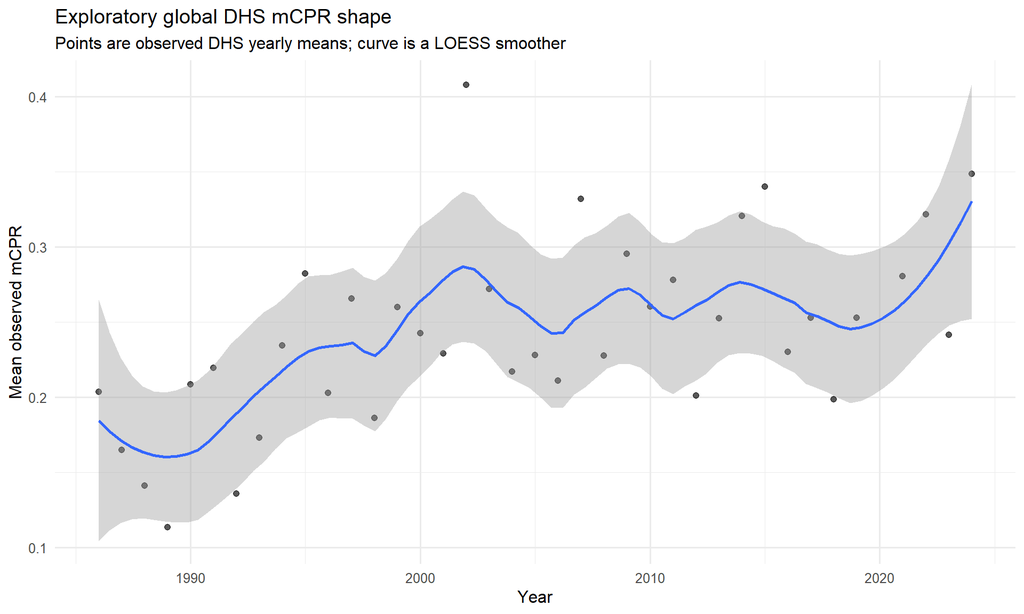

```r
# Build descriptive yearly global means and a smooth trajectory for visual diagnostics.
global_obs <- mcpr_logistic_data %>%
  group_by(year) %>%
  summarise(
    mean_mcpr = mean(mCPR, na.rm = TRUE),
    .groups = "drop"
  ) %>%
  arrange(year)

global_shape <- global_obs %>%
  mutate(
    mean_mcpr_smooth = as.numeric(stats::predict(
      loess(mean_mcpr ~ year, data = global_obs, span = 0.35),
      newdata = year
    )),
    implied_growth = (lead(mean_mcpr_smooth) - lag(mean_mcpr_smooth)) / (lead(year) - lag(year))
  )

ggplot(global_obs, aes(x = year, y = mean_mcpr)) +
  geom_point(alpha = 0.65, size = 1.8) +
  geom_smooth(method = "loess", span = 0.35, se = TRUE, linewidth = 1) +
  theme_minimal(base_size = 12) +
  labs(
    title = "Exploratory global DHS mCPR shape",
    subtitle = "Points are observed DHS yearly means; curve is a LOESS smoother",
    x = "Year",
    y = "Mean observed mCPR"
  )
```

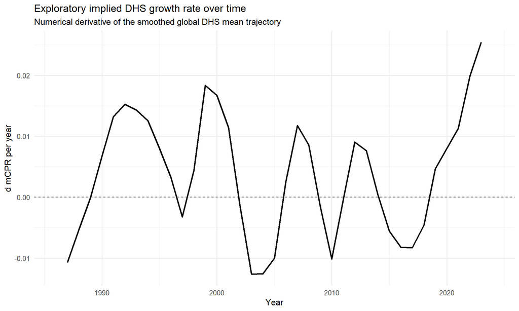

```r
ggplot(global_shape, aes(x = year, y = implied_growth)) +
  geom_hline(yintercept = 0, linetype = "dashed", alpha = 0.6) +
  geom_line(linewidth = 1) +
  theme_minimal(base_size = 12) +
  labs(
    title = "Exploratory implied DHS growth rate over time",
    subtitle = "Numerical derivative of the smoothed global DHS mean trajectory",
    x = "Year",
    y = "d mCPR per year"
  )
```

## 4.1 Exploratory country-level raw trajectories

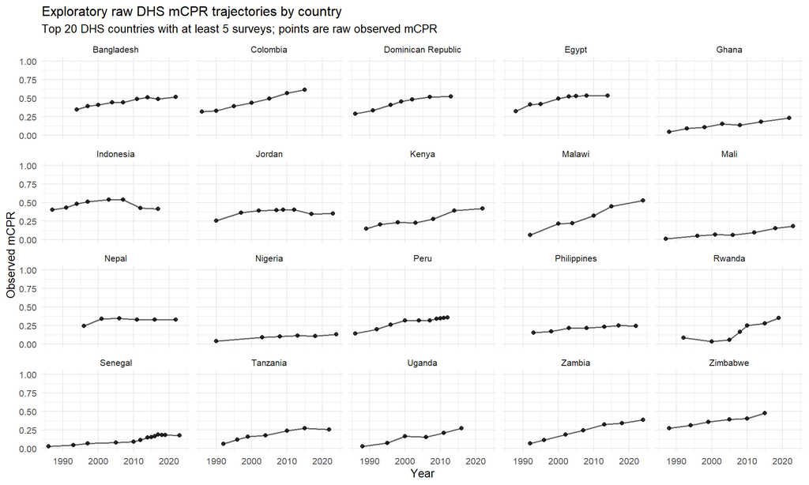

```r
# Select DHS countries with at least 5 surveys, then visualize the 20 deepest panels.
explore_countries <- mcpr_logistic_data %>%
  group_by(country) %>%
  summarise(n_surveys = n(), .groups = "drop") %>%
  filter(n_surveys >= 5) %>%
  arrange(desc(n_surveys), country) %>%
  slice_head(n = 20) %>%
  pull(country)

country_raw <- mcpr_logistic_data %>%
  filter(country %in% explore_countries) %>%
  arrange(country, year)

ggplot(country_raw, aes(x = year, y = mCPR, group = country)) +
  geom_line(alpha = 0.6, linewidth = 0.7) +
  geom_point(alpha = 0.8, size = 1.4) +
  facet_wrap(~ country, ncol = 5) +
  coord_cartesian(ylim = c(0, 1)) +
  theme_minimal(base_size = 10) +
  labs(
    title = "Exploratory raw DHS mCPR trajectories by country",
    subtitle = "Top 20 DHS countries with at least 5 surveys; points are raw observed mCPR",
    x = "Year",
    y = "Observed mCPR"
  )
```

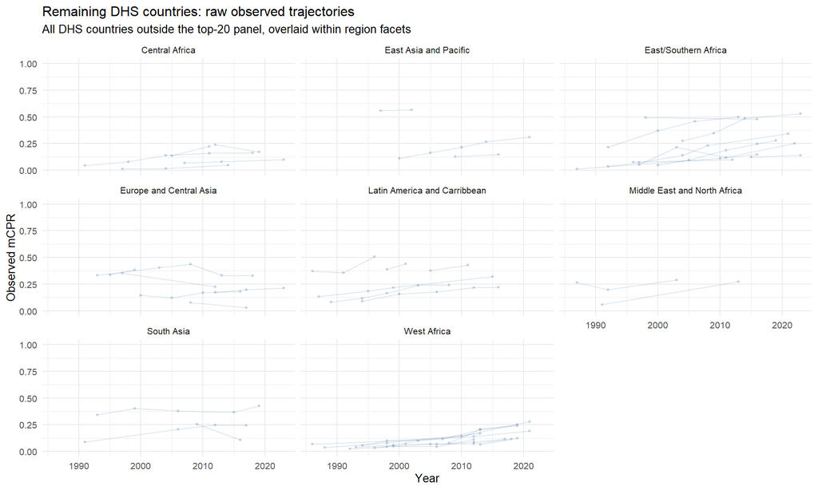

```r
# Show the remaining DHS countries in a compact regional view so all countries are visible.
remaining_country_raw <- mcpr_logistic_data %>%
  filter(!country %in% explore_countries) %>%
  arrange(region, country, year)

if (nrow(remaining_country_raw) > 0) {
  ggplot(remaining_country_raw, aes(x = year, y = mCPR, group = country)) +
    geom_line(alpha = 0.18, linewidth = 0.45, color = "#4C78A8") +
    geom_point(alpha = 0.25, size = 0.7, color = "#4C78A8") +
    facet_wrap(~ region, ncol = 3) +
    coord_cartesian(ylim = c(0, 1)) +
    theme_minimal(base_size = 10) +
    labs(
      title = "Remaining DHS countries: raw observed trajectories",
      subtitle = "All DHS countries outside the top-20 panel, overlaid within region facets",
      x = "Year",
      y = "Observed mCPR"
    )
}
```

# 5 Optional: DHS Data-Informed Ceiling Checks (not used as a predictor)

In DHS-based logistic curves, the ceiling $K_i$ can be hard to pin down if a country has few surveys or never reaches a plateau. A quick per-country nonlinear fit can give a **rough sense** of plausible ceilings.

**Important:** In the final model, we use **full hierarchical ceilings** (no anchoring predictor).  
So the estimates here are **diagnostic only** (to sanity-check the posterior later), not part of the model.

```r
# Fit simple DHS country-by-country logistic MLEs to inspect plausible K values (diagnostic only).
country_K_mle <- mcpr_logistic_data %>%
  group_by(country) %>%
  filter(n() >= 5) %>%
  group_modify(~ {
    dat <- .x
    fit <- tryCatch(
      nlsLM(
        mCPR ~ K / (1 + exp(-(year_center - t0) / s)),
        data  = dat,
        start = list(K = max(dat$mCPR) * 1.2, t0 = 0, s = 6),
        lower = c(K = 0.01, t0 = -60, s = 0.5),
        upper = c(K = 0.99, t0 =  60, s = 50),
        control = nls.lm.control(maxiter = 300)
      ),
      error = function(e) NULL
    )
    tibble(K_hat_mle = if (!is.null(fit)) coef(fit)[["K"]] else NA_real_)
  }) %>%
  ungroup()

summary(country_K_mle$K_hat_mle)
```

```
##    Min. 1st Qu.  Median    Mean 3rd Qu.    Max.    NA's
##  0.1251  0.3025  0.3657  0.4375  0.5520  0.9900       1
```

# 6 Optional: Per-country logistic diagnostics for speed $s$ from DHS data (not used in model)

To understand plausible transition speeds from the raw data, we fit separate nonlinear logistic curves by country and summarize the implied $s$ distribution.

Filter used for stability: a) at least 5 surveys in a country; b) observed mCPR range at least 0.08.

These fits are **diagnostic only** and are not used as priors mechanically; they help calibrate prior location/scale choices.

```r
# Fit country-level logistic MLEs and summarize s distribution (diagnostic only).
country_logistic_mle <- mcpr_logistic_data %>%
  group_by(country) %>%
  filter(n() >= 5, diff(range(mCPR, na.rm = TRUE)) >= 0.08) %>%
  group_modify(~ {
    dat <- .x
    fit <- tryCatch(
      nlsLM(
        mCPR ~ K / (1 + exp(-(year_center - t0) / s)),
        data  = dat,
        start = list(
          K  = min(0.95, max(dat$mCPR, na.rm = TRUE) * 1.25),
          t0 = median(dat$year_center, na.rm = TRUE),
          s  = 10
        ),
        lower = c(K = 0.03, t0 = -50, s = 1.5),
        upper = c(K = 0.99, t0 =  50, s = 35),
        control = nls.lm.control(maxiter = 300)
      ),
      error = function(e) NULL
    )

    if (is.null(fit)) {
      return(tibble(K_hat = NA_real_, t0_hat = NA_real_, s_hat = NA_real_, n_obs = nrow(dat)))
    }

    co <- coef(fit)
    tibble(
      K_hat  = unname(co[["K"]]),
      t0_hat = unname(co[["t0"]]),
      s_hat  = unname(co[["s"]]),
      n_obs  = nrow(dat)
    )
  }) %>%
  ungroup()

speed_diag <- country_logistic_mle %>%
  filter(is.finite(s_hat))

summary(speed_diag$s_hat)
```

```
##    Min. 1st Qu.  Median    Mean 3rd Qu.    Max.
##   1.500   5.877   8.164  11.399  13.761  35.000
```

```r
quantile(speed_diag$s_hat, probs = c(0.10, 0.25, 0.50, 0.75, 0.90), na.rm = TRUE)
```

```
##       10%       25%       50%       75%       90%
##  2.688750  5.876537  8.163795 13.760640 23.257788
```

```r
nrow(speed_diag)
```

```
## [1] 30
```

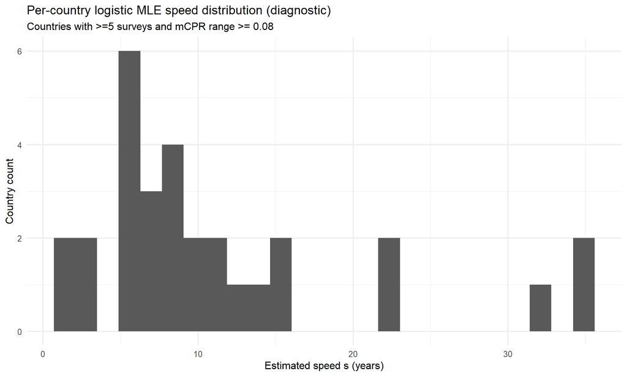

```r
ggplot(speed_diag, aes(x = s_hat)) +
  geom_histogram(bins = 25) +
  theme_minimal(base_size = 12) +
  labs(
    title = "Per-country logistic MLE speed distribution (diagnostic)",
    subtitle = "Countries with >=5 surveys and mCPR range >= 0.08",
    x = "Estimated speed s (years)",
    y = "Country count"
  )
```

# 7 WB-based prior calibration for $K$ and $s$ (1985+)

We use external World Bank modern-method mCPR data (`wb_surveys.xlsx`) to build empirical prior anchors for country ceilings ($K$), country speeds ($s$), and region-level timing structure.

Steps: a) subset to years 1985 and later; b) convert percentages to proportions (`value / 100`); c) count non-missing surveys by country; d) fit per-country bounded nonlinear least-squares logistic curves for countries with at least 5 non-missing survey years; e) classify each fitted country into program regions using country code; f) inspect regional parameter distributions ($K, t_0, s$) to inform prior centering and spread; g) calibrate region-level prior centers and spreads for $K$, $s$, and $t_0$, then transform internally where needed.

Before the Bayesian model, we fit a simple logistic S-curve separately to each WB country series as a pragmatic calibration step. The goal is not to treat these country fits as the final model; it is to get reasonable empirical ranges for the three core quantities: a) $K$, the long-run ceiling; b) $t_0$, the inflection year (fastest growth point); c) $s$, the speed parameter in years.

The starting values and bounds in `nlsLM(...)` were chosen to keep the optimizer in a plausible part of the parameter space: a) `K` starts at `1.2 x` the observed maximum, capped at `0.95`, because the ceiling should usually be somewhat above the highest observed value but still below the impossible boundary of 1. b) `t0` starts at the median observed year (on the centered year scale), which is a neutral midpoint when we do not know whether the country is early or late in transition. c) `s` starts at `10`, which is a moderate transition speed and gives the optimizer a stable default rather than an unrealistically steep or flat initial curve. d) `K` is bounded to `[0.02, 0.99]` to avoid impossible or boundary-hugging ceilings. e) `t0` is bounded to `[-60, 60]` on the centered scale, which corresponds to calendar years 1940 to 2060. This is intentionally wider than the observed window because the inferred inflection year can fall before or after the survey years. f) `s` is bounded to `[0.5, 50]` years to rule out near-vertical jumps and essentially flat curves that are not useful for prior calibration. g) `maxiter = 400` gives the nonlinear solver enough room to converge on difficult series without letting a single country run indefinitely.

```r
# Read WB extract (wide format: one row per country and one column per year).
wb_raw <- readxl::read_excel("wb_surveys.xlsx", sheet = 1, skip = 3)

# Explicit WB country-code mapping keeps prior calibration restricted to country series
# and standardizes French workbook labels into English names used in this report.
wb_region_lookup <- bind_rows(
  tibble::tibble(
    `Country Code` = c("AUS", "KHM", "CHN", "PRK", "IDN", "JPN", "LAO", "MYS", "MNG", "MMR", "PHL", "THA", "TLS", "VNM"),
    wb_region = "East Asia and Pacific"
  ),
  tibble::tibble(
    `Country Code` = c("ALB", "ARM", "DEU", "ESP", "EST", "FIN", "FRA", "GEO", "KAZ", "KGZ", "MDA", "RUS", "SRB", "TJK", "TUR", "GBR"),
    wb_region = "Europe and Central Asia"
  ),
  tibble::tibble(
    `Country Code` = c("BOL", "COL", "CRI", "CUB", "DOM", "ECU", "GTM", "GUY", "HTI", "HND", "MEX", "NIC", "PRY", "PER", "TTO"),
    wb_region = "Latin America and Carribbean"
  ),
  tibble::tibble(
    `Country Code` = c("DZA", "EGY", "IRN", "IRQ", "JOR", "KWT", "MAR", "OMN", "PSE", "YEM"),
    wb_region = "Middle East and North Africa"
  ),
  tibble::tibble(
    `Country Code` = c("AFG", "BGD", "IND", "MDV", "NPL", "PAK", "LKA"),
    wb_region = "South Asia"
  ),
  tibble::tibble(
    `Country Code` = c("BEN", "BFA", "CIV", "GMB", "GHA", "GIN", "GNB", "LBR", "MLI", "MRT", "NER", "NGA", "SEN", "SLE", "TGO"),
    wb_region = "West Africa"
  ),
  tibble::tibble(
    `Country Code` = c("CAF", "CMR", "TCD", "COD", "COG", "GAB", "STP"),
    wb_region = "Central Africa"
  ),
  tibble::tibble(
    `Country Code` = c("AGO", "BDI", "COM", "ETH", "KEN", "LSO", "MDG", "MWI", "MOZ", "NAM", "RWA", "SDN", "SWZ", "TZA", "UGA", "ZAF", "ZMB", "ZWE"),
    wb_region = "East/Southern Africa"
  )
)

wb_country_name_lookup <- tibble::tribble(
  ~`Country Code`, ~country_name_english,
  "AFG", "Afghanistan",
  "AGO", "Angola",
  "ALB", "Albania",
  "ARM", "Armenia",
  "AUS", "Australia",
  "BDI", "Burundi",
  "BEN", "Benin",
  "BFA", "Burkina Faso",
  "BGD", "Bangladesh",
  "BOL", "Bolivia",
  "CAF", "Central African Republic",
  "CHN", "China",
  "CIV", "Cote d'Ivoire",
  "CMR", "Cameroon",
  "COG", "Congo, Rep.",
  "COD", "Congo, Dem. Rep.",
  "COL", "Colombia",
  "COM", "Comoros",
  "CRI", "Costa Rica",
  "CUB", "Cuba",
  "DEU", "Germany",
  "DOM", "Dominican Republic",
  "DZA", "Algeria",
  "ECU", "Ecuador",
  "EGY", "Egypt, Arab Rep.",
  "ESP", "Spain",
  "EST", "Estonia",
  "ETH", "Ethiopia",
  "FIN", "Finland",
  "FRA", "France",
  "GBR", "United Kingdom",
  "GEO", "Georgia",
  "GHA", "Ghana",
  "GIN", "Guinea",
  "GMB", "Gambia, The",
  "GNB", "Guinea-Bissau",
  "GTM", "Guatemala",
  "GUY", "Guyana",
  "HTI", "Haiti",
  "HND", "Honduras",
  "IDN", "Indonesia",
  "IND", "India",
  "IRN", "Iran, Islamic Rep.",
  "IRQ", "Iraq",
  "JOR", "Jordan",
  "JPN", "Japan",
  "KAZ", "Kazakhstan",
  "KEN", "Kenya",
  "KGZ", "Kyrgyz Republic",
  "KHM", "Cambodia",
  "KOR", "Korea, Rep.",
  "KWT", "Kuwait",
  "LAO", "Lao PDR",
  "LBR", "Liberia",
  "LSO", "Lesotho",
  "LKA", "Sri Lanka",
  "MAR", "Morocco",
  "MDA", "Moldova",
  "MDG", "Madagascar",
  "MDV", "Maldives",
  "MEX", "Mexico",
  "MLI", "Mali",
  "MMR", "Myanmar",
  "MNG", "Mongolia",
  "MOZ", "Mozambique",
  "MRT", "Mauritania",
  "MWI", "Malawi",
  "MYS", "Malaysia",
  "NAM", "Namibia",
  "NER", "Niger",
  "NGA", "Nigeria",
  "NIC", "Nicaragua",
  "NPL", "Nepal",
  "OMN", "Oman",
  "PAK", "Pakistan",
  "PER", "Peru",
  "PHL", "Philippines",
  "PRK", "Korea, Dem. People's Rep.",
  "PRY", "Paraguay",
  "PSE", "West Bank and Gaza",
  "RUS", "Russian Federation",
  "RWA", "Rwanda",
  "SEN", "Senegal",
  "SLE", "Sierra Leone",
  "SRB", "Serbia",
  "SSD", "South Sudan",
  "STP", "Sao Tome and Principe",
  "SDN", "Sudan",
  "SWZ", "Eswatini",
  "TCD", "Chad",
  "THA", "Thailand",
  "TJK", "Tajikistan",
  "TIM", "Timor-Leste",
  "TLS", "Timor-Leste",
  "TGO", "Togo",
  "TTO", "Trinidad and Tobago",
  "TUR", "Turkey",
  "TZA", "Tanzania",
  "UGA", "Uganda",
  "VNM", "Vietnam",
  "YEM", "Yemen, Rep.",
  "ZAF", "South Africa",
  "ZMB", "Zambia",
  "ZWE", "Zimbabwe"
)

wb_region_levels <- region_label_lookup$region

# Identify year columns like 1960, 1961, ...
year_cols <- names(wb_raw)[grepl("^\\d{4}$", names(wb_raw))]

# Reshape to long format, keep years >= 1985, and convert percentages to proportions.
wb_long <- wb_raw %>%
  select(`Country Name`, `Country Code`, `Indicator Name`, `Indicator Code`, all_of(year_cols)) %>%
  tidyr::pivot_longer(
    cols = all_of(year_cols),
    names_to = "year",
    values_to = "mcpr_pct"
  ) %>%
  mutate(
    year = as.integer(year),
    mcpr_pct = as.numeric(mcpr_pct),
    mcpr_prop = mcpr_pct / 100
  ) %>%
  left_join(wb_country_name_lookup, by = "Country Code") %>%
  mutate(
    `Country Name` = dplyr::coalesce(country_name_english, `Country Name`)
  ) %>%
  filter(
    year >= 1985,
    !is.na(`Country Name`),
    !is.na(`Country Code`),
    !is.na(mcpr_prop),
    mcpr_prop >= 0, mcpr_prop <= 1
  ) %>%
  select(-country_name_english)

# Restrict calibration to explicitly mapped country series used in the eight analytic regions.
wb_long_countries <- wb_long %>%
  left_join(wb_region_lookup, by = "Country Code") %>%
  filter(!is.na(wb_region)) %>%
  mutate(
    wb_region = factor(wb_region, levels = wb_region_levels)
  )

# Validation check: how many non-missing WB survey years exist by country.
wb_survey_counts <- wb_long_countries %>%
  group_by(`Country Name`, `Country Code`) %>%
  summarise(
    n_surveys = n_distinct(year),
    first_year = min(year, na.rm = TRUE),
    last_year = max(year, na.rm = TRUE),
    .groups = "drop"
  ) %>%
  arrange(desc(n_surveys), `Country Name`)

n_countries_total_wb <- nrow(wb_survey_counts)
n_countries_5plus_wb <- sum(wb_survey_counts$n_surveys >= 5)

cat("WB countries with >=1 non-missing survey year (1985+):", n_countries_total_wb, "\n")
```

```
## WB countries with >=1 non-missing survey year (1985+): 102
```

```r
cat("WB countries with >=5 non-missing survey years (1985+):", n_countries_5plus_wb, "\n")
```

```
## WB countries with >=5 non-missing survey years (1985+): 96
```

```r
# Show a quick top-20 table so WB calibration coverage can be inspected in the report.
knitr::kable(
  wb_survey_counts %>% slice_head(n = 20),
  caption = "WB validation check: top 20 mapped countries by number of non-missing surveys (1985+)"
)
```

WB validation check: top 20 mapped countries by number of non-missing surveys (1985+)

| Country Name | Country Code | n_surveys | first_year | last_year |
| --- | --- | --- | --- | --- |
| Indonesia | IDN | 31 | 1985 | 2023 |
| Vietnam | VNM | 23 | 1988 | 2021 |
| Peru | PER | 21 | 1986 | 2023 |
| Philippines | PHL | 18 | 1993 | 2022 |
| Bangladesh | BGD | 16 | 1986 | 2022 |
| Ghana | GHA | 14 | 1988 | 2022 |
| Kenya | KEN | 14 | 1989 | 2022 |
| Senegal | SEN | 14 | 1986 | 2023 |
| Uganda | UGA | 14 | 1989 | 2022 |
| Burkina Faso | BFA | 13 | 1993 | 2022 |
| Ethiopia | ETH | 13 | 1990 | 2021 |
| Japan | JPN | 13 | 1986 | 2021 |
| Dominican Republic | DOM | 12 | 1986 | 2019 |
| Nepal | NPL | 12 | 1986 | 2022 |
| Nigeria | NGA | 12 | 1990 | 2021 |
| Pakistan | PAK | 12 | 1985 | 2018 |
| Thailand | THA | 12 | 1987 | 2022 |
| United Kingdom | GBR | 12 | 1986 | 2012 |
| Egypt, Arab Rep. | EGY | 11 | 1988 | 2014 |
| Mexico | MEX | 11 | 1987 | 2023 |

```r
# List the WB calibration countries included in each planning region.
wb_region_country_membership <- wb_long_countries %>%
  distinct(wb_region, `Country Name`) %>%
  arrange(wb_region, `Country Name`) %>%
  group_by(wb_region) %>%
  summarise(
    countries = paste(`Country Name`, collapse = ", "),
    .groups = "drop"
  )

knitr::kable(
  wb_region_country_membership,
  caption = "WB prior-calibration regions and mapped countries"
)
```

WB prior-calibration regions and mapped countries

| wb_region | countries |
| --- | --- |
| Central Africa | Cameroon, Central African Republic, Chad, Congo, Dem. Rep., Congo, Rep., Gabon, Sao Tome and Principe |
| East Asia and Pacific | Australia, Cambodia, China, Indonesia, Japan, Korea, Dem. People’s Rep., Lao PDR, Malaysia, Mongolia, Myanmar, Philippines, Thailand, Timor-Leste, Vietnam |
| East/Southern Africa | Angola, Burundi, Comoros, Eswatini, Ethiopia, Kenya, Lesotho, Madagascar, Malawi, Mozambique, Namibia, Rwanda, South Africa, Sudan, Tanzania, Uganda, Zambia, Zimbabwe |
| Europe and Central Asia | Albania, Armenia, Estonia, Finland, France, Georgia, Germany, Kazakhstan, Kyrgyz Republic, Moldova, Russian Federation, Serbia, Spain, Tajikistan, Turkey, United Kingdom |
| Latin America and Carribbean | Bolivia, Colombia, Costa Rica, Cuba, Dominican Republic, Ecuador, Guatemala, Guyana, Haiti, Honduras, Mexico, Nicaragua, Paraguay, Peru, Trinidad and Tobago |
| Middle East and North Africa | Algeria, Egypt, Arab Rep., Iran, Islamic Rep., Iraq, Jordan, Kuwait, Morocco, Oman, West Bank and Gaza, Yemen, Rep. |
| South Asia | Afghanistan, Bangladesh, India, Maldives, Nepal, Pakistan, Sri Lanka |
| West Africa | Benin, Burkina Faso, Cote d’Ivoire, Gambia, The, Ghana, Guinea, Guinea-Bissau, Liberia, Mali, Mauritania, Niger, Nigeria, Senegal, Sierra Leone, Togo |

```r
# Fit country-level bounded nonlinear least-squares logistic curves
# (K, t0, and s all estimated freely) for countries with >=5 surveys.
wb_country_mle <- wb_long_countries %>%
  # Keep wb_region as a grouping key so the fitted country-level parameters
  # retain their region assignment for downstream regional summaries.
  group_by(`Country Name`, `Country Code`, wb_region) %>%
  filter(n_distinct(year) >= 5) %>%
  group_modify(~{
    dat <- .x %>%
      arrange(year) %>%
      mutate(year_center = year - 2000)

    fit <- tryCatch(
      nlsLM(
        mcpr_prop ~ K / (1 + exp(-(year_center - t0) / s)),
        data = dat,
        start = list(
          # Start K slightly above the observed maximum, start t0 at the time midpoint,
          # and start s at a moderate 10-year transition speed.
          K = min(0.95, max(dat$mcpr_prop, na.rm = TRUE) * 1.20),
          t0 = stats::median(dat$year_center, na.rm = TRUE),
          s = 10
        ),
        # Bounds keep the fit in a plausible range while allowing inflection timing
        # to fall outside the observed survey window if the data imply that.
        lower = c(K = 0.02, t0 = -60, s = 0.5),
        upper = c(K = 0.99, t0 =  60, s = 50),
        control = nls.lm.control(maxiter = 400)
      ),
      error = function(e) NULL
    )

    if (is.null(fit)) {
      return(tibble(K_hat = NA_real_, t0_hat = NA_real_, s_hat = NA_real_, n_obs = nrow(dat)))
    }

    co <- coef(fit)
    tibble(
      K_hat = unname(co[["K"]]),
      t0_hat = unname(co[["t0"]]),
      s_hat = unname(co[["s"]]),
      n_obs = nrow(dat)
    )
  }) %>%
  ungroup() %>%
  filter(is.finite(K_hat), K_hat > 0, K_hat < 1)

# Surface any codes that were expected but not translated, so the mapping stays auditable.
wb_untranslated <- wb_long_countries %>%
  distinct(`Country Code`, `Country Name`) %>%
  anti_join(wb_country_name_lookup %>% select(`Country Code`), by = "Country Code") %>%
  arrange(`Country Code`)

if (nrow(wb_untranslated) > 0) {
  knitr::kable(
    wb_untranslated,
    caption = "WB mapped country codes still using workbook names"
  )
}
```

WB mapped country codes still using workbook names

| Country Code | Country Name |
| --- | --- |
| GAB | Gabon |

```r
# Remove clear boundary-hit ceilings (typically weakly identified at optimizer cap)
wb_k_for_prior <- wb_country_mle %>%
  filter(K_hat <= 0.98, K_hat >= 0.02)

# Keep the full fitted K distribution for visualization diagnostics.
# This aligns plotting with the "WB per-country MLE ceiling distribution (K)" figure.
wb_k_for_plot <- wb_country_mle %>%
  filter(is.finite(K_hat), K_hat > 0, K_hat < 1)

# Historical support for the inflection year. `t0` is peak growth, not method
# invention, so we allow some lead time after the introduction of modern methods
# but disallow implausibly early inflection years.
t0_year_min <- 1966
t0_year_max <- 2035
t0_lower <- t0_year_min - 2000
t0_upper <- t0_year_max - 2000
t0_span <- t0_upper - t0_lower
t0_bound_eps <- 0.5

# Also keep bounded-but-free estimates for t0 and s to summarize all parameter distributions.
wb_t0_for_prior <- wb_country_mle %>%
  filter(is.finite(t0_hat), t0_hat >= t0_lower, t0_hat <= t0_upper)

wb_s_for_prior <- wb_country_mle %>%
  filter(is.finite(s_hat), s_hat > 0.5)

# Summaries for all three parameters from WB country-level MLEs.
summary(wb_country_mle$K_hat)
```

```
##    Min. 1st Qu.  Median    Mean 3rd Qu.    Max.
## 0.06493 0.41431 0.62607 0.63020 0.99000 0.99000
```

```r
quantile(wb_country_mle$K_hat, probs = c(0.10, 0.25, 0.50, 0.75, 0.90), na.rm = TRUE)
```

```
##       10%       25%       50%       75%       90%
## 0.2555883 0.4143086 0.6260738 0.9900000 0.9900000
```

```r
nrow(wb_country_mle)
```

```
## [1] 96
```

```r
nrow(wb_k_for_prior)
```

```
## [1] 69
```

```r
summary(wb_t0_for_prior$t0_hat)
```

```
##    Min. 1st Qu.  Median    Mean 3rd Qu.    Max.
## -33.960 -11.369  -2.690  -2.512   5.603  26.867
```

```r
quantile(wb_t0_for_prior$t0_hat, probs = c(0.10, 0.25, 0.50, 0.75, 0.90), na.rm = TRUE)
```

```
##        10%        25%        50%        75%        90%
## -16.352801 -11.369011  -2.690268   5.603440  12.867786
```

```r
summary(wb_s_for_prior$s_hat)
```

```
##    Min. 1st Qu.  Median    Mean 3rd Qu.    Max.
##  0.5058  6.6853 10.9299 20.1887 33.3762 50.0000
```

```r
quantile(wb_s_for_prior$s_hat, probs = c(0.10, 0.25, 0.50, 0.75, 0.90), na.rm = TRUE)
```

```
##       10%       25%       50%       75%       90%
##  3.760679  6.685285 10.929953 33.376218 50.000000
```

```r
# Region-level K summaries are the key diagnostic for K prior calibration.
wb_region_k_summary <- wb_country_mle %>%
  group_by(wb_region) %>%
  summarise(
    n_countries = n(),
    mean_K = mean(K_hat, na.rm = TRUE),
    median_K = median(K_hat, na.rm = TRUE),
    p25_K = quantile(K_hat, 0.25, na.rm = TRUE),
    p75_K = quantile(K_hat, 0.75, na.rm = TRUE),
    .groups = "drop"
  ) %>%
  arrange(wb_region)

knitr::kable(
  wb_region_k_summary %>%
    mutate(across(where(is.numeric), ~ round(.x, 3))),
  caption = "WB MLE K distribution by region (used to sanity-check K prior calibration)"
)
```

WB MLE K distribution by region (used to sanity-check K prior calibration)

| wb_region | n_countries | mean_K | median_K | p25_K | p75_K |
| --- | --- | --- | --- | --- | --- |
| Central Africa | 5 | 0.469 | 0.181 | 0.120 | 0.990 |
| East Asia and Pacific | 14 | 0.646 | 0.631 | 0.482 | 0.794 |
| East/Southern Africa | 15 | 0.589 | 0.623 | 0.435 | 0.704 |
| Europe and Central Asia | 16 | 0.738 | 0.990 | 0.505 | 0.990 |
| Latin America and Carribbean | 15 | 0.752 | 0.790 | 0.573 | 0.990 |
| Middle East and North Africa | 10 | 0.496 | 0.478 | 0.411 | 0.586 |
| South Asia | 7 | 0.478 | 0.456 | 0.290 | 0.567 |
| West Africa | 14 | 0.634 | 0.668 | 0.299 | 0.990 |

```r
# Inspect raw WB mCPR values by region (not fitted coefficients) to contextualize prior anchors.
# This uses all non-missing 1985+ WB observations in proportion scale.
wb_raw_region <- wb_long_countries

wb_raw_region_summary <- wb_raw_region %>%
  group_by(wb_region) %>%
  summarise(
    n_observations = n(),
    n_countries = n_distinct(`Country Code`),
    mean_mcpr = mean(mcpr_prop, na.rm = TRUE),
    median_mcpr = median(mcpr_prop, na.rm = TRUE),
    p25_mcpr = quantile(mcpr_prop, 0.25, na.rm = TRUE),
    p75_mcpr = quantile(mcpr_prop, 0.75, na.rm = TRUE),
    .groups = "drop"
  ) %>%
  arrange(wb_region)

knitr::kable(
  wb_raw_region_summary %>%
    mutate(across(where(is.numeric), ~ round(.x, 3))),
  caption = "Raw WB mCPR distribution by region (1985+, proportion scale)"
)
```

Raw WB mCPR distribution by region (1985+, proportion scale)

| wb_region | n_observations | n_countries | mean_mcpr | median_mcpr | p25_mcpr | p75_mcpr |
| --- | --- | --- | --- | --- | --- | --- |
| Central Africa | 35 | 7 | 0.141 | 0.118 | 0.067 | 0.180 |
| East Asia and Pacific | 158 | 14 | 0.502 | 0.527 | 0.362 | 0.623 |
| East/Southern Africa | 143 | 18 | 0.314 | 0.300 | 0.136 | 0.454 |
| Europe and Central Asia | 96 | 16 | 0.487 | 0.488 | 0.315 | 0.675 |
| Latin America and Carribbean | 122 | 15 | 0.507 | 0.528 | 0.364 | 0.660 |
| Middle East and North Africa | 70 | 10 | 0.402 | 0.422 | 0.320 | 0.516 |
| South Asia | 68 | 7 | 0.337 | 0.366 | 0.197 | 0.461 |
| West Africa | 131 | 15 | 0.133 | 0.122 | 0.078 | 0.182 |

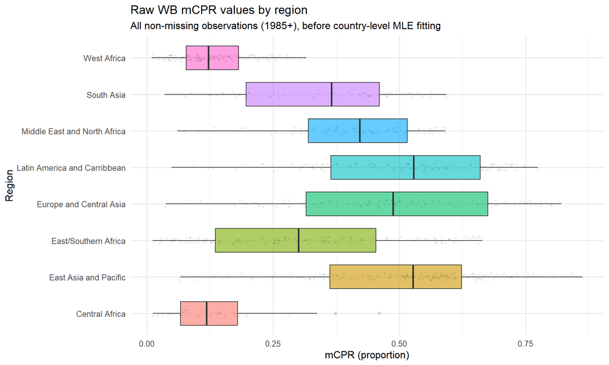

```r
ggplot(
  wb_raw_region,
  aes(x = factor(wb_region, levels = wb_region_levels), y = mcpr_prop, fill = wb_region)
) +
  geom_boxplot(alpha = 0.60, outlier.alpha = 0.12, width = 0.65) +
  geom_jitter(width = 0.10, alpha = 0.07, size = 0.8, color = "black") +
  coord_flip() +
  theme_minimal(base_size = 12) +
  theme(legend.position = "none") +
  labs(
    title = "Raw WB mCPR values by region",
    subtitle = "All non-missing observations (1985+), before country-level MLE fitting",
    x = "Region",
    y = "mCPR (proportion)"
  )
```

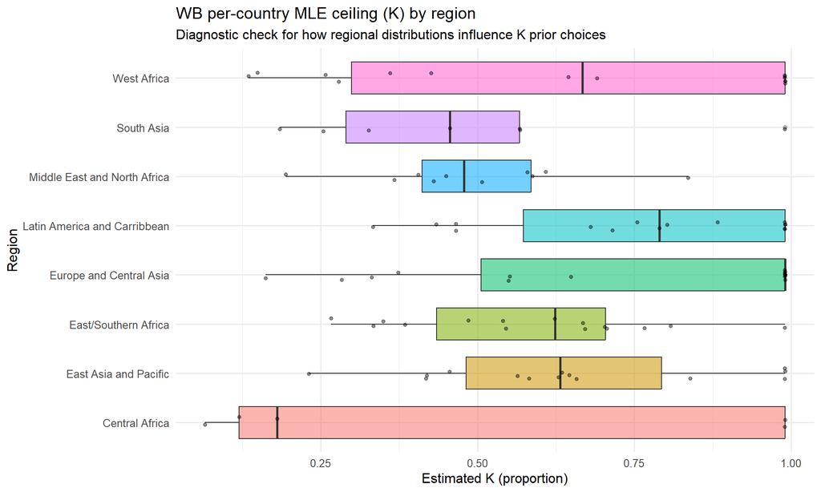

```r
ggplot(
  wb_country_mle,
  aes(x = factor(wb_region, levels = wb_region_levels), y = K_hat, fill = wb_region)
) +
  geom_boxplot(alpha = 0.55, outlier.alpha = 0.35, width = 0.65) +
  geom_jitter(width = 0.12, alpha = 0.45, size = 1.3, color = "black") +
  coord_flip() +
  theme_minimal(base_size = 12) +
  theme(legend.position = "none") +
  labs(
    title = "WB per-country MLE ceiling (K) by region",
    subtitle = "Diagnostic check for how regional distributions influence K prior choices",
    x = "Region",
    y = "Estimated K (proportion)"
  )
```

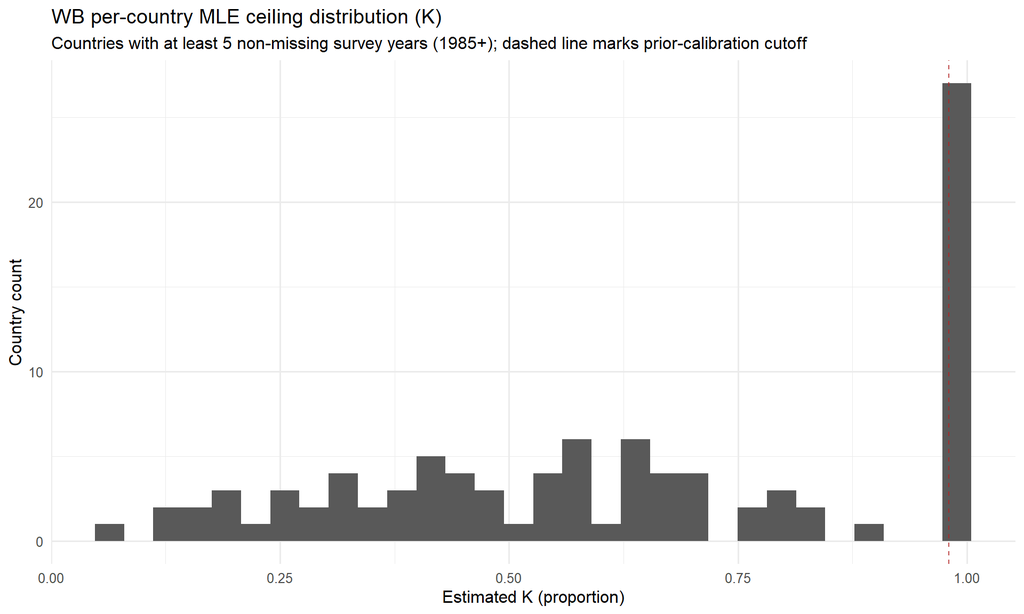

```r
ggplot(wb_country_mle, aes(x = K_hat)) +
  geom_histogram(bins = 30) +
  geom_vline(xintercept = 0.98, linetype = "dashed", color = "firebrick", alpha = 0.8) +
  theme_minimal(base_size = 12) +
  labs(
    title = "WB per-country MLE ceiling distribution (K)",
    subtitle = "Countries with at least 5 non-missing survey years (1985+); dashed line marks prior-calibration cutoff",
    x = "Estimated K (proportion)",
    y = "Country count"
  )
```

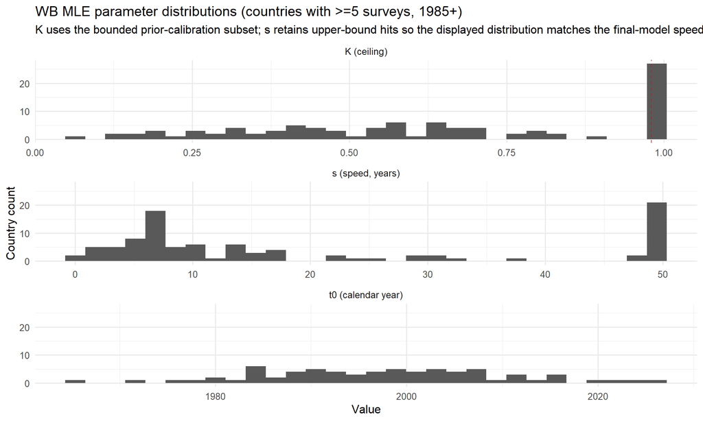

```r
# Visualize all MLE parameter distributions (K, t0 in calendar year, and s in years).
wb_param_long <- bind_rows(
  # Use full K MLEs so this panel is consistent with the WB per-country K plot above.
  wb_k_for_plot %>%
    transmute(parameter = "K (ceiling)", value = K_hat),
  wb_t0_for_prior %>%
    transmute(parameter = "t0 (calendar year)", value = 2000 + t0_hat),
  # Keep upper-bound s estimates here because the FPET speed priors are centered on
  # the same raw WB MLE distribution shown in the report.
  wb_s_for_prior %>%
    transmute(parameter = "s (speed, years)", value = s_hat)
)

ggplot(wb_param_long, aes(x = value)) +
  geom_histogram(bins = 30) +
  geom_vline(
    data = tibble(parameter = "K (ceiling)", value = 0.98),
    aes(xintercept = value),
    inherit.aes = FALSE,
    linetype = "dashed",
    color = "firebrick",
    alpha = 0.8
  ) +
  facet_wrap(~ parameter, scales = "free_x", ncol = 1) +
  theme_minimal(base_size = 12) +
  labs(
    title = "WB MLE parameter distributions (countries with >=5 surveys, 1985+)",
    subtitle = "K uses the bounded prior-calibration subset; s retains upper-bound hits so the displayed distribution matches the final-model speed calibration",
    x = "Value",
    y = "Country count"
  )
```

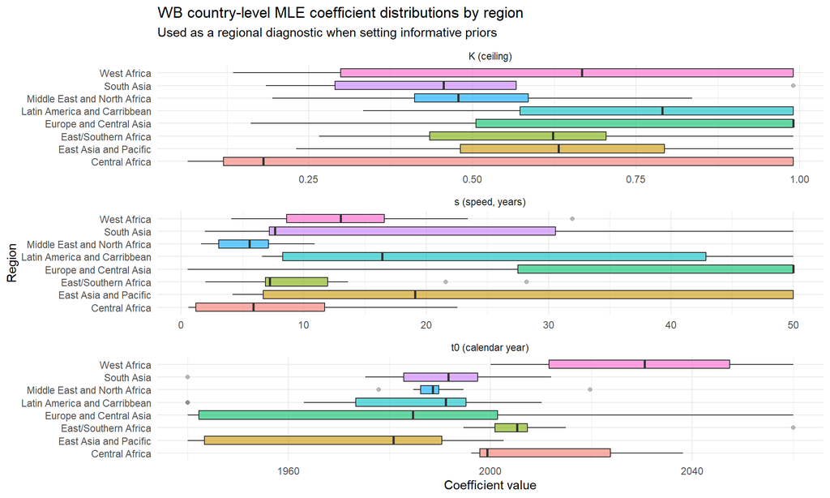

```r
# Companion regional view across all fitted coefficients (K, t0, s).
wb_param_region_long <- wb_country_mle %>%
  transmute(
    wb_region,
    `K (ceiling)` = K_hat,
    `t0 (calendar year)` = 2000 + t0_hat,
    `s (speed, years)` = s_hat
  ) %>%
  pivot_longer(
    cols = c(`K (ceiling)`, `t0 (calendar year)`, `s (speed, years)`),
    names_to = "parameter",
    values_to = "value"
  )

ggplot(
  wb_param_region_long,
  aes(x = factor(wb_region, levels = wb_region_levels), y = value, fill = wb_region)
) +
  geom_boxplot(alpha = 0.6, outlier.alpha = 0.3, width = 0.65) +
  coord_flip() +
  facet_wrap(~parameter, scales = "free_x", ncol = 1) +
  theme_minimal(base_size = 11) +
  theme(legend.position = "none") +
  labs(
    title = "WB country-level MLE coefficient distributions by region",
    subtitle = "Used as a regional diagnostic when setting informative priors",
    x = "Region",
    y = "Coefficient value"
  )
```

```r
# Region-level K priors anchored to regional WB MLE summaries.
# Priors are displayed on the interpretable K scale, and internally transformed to logit(K).
wb_region_prior_inputs <- wb_country_mle %>%
  group_by(wb_region) %>%
  summarise(
    n_countries = n(),
    mean_K = mean(K_hat, na.rm = TRUE),
    median_K = median(K_hat, na.rm = TRUE),
    p25_K = quantile(K_hat, 0.25, na.rm = TRUE),
    p75_K = quantile(K_hat, 0.75, na.rm = TRUE),
    .groups = "drop"
  ) %>%
  left_join(
    region_label_lookup %>% rename(wb_region = region),
    by = "wb_region"
  ) %>%
  arrange(region_prior)

wb_region_prior_spec <- wb_region_prior_inputs %>%
  mutate(
    prior_center_K = pmin(pmax(median_K, 0.01), 0.99),
    q25_logitK = qlogis(pmin(pmax(p25_K, 0.01), 0.99)),
    q75_logitK = qlogis(pmin(pmax(p75_K, 0.01), 0.99)),
    # Robust SD from IQR on the logit(K) scale, with caps to avoid boundary-driven extremes.
    prior_sd_raw = (q75_logitK - q25_logitK) / 1.349,
    prior_sd = pmax(0.35, pmin(1.25, prior_sd_raw)),
    # Internal working prior mean on logit(K), derived from interpretable K center.
    prior_mean = qlogis(prior_center_K),
    # Implied K-scale uncertainty interval for interpretation.
    prior_lo95_K = plogis(prior_mean - 2 * prior_sd),
    prior_hi95_K = plogis(prior_mean + 2 * prior_sd),
    coef_name = paste0("region_prior", region_prior)
  ) %>%
  arrange(region_prior)

knitr::kable(
  wb_region_prior_spec %>%
    arrange(wb_region) %>%
    select(wb_region, region_prior, n_countries, prior_center_K, prior_lo95_K, prior_hi95_K, median_K, p25_K, p75_K) %>%
    mutate(across(where(is.numeric), ~ round(.x, 3))),
  caption = "Region-level K prior settings derived from WB regional MLE summaries"
)
```

Region-level K prior settings derived from WB regional MLE summaries

| wb_region | region_prior | n_countries | prior_center_K | prior_lo95_K | prior_hi95_K | median_K | p25_K | p75_K |
| --- | --- | --- | --- | --- | --- | --- | --- | --- |
| Central Africa | CAF | 5 | 0.181 | 0.018 | 0.729 | 0.181 | 0.120 | 0.990 |
| East Asia and Pacific | EAP | 14 | 0.631 | 0.173 | 0.934 | 0.631 | 0.482 | 0.794 |
| East/Southern Africa | ESA | 15 | 0.623 | 0.237 | 0.898 | 0.623 | 0.435 | 0.704 |
| Europe and Central Asia | ECA | 16 | 0.990 | 0.890 | 0.999 | 0.990 | 0.505 | 0.990 |
| Latin America and Carribbean | LAC | 15 | 0.790 | 0.236 | 0.979 | 0.790 | 0.573 | 0.990 |
| Middle East and North Africa | MENA | 10 | 0.478 | 0.244 | 0.722 | 0.478 | 0.411 | 0.586 |
| South Asia | SA | 7 | 0.456 | 0.129 | 0.825 | 0.456 | 0.290 | 0.567 |
| West Africa | WAF | 14 | 0.668 | 0.141 | 0.961 | 0.668 | 0.299 | 0.990 |

```r
# Region-level WB speed summaries from country-level MLE speed estimates.
# For the final model we fix s by region to the WB regional median, which removes
# the weakly identified K-vs-s tradeoff and substantially improves runtime.
wb_region_s_fixed <- wb_country_mle %>%
  filter(
    is.finite(s_hat),
    s_hat > 0.5
  ) %>%
  left_join(
    region_label_lookup %>% rename(wb_region = region),
    by = "wb_region"
  ) %>%
  filter(!is.na(region_prior)) %>%
  group_by(region_prior) %>%
  summarise(
    n_regionspeed = n(),
    n_eq50 = sum(abs(s_hat - 50) < 1e-8, na.rm = TRUE),
    prop_eq50 = mean(abs(s_hat - 50) < 1e-8, na.rm = TRUE),
    s_region_median_raw = median(s_hat, na.rm = TRUE),
    s_region_p25 = quantile(s_hat, 0.25, na.rm = TRUE),
    s_region_p75 = quantile(s_hat, 0.75, na.rm = TRUE),
    .groups = "drop"
  )

# Ensure all analytic regions have speed values; fallback to 8 years only if sparse/missing.
# The final model uses the raw WB regional median directly so the calibration table
# and the value entering the model remain identical.
speed_region_template <- tibble(region_prior = region_prior_levels)
wb_region_s_fixed <- speed_region_template %>%
  left_join(wb_region_s_fixed, by = "region_prior") %>%
  mutate(
    s_region_fixed = if_else(is.na(s_region_median_raw), 8, s_region_median_raw),
    s_region_p25 = if_else(is.na(s_region_p25), s_region_fixed, s_region_p25),
    s_region_p75 = if_else(is.na(s_region_p75), s_region_fixed, s_region_p75)
  ) %>%
  left_join(
    region_label_lookup %>% rename(wb_region = region),
    by = "region_prior"
  ) %>%
  arrange(wb_region)

if (any(
  !is.na(wb_region_s_fixed$s_region_median_raw) &
    abs(wb_region_s_fixed$s_region_fixed - wb_region_s_fixed$s_region_median_raw) > 1e-8
)) {
  stop("Region fixed speeds do not match the raw WB regional medians.")
}

knitr::kable(
  wb_region_s_fixed %>%
    select(wb_region, region_prior, n_regionspeed, n_eq50, prop_eq50, s_region_median_raw, s_region_fixed, s_region_p25, s_region_p75) %>%
    mutate(across(where(is.numeric), ~ round(.x, 3))),
  caption = "WB regional speed summaries used to center the FPET speed hierarchy"
)
```

WB regional speed summaries used to center the FPET speed hierarchy

| wb_region | region_prior | n_regionspeed | n_eq50 | prop_eq50 | s_region_median_raw | s_region_fixed | s_region_p25 | s_region_p75 |
| --- | --- | --- | --- | --- | --- | --- | --- | --- |
| Central Africa | CAF | 5 | 0 | 0.000 | 5.898 | 5.898 | 1.189 | 11.717 |
| East Asia and Pacific | EAP | 14 | 6 | 0.429 | 19.086 | 19.086 | 6.696 | 50.000 |
| East/Southern Africa | ESA | 15 | 0 | 0.000 | 7.232 | 7.232 | 6.863 | 11.952 |
| Europe and Central Asia | ECA | 16 | 11 | 0.688 | 50.000 | 50.000 | 27.493 | 50.000 |
| Latin America and Carribbean | LAC | 15 | 3 | 0.200 | 16.398 | 16.398 | 8.293 | 42.879 |
| Middle East and North Africa | MENA | 10 | 0 | 0.000 | 5.585 | 5.585 | 3.077 | 7.130 |
| South Asia | SA | 7 | 1 | 0.143 | 7.647 | 7.647 | 7.177 | 30.575 |
| West Africa | WAF | 14 | 0 | 0.000 | 13.007 | 13.007 | 8.594 | 16.579 |

```r
# Keep the WB regional speed center as a compatibility column used in some
# production-style comparison plots downstream.
mcpr_logistic_data <- mcpr_logistic_data %>%
  left_join(
    wb_region_s_fixed %>% select(region_prior, s_region_fixed),
    by = "region_prior"
  ) %>%
  mutate(
    region_prior = factor(as.character(region_prior), levels = region_prior_levels)
  )

if (any(is.na(mcpr_logistic_data$s_region_fixed))) {
  stop("Missing s_region_fixed for one or more country rows; check region mapping.")
}

# Optional calibration for t0 prior using WB MLE timing distribution.
t0_fallback_mean <- -2.5
t0_fallback_sd   <- 4

if (nrow(wb_t0_for_prior) >= 15) {
  t0_prior_mean <- stats::median(wb_t0_for_prior$t0_hat, na.rm = TRUE)
  t0_prior_sd <- stats::sd(wb_t0_for_prior$t0_hat, na.rm = TRUE)
  t0_prior_sd <- max(2.0, min(10.0, t0_prior_sd))
} else {
  t0_prior_mean <- t0_fallback_mean
  t0_prior_sd   <- t0_fallback_sd
}

t0_prior_mean <- pmax(t0_lower + t0_bound_eps, pmin(t0_upper - t0_bound_eps, t0_prior_mean))

# Region-level t0 priors: center/sd by WB regional MLE timing summaries.
# This gives each region its own inflection-year baseline while retaining
# country-level random effects around those regional baselines.
wb_region_t0_prior_spec <- wb_country_mle %>%
  filter(
    is.finite(t0_hat),
    t0_hat >= -60,
    t0_hat <= 60
  ) %>%
  left_join(
    region_label_lookup %>% rename(wb_region = region),
    by = "wb_region"
  ) %>%
  filter(!is.na(region_prior)) %>%
  group_by(region_prior) %>%
  summarise(
    n_region_t0 = n(),
    t0_region_median = median(t0_hat, na.rm = TRUE),
    t0_region_p25 = quantile(t0_hat, 0.25, na.rm = TRUE),
    t0_region_p75 = quantile(t0_hat, 0.75, na.rm = TRUE),
    .groups = "drop"
  )

t0_region_template <- tibble(region_prior = region_prior_levels)
wb_region_t0_prior_spec <- t0_region_template %>%
  left_join(wb_region_t0_prior_spec, by = "region_prior") %>%
  mutate(
    prior_center_t0 = if_else(is.na(t0_region_median), t0_prior_mean, t0_region_median),
    prior_center_t0 = pmax(t0_lower + t0_bound_eps, pmin(t0_upper - t0_bound_eps, prior_center_t0)),
    prior_q25_t0 = if_else(is.na(t0_region_p25), prior_center_t0 - t0_prior_sd, t0_region_p25),
    prior_q75_t0 = if_else(is.na(t0_region_p75), prior_center_t0 + t0_prior_sd, t0_region_p75),
    prior_q25_t0 = pmax(t0_lower + t0_bound_eps, pmin(prior_center_t0 - 0.10, prior_q25_t0)),
    prior_q75_t0 = pmin(t0_upper - t0_bound_eps, pmax(prior_center_t0 + 0.10, prior_q75_t0)),
    prior_center_frac = (prior_center_t0 - t0_lower) / t0_span,
    prior_q25_frac = (prior_q25_t0 - t0_lower) / t0_span,
    prior_q75_frac = (prior_q75_t0 - t0_lower) / t0_span,
    prior_center_t0_raw = qlogis(prior_center_frac),
    prior_sd_t0_raw = (qlogis(prior_q75_frac) - qlogis(prior_q25_frac)) / 1.349,
    prior_sd_t0_raw = if_else(is.finite(prior_sd_t0_raw), prior_sd_t0_raw, 1.25),
    prior_sd_t0_raw = pmax(0.35, pmin(2.50, prior_sd_t0_raw)),
    prior_center_year = 2000 + prior_center_t0,
    prior_lo95_year = 2000 + (t0_lower + t0_span * plogis(prior_center_t0_raw - 2 * prior_sd_t0_raw)),
    prior_hi95_year = 2000 + (t0_lower + t0_span * plogis(prior_center_t0_raw + 2 * prior_sd_t0_raw)),
    coef_name = paste0("region_prior", region_prior)
  ) %>%
  left_join(
    region_label_lookup %>% rename(wb_region = region),
    by = "region_prior"
  ) %>%
  arrange(wb_region)

knitr::kable(
  wb_region_t0_prior_spec %>%
    select(wb_region, region_prior, n_region_t0, prior_center_year, prior_lo95_year, prior_hi95_year) %>%
    mutate(across(where(is.numeric), ~ round(.x, 3))),
  caption = "Region-level bounded t0 prior settings derived from WB MLE timing summaries"
)
```

Region-level bounded t0 prior settings derived from WB MLE timing summaries

| wb_region | region_prior | n_region_t0 | prior_center_year | prior_lo95_year | prior_hi95_year |
| --- | --- | --- | --- | --- | --- |
| Central Africa | CAF | 5 | 1999.391 | 1970.244 | 2030.214 |
| East Asia and Pacific | EAP | 14 | 1980.787 | 1966.127 | 2033.337 |
| East/Southern Africa | ESA | 15 | 2005.253 | 1993.315 | 2016.133 |
| Europe and Central Asia | ECA | 16 | 1984.674 | 1966.172 | 2033.769 |
| Latin America and Carribbean | LAC | 15 | 1991.143 | 1968.602 | 2027.650 |
| Middle East and North Africa | MENA | 10 | 1988.579 | 1979.424 | 2000.143 |
| South Asia | SA | 7 | 1991.645 | 1974.641 | 2014.965 |
| West Africa | WAF | 14 | 2030.581 | 1972.186 | 2034.968 |

```r
cat("K MLE rows used for prior calibration:", nrow(wb_k_for_prior), "\n")
```

```
## K MLE rows used for prior calibration: 69
```

```r
cat("Region-level K priors configured for regions:", paste(sort(wb_region_prior_spec$region_prior), collapse = ", "), "\n")
```

```
## Region-level K priors configured for regions: CAF, EAP, ECA, ESA, LAC, MENA, SA, WAF
```

```r
cat("Region-level WB speed summaries configured for regions:", paste(sort(wb_region_s_fixed$region_prior), collapse = ", "), "\n")
```

```
## Region-level WB speed summaries configured for regions: CAF, EAP, ECA, ESA, LAC, MENA, SA, WAF
```

```r
cat("WB regional speed prior centers (years):\n")
```

```
## WB regional speed prior centers (years):
```

```r
print(
  wb_region_s_fixed %>%
    select(region_prior, s_region_fixed) %>%
    mutate(s_region_fixed = round(s_region_fixed, 3))
)
```

```
## # A tibble: 8 x 2
##   region_prior s_region_fixed
##   <chr>                 <dbl>
## 1 CAF                    5.90
## 2 EAP                   19.1
## 3 ESA                    7.23
## 4 ECA                   50
## 5 LAC                   16.4
## 6 MENA                   5.58
## 7 SA                     7.65
## 8 WAF                   13.0
```

```r
cat("t0 MLE rows used for prior calibration:", nrow(wb_t0_for_prior), "\n")
```

```
## t0 MLE rows used for prior calibration: 70
```

```r
cat("Bounded t0 support (calendar years):", t0_year_min, "to", t0_year_max, "\n")
```

```
## Bounded t0 support (calendar years): 1966 to 2035
```

```r
cat("Global fallback t0 prior mean (year_center scale):", round(t0_prior_mean, 3), "\n")
```

```
## Global fallback t0 prior mean (year_center scale): -2.69
```

```r
cat("Global fallback t0 prior sd:", round(t0_prior_sd, 3), "\n")
```

```
## Global fallback t0 prior sd: 10
```

```r
cat("Implied fallback t0 prior center year:", round(2000 + t0_prior_mean, 1), "\n")
```

```
## Implied fallback t0 prior center year: 1997.3
```

```r
cat("Region-level t0 priors configured for regions:", paste(sort(wb_region_t0_prior_spec$region_prior), collapse = ", "), "\n")
```

```
## Region-level t0 priors configured for regions: CAF, EAP, ECA, ESA, LAC, MENA, SA, WAF
```

# 8 Model Specification (final model)

We model survey counts as:

$$y_{it} \sim \mathrm{Binomial}\!\left(n_{it},\, p_{it}\right),
\qquad
p_{it} = K_i \cdot \operatorname{logit}^{-1}\!\left(\frac{t - t_{0,i}}{s_i} + \delta_{it}\right).$$

The FPET-style best-compromise model has four parts:

1. **Country ceiling $K_i$**, which governs the long-run saturation level.
2. **Country speed $s_i$**, which governs how quickly the country moves through the transition.
3. **Country timing $t_{0,i}$**, which governs when growth is fastest.
4. **Country AR(1) deviation $\delta_{it}$**, which lets the historical path deviate from a perfectly smooth logistic curve without forcing $K_i$ and $s_i$ to absorb every short-run wiggle.

This is the key difference from the production fixed-$s$ model: we estimate both $K_i$ and $s_i$, but we stabilize them with hierarchical shrinkage toward WB-informed regional structure.

# 9 Priors (proper, interpretable, stabilizing)

We use WB country-level logistic fits only as a **prior-calibration stage**, not as the final estimator. WB helps define plausible regional centers and spreads for the country-level hierarchy:

1. `logit(K)` priors are centered on regional WB medians, with spread derived from the regional IQR on the logit scale.
2. `log(s)` priors are centered on regional WB medians of the speed parameter, with spread derived from the regional IQR on the log scale.
3. `t0` priors are centered on regional WB medians of the inflection year, with spread derived from the regional IQR after the bounded timing transform.

So WB is anchoring the **hierarchy**, not fixing the answer country by country.

```r
s_prior_summary <- wb_region_s_fixed %>%
  transmute(
    wb_region,
    region_prior,
    s_prior_center = s_region_fixed,
    s_prior_p25 = s_region_p25,
    s_prior_p75 = s_region_p75,
    s_prior_sd_log = pmax(0.20, pmin(0.90, (log(pmax(s_region_p75, 0.5)) - log(pmax(s_region_p25, 0.5))) / 1.349))
  )

knitr::kable(
  wb_region_prior_spec %>%
    transmute(
      wb_region,
      region_prior,
      K_prior_center = prior_center_K,
      K_prior_lo95 = prior_lo95_K,
      K_prior_hi95 = prior_hi95_K
    ) %>%
    mutate(across(where(is.numeric), ~ round(.x, 3))),
  caption = "WB-informed regional prior centers for K on the interpretable scale"
)
```

WB-informed regional prior centers for K on the interpretable scale

| wb_region | region_prior | K_prior_center | K_prior_lo95 | K_prior_hi95 |
| --- | --- | --- | --- | --- |
| Central Africa | CAF | 0.181 | 0.018 | 0.729 |
| East Asia and Pacific | EAP | 0.631 | 0.173 | 0.934 |
| Europe and Central Asia | ECA | 0.990 | 0.890 | 0.999 |
| East/Southern Africa | ESA | 0.623 | 0.237 | 0.898 |
| Latin America and Carribbean | LAC | 0.790 | 0.236 | 0.979 |
| Middle East and North Africa | MENA | 0.478 | 0.244 | 0.722 |
| South Asia | SA | 0.456 | 0.129 | 0.825 |
| West Africa | WAF | 0.668 | 0.141 | 0.961 |

```r
knitr::kable(
  s_prior_summary %>%
    mutate(across(where(is.numeric), ~ round(.x, 3))),
  caption = "WB-informed regional prior centers for s used in the FPET hierarchy"
)
```

WB-informed regional prior centers for s used in the FPET hierarchy

| wb_region | region_prior | s_prior_center | s_prior_p25 | s_prior_p75 | s_prior_sd_log |
| --- | --- | --- | --- | --- | --- |
| Central Africa | CAF | 5.898 | 1.189 | 11.717 | 0.900 |
| East Asia and Pacific | EAP | 19.086 | 6.696 | 50.000 | 0.900 |
| East/Southern Africa | ESA | 7.232 | 6.863 | 11.952 | 0.411 |
| Europe and Central Asia | ECA | 50.000 | 27.493 | 50.000 | 0.443 |
| Latin America and Carribbean | LAC | 16.398 | 8.293 | 42.879 | 0.900 |
| Middle East and North Africa | MENA | 5.585 | 3.077 | 7.130 | 0.623 |
| South Asia | SA | 7.647 | 7.177 | 30.575 | 0.900 |
| West Africa | WAF | 13.007 | 8.594 | 16.579 | 0.487 |

```r
knitr::kable(
  wb_region_t0_prior_spec %>%
    transmute(
      wb_region,
      region_prior,
      t0_prior_center_year = prior_center_year,
      t0_prior_lo95_year = prior_lo95_year,
      t0_prior_hi95_year = prior_hi95_year
    ) %>%
    mutate(across(where(is.numeric), ~ round(.x, 3))),
  caption = "WB-informed regional prior centers for inflection timing"
)
```

WB-informed regional prior centers for inflection timing

| wb_region | region_prior | t0_prior_center_year | t0_prior_lo95_year | t0_prior_hi95_year |
| --- | --- | --- | --- | --- |
| Central Africa | CAF | 1999.391 | 1970.244 | 2030.214 |
| East Asia and Pacific | EAP | 1980.787 | 1966.127 | 2033.337 |
| East/Southern Africa | ESA | 2005.253 | 1993.315 | 2016.133 |
| Europe and Central Asia | ECA | 1984.674 | 1966.172 | 2033.769 |
| Latin America and Carribbean | LAC | 1991.143 | 1968.602 | 2027.650 |
| Middle East and North Africa | MENA | 1988.579 | 1979.424 | 2000.143 |
| South Asia | SA | 1991.645 | 1974.641 | 2014.965 |
| West Africa | WAF | 2030.581 | 1972.186 | 2034.968 |

```r
# Retain these prior objects for the legacy fixed-s appendix comparisons below.
k_region_priors_internal <- do.call(
  c,
  lapply(seq_len(nrow(wb_region_prior_spec)), function(i) {
    prior_string(
      sprintf(
        "normal(%.6f, %.6f)",
        wb_region_prior_spec$prior_mean[i],
        wb_region_prior_spec$prior_sd[i]
      ),
      nlpar = "Kraw",
      class = "b",
      coef = wb_region_prior_spec$coef_name[i]
    )
  })
)

t0_region_priors_internal <- do.call(
  c,
  lapply(seq_len(nrow(wb_region_t0_prior_spec)), function(i) {
    prior_string(
      sprintf(
        "normal(%.6f, %.6f)",
        wb_region_t0_prior_spec$prior_center_t0_raw[i],
        wb_region_t0_prior_spec$prior_sd_t0_raw[i]
      ),
      nlpar = "t0raw",
      class = "b",
      coef = wb_region_t0_prior_spec$coef_name[i]
    )
  })
)
```

Interpretation:

1. these priors are intentionally informative enough to help identify $K_i$ and $s_i$ jointly;
2. they are still soft priors, so country posteriors can move away from the regional centers when the DHS series are informative;
3. the AR(1) term is what lets the model fit country histories more closely without treating every historical fluctuation as a permanent change in ceiling or speed.

# 10 Model Fitting

```r
# Read or create the high-ESS 63-country FPET-style Stan fit used for the
# canonical >=2-survey report. The original archived curvefit cache is kept as a
# fallback reference, but the reporting render now prefers the high-ESS cache so
# K summaries have much lower Monte Carlo error.
fit_path <- file.path(
  "joint_ks_fpet_style", "fits",
  "joint_histflex_low_persist_global_full_ge2_high_ess.rds"
)
legacy_fit_path <- file.path(
  "joint_ks_fpet_style_curvefit", "fits",
  "joint_histflex_low_persist_global_full.rds"
)
input_data_path <- "mcpr_data.csv"
wb_input_path <- "wb_surveys.xlsx"

cache_is_current <- function(cache_path, dependency_paths) {
  if (!file.exists(cache_path)) return(FALSE)
  cache_time <- as.numeric(file.info(cache_path)[["mtime"]])
  dep_times <- as.numeric(file.info(dependency_paths)[["mtime"]])
  dep_times <- dep_times[!is.na(dep_times)]
  if (length(dep_times) == 0) return(TRUE)
  all((cache_time + cache_mtime_tolerance_secs) >= dep_times)
}

canonical_data_objs <- build_fpet_data_objects(root_dir, scope = "global", mode = "full")
canonical_data_objs$obs_data <- mcpr_logistic_data %>%
  arrange(region_prior, country, year) %>%
  group_by(country) %>%
  mutate(n_surveys = n()) %>%
  ungroup() %>%
  mutate(row_id = row_number())

canonical_config <- build_fpet_configs(
  mode = "full",
  config_filter = "joint_histflex_low_persist"
)[[1]]

canonical_meta <- build_fpet_stan_inputs(
  canonical_data_objs,
  canonical_config,
  year_end = 60L
)

if (!force_model_refit && file.exists(fit_path)) {
  canonical_stanfit <- readRDS(fit_path)
} else {
  if (!file.exists(legacy_fit_path)) {
    stop("Canonical >=2 FPET fallback fit is missing: ", legacy_fit_path)
  }
  fit_logistic_refit <- fit_fpet_model(
    root_dir = root_dir,
    obs_data = canonical_data_objs$obs_data,
    scope = "global",
    mode = "full",
    config_name = "joint_histflex_low_persist",
    year_end = 60L,
    chains = main_fit_chains,
    iter = main_fit_iter,
    warmup = main_fit_warmup,
    cores = main_fit_cores,
    seed = 20260514L,
    cache_prefix = "joint_histflex_low_persist_global_full_ge2_high_ess",
    force = force_model_refit
  )
  canonical_stanfit <- fit_logistic_refit$stanfit
}
canonical_dims <- dim(rstan::extract(canonical_stanfit, pars = "K_country", permuted = TRUE)$K_country)
if (canonical_dims[2] != nrow(canonical_meta$country_tbl)) {
  stop(
    "Canonical Stan fit country count (", canonical_dims[2],
    ") does not match canonical metadata country count (",
    nrow(canonical_meta$country_tbl), ")."
  )
}

fit_logistic <- make_fpet_fit(
  canonical_stanfit,
  canonical_meta,
  config_name = "joint_histflex_low_persist",
  scope = "global",
  year_end = 60L,
  root_dir = root_dir,
  mode = "full"
)

invisible(fit_logistic)
```

# 11 Diagnostics

## 11.1 Convergence diagnostics

Diagnostic criteria: a) **Rhat** near 1.00 (typically <= 1.01). b) **Effective sample sizes (ESS)** reasonably large (hundreds+). c) Trace plots should show stable mixing without trends or sticking.

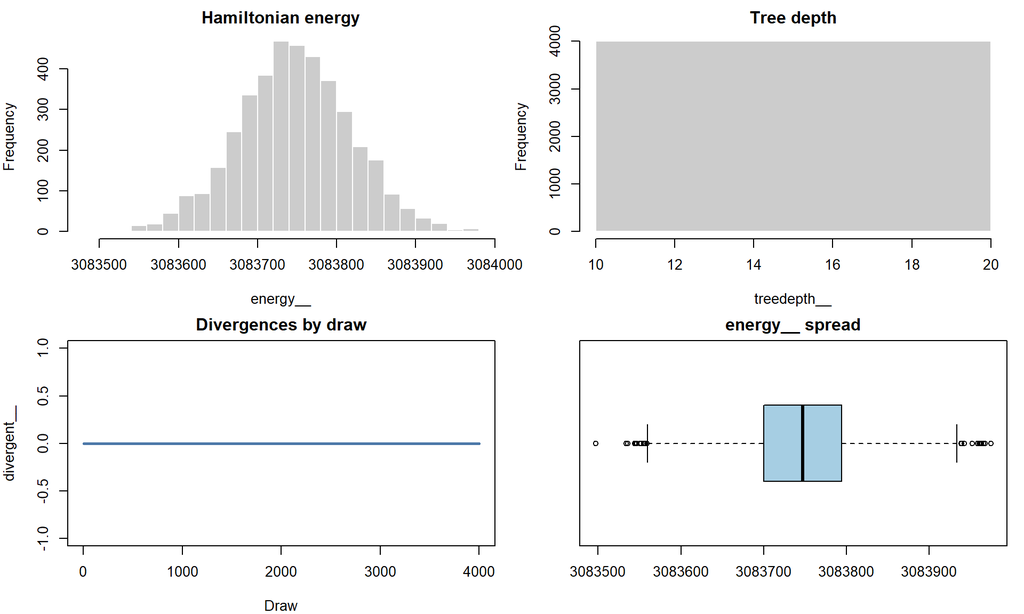

```r
# Check chain mixing, divergences, and tree depth behavior.
plot(fit_logistic)
```

```r
nuts <- nuts_params(fit_logistic)
divs <- sum(nuts$Parameter == "divergent__" & nuts$Value == 1)
max_td <- max(nuts[nuts$Parameter == "treedepth__", "Value"])
cat("Divergences:", divs, "\n")
```

```
## Divergences: 0
```

```r
cat("Max treedepth observed:", max_td, "\n")
```

```
## Max treedepth observed: 12
```

# 12 Posterior population-level parameter distributions

This section summarizes what the *population-level* model implies.

Diagnostic criteria: a) region-level inflection-year baselines should be plausible; b) region-level speed centers should align with the WB calibration.

```r
fpet_par_draws <- rstan::extract(
  fit_logistic$stanfit,
  pars = c("mu_logitK_region", "mu_logs_region", "mu_t0_region"),
  permuted = TRUE
)

region_meta_fpet <- fit_logistic$meta$region_tbl %>%
  mutate(region = factor(region, levels = region_label_lookup$region))

t0_region_posterior <- bind_rows(
  lapply(seq_len(nrow(region_meta_fpet)), function(i) {
    tibble(
      region_prior = region_meta_fpet$region_prior[i],
      region = region_meta_fpet$region[i],
      t0_year = 2000 + fpet_par_draws$mu_t0_region[, i]
    )
  })
)

speed_region_summary <- bind_rows(
  lapply(seq_len(nrow(region_meta_fpet)), function(i) {
    tibble(
      region_prior = region_meta_fpet$region_prior[i],
      region = region_meta_fpet$region[i],
      s_mean = mean(exp(fpet_par_draws$mu_logs_region[, i])),
      s_p25 = quantile(exp(fpet_par_draws$mu_logs_region[, i]), 0.25),
      s_p75 = quantile(exp(fpet_par_draws$mu_logs_region[, i]), 0.75),
      K_mean = mean(plogis(fpet_par_draws$mu_logitK_region[, i])),
      K_p25 = quantile(plogis(fpet_par_draws$mu_logitK_region[, i]), 0.25),
      K_p75 = quantile(plogis(fpet_par_draws$mu_logitK_region[, i]), 0.75)
    )
  })
)

knitr::kable(
  speed_region_summary %>%
    mutate(across(where(is.numeric), ~ round(.x, 3))),
  caption = "Posterior region-level centers for s and K under the FPET-style model"
)
```

Posterior region-level centers for s and K under the FPET-style model

| region_prior | region | s_mean | s_p25 | s_p75 | K_mean | K_p25 | K_p75 |
| --- | --- | --- | --- | --- | --- | --- | --- |
| CAF | Central Africa | 9.589 | 7.885 | 10.915 | 0.210 | 0.178 | 0.238 |
| EAP | East Asia and Pacific | 26.387 | 19.634 | 31.214 | 0.483 | 0.435 | 0.529 |
| ESA | East/Southern Africa | 9.214 | 8.606 | 9.768 | 0.488 | 0.457 | 0.518 |
| ECA | Europe and Central Asia | 60.742 | 50.891 | 68.978 | 0.986 | 0.983 | 0.993 |
| LAC | Latin America and Carribbean | 11.035 | 9.454 | 12.228 | 0.514 | 0.478 | 0.550 |
| MENA | Middle East and North Africa | 10.025 | 8.656 | 11.175 | 0.475 | 0.441 | 0.510 |
| SA | South Asia | 17.953 | 14.570 | 20.481 | 0.466 | 0.423 | 0.508 |
| WAF | West Africa | 14.649 | 13.288 | 15.909 | 0.371 | 0.321 | 0.412 |

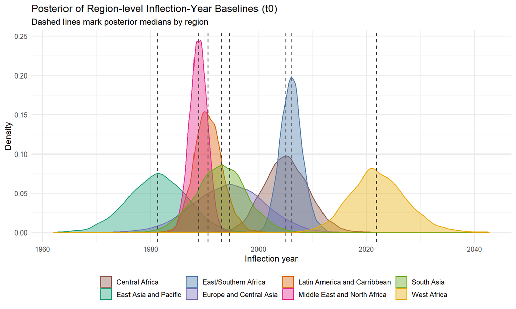

```r
ggplot(t0_region_posterior, aes(x = t0_year, color = region, fill = region)) +
  geom_density(alpha = 0.40, linewidth = 0.7) +
  geom_vline(
    data = t0_region_posterior %>%
      group_by(region) %>%
      summarise(v = median(t0_year), .groups = "drop"),
    aes(xintercept = v),
    linetype = "dashed",
    linewidth = 0.6,
    color = "grey25",
    show.legend = FALSE
  ) +
  theme_minimal(base_size = 12) +
  theme(
    legend.position = "bottom",
    legend.title = element_blank()
  ) +
  scale_color_manual(values = region_palette) +
  scale_fill_manual(values = region_palette) +
  labs(
    title = "Posterior of Region-level Inflection-Year Baselines (t0)",
    subtitle = "Dashed lines mark posterior medians by region",
    x = "Inflection year",
    y = "Density"
  )
```

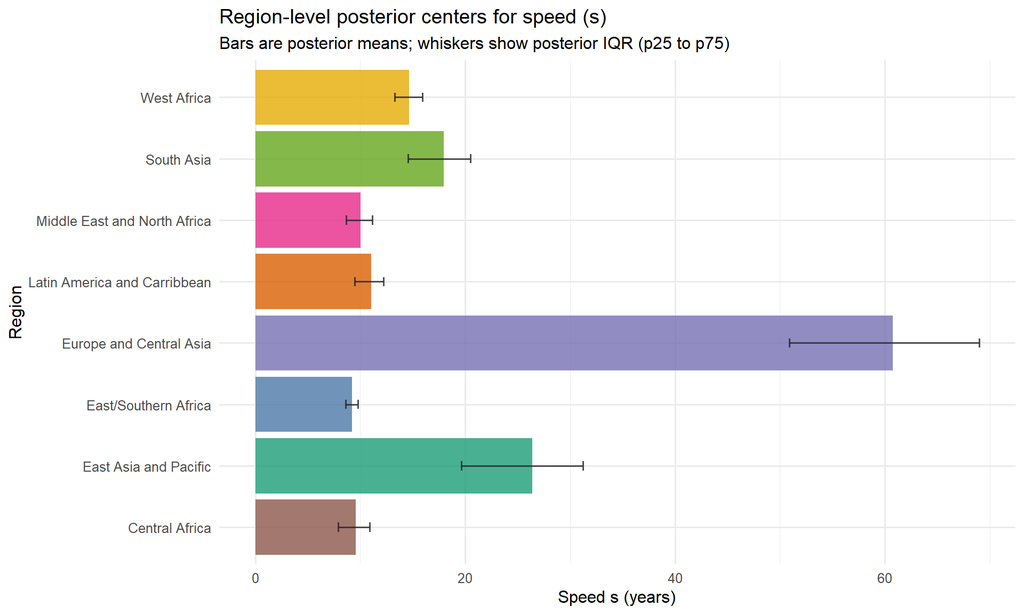

```r
ggplot(speed_region_summary, aes(x = region, y = s_mean, fill = region)) +
  geom_col(alpha = 0.8) +
  geom_errorbar(
    aes(ymin = s_p25, ymax = s_p75),
    width = 0.15, linewidth = 0.7, color = "grey15", alpha = 0.8
  ) +
  coord_flip() +
  theme_minimal(base_size = 12) +
  theme(legend.position = "none") +
  scale_fill_manual(values = region_palette) +
  labs(
    title = "Region-level posterior centers for speed (s)",
    subtitle = "Bars are posterior means; whiskers show posterior IQR (p25 to p75)",
    x = "Region",
    y = "Speed s (years)"
  )
```

# 13 Prior-to-posterior update checks

These diagnostics show how the likelihood updates key prior assumptions after seeing the data.

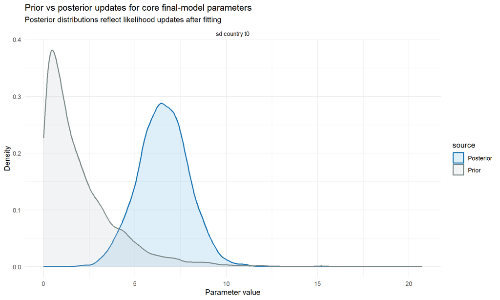

```r
set.seed(20260225)
fpet_all_draws <- rstan::extract(
  fit_logistic$stanfit,
  pars = c("mu_logitK_region", "mu_t0_region", "sigma_t0_country"),
  permuted = TRUE
)
n_draws_update <- length(fpet_all_draws$sigma_t0_country)

core_update <- bind_rows(
  tibble(parameter = "sd country t0", source = "Prior", value = rexp(n_draws_update, rate = 0.5)),
  tibble(parameter = "sd country t0", source = "Posterior", value = fpet_all_draws$sigma_t0_country)
)

ggplot(core_update, aes(x = value, color = source, fill = source)) +
  geom_density(alpha = 0.20, linewidth = 0.8) +
  facet_wrap(~ parameter, scales = "free", ncol = 1) +
  theme_minimal(base_size = 11) +
  scale_color_manual(values = c("Prior" = "#7F8C8D", "Posterior" = "#1F77B4")) +
  scale_fill_manual(values = c("Prior" = "#BDC3C7", "Posterior" = "#5DADE2")) +
  labs(
    title = "Prior vs posterior updates for core final-model parameters",
    subtitle = "Posterior distributions reflect likelihood updates after fitting",
    x = "Parameter value",
    y = "Density"
  )
```

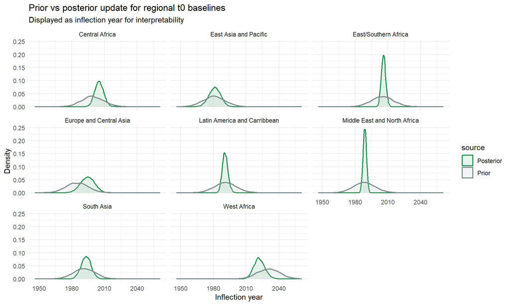

```r
t0_update_draws <- bind_rows(
  lapply(seq_len(nrow(region_meta_fpet)), function(i) {
    tibble(
      region_prior = region_meta_fpet$region_prior[i],
      region = region_meta_fpet$region[i],
      source = "Prior",
      t0_year = 2000 + stats::rnorm(
        n_draws_update,
        mean = wb_region_t0_prior_spec$prior_center_t0[match(region_meta_fpet$region_prior[i], wb_region_t0_prior_spec$region_prior)],
        sd = t0_prior_sd
      )
    )
  }),
  lapply(seq_len(nrow(region_meta_fpet)), function(i) {
    tibble(
      region_prior = region_meta_fpet$region_prior[i],
      region = region_meta_fpet$region[i],
      source = "Posterior",
      t0_year = 2000 + fpet_all_draws$mu_t0_region[, i]
    )
  })
)

ggplot(t0_update_draws, aes(x = t0_year, color = source, fill = source)) +
  geom_density(alpha = 0.20, linewidth = 0.8) +
  facet_wrap(~ factor(region, levels = region_label_lookup$region), ncol = 3) +
  theme_minimal(base_size = 11) +
  scale_color_manual(values = c("Prior" = "#7F8C8D", "Posterior" = "#2E8B57")) +
  scale_fill_manual(values = c("Prior" = "#BDC3C7", "Posterior" = "#7CCBA2")) +
  labs(
    title = "Prior vs posterior update for regional t0 baselines",
    subtitle = "Displayed as inflection year for interpretability",
    x = "Inflection year",
    y = "Density"
  )
```

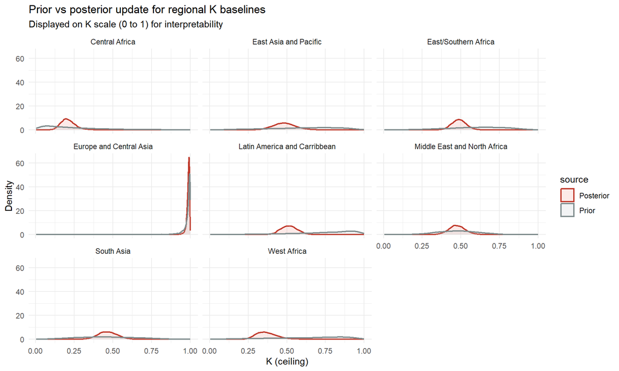

```r
k_update_draws <- bind_rows(
  lapply(seq_len(nrow(region_meta_fpet)), function(i) {
    tibble(
      region_prior = region_meta_fpet$region_prior[i],
      region = region_meta_fpet$region[i],
      source = "Prior",
      K_value = plogis(rnorm(
        n_draws_update,
        mean = wb_region_prior_spec$prior_mean[match(region_meta_fpet$region_prior[i], wb_region_prior_spec$region_prior)],
        sd = wb_region_prior_spec$prior_sd[match(region_meta_fpet$region_prior[i], wb_region_prior_spec$region_prior)]
      ))
    )
  }),
  lapply(seq_len(nrow(region_meta_fpet)), function(i) {
    tibble(
      region_prior = region_meta_fpet$region_prior[i],
      region = region_meta_fpet$region[i],
      source = "Posterior",
      K_value = plogis(fpet_all_draws$mu_logitK_region[, i])
    )
  })
)

ggplot(k_update_draws, aes(x = K_value, color = source, fill = source)) +
  geom_density(alpha = 0.20, linewidth = 0.8) +
  facet_wrap(~ factor(region, levels = region_label_lookup$region), ncol = 3) +
  theme_minimal(base_size = 11) +
  scale_color_manual(values = c("Prior" = "#7F8C8D", "Posterior" = "#C0392B")) +
  scale_fill_manual(values = c("Prior" = "#BDC3C7", "Posterior" = "#F1948A")) +
  labs(
    title = "Prior vs posterior update for regional K baselines",
    subtitle = "Displayed on K scale (0 to 1) for interpretability",
    x = "K (ceiling)",
    y = "Density"
  )
```

# 14 Fitted values and residual diagnostics

`posterior_epred()` returns expected counts:
$$\mathbb{E}[y_{it}\mid \text{data}] = n_{it} p_{it}.$$
We compute: a) $\hat y$: fitted counts, b) $\hat p = \hat y / n$: fitted probabilities.

Diagnostic criteria: a) observed vs fitted probabilities should lie close to the diagonal; b) Pearson residuals should be centered near 0 without strong structure.

```r
# Compute fitted probabilities and residual diagnostics on observed data.
ep_obs <- posterior_epred(fit_logistic, newdata = mcpr_logistic_data, re_formula = NULL)

y_hat_vec <- colMeans(ep_obs)
p_hat_vec <- y_hat_vec / mcpr_logistic_data$n

mcpr_logistic_data <- mcpr_logistic_data %>%
  mutate(
    p_hat = p_hat_vec,
    y_hat = y_hat_vec,
    prob_error = mCPR - p_hat,
    p_hat_clipped = pmax(pmin(p_hat, 0.999), 0.001),
    pearson_resid = (y - y_hat) / sqrt(n * p_hat_clipped * (1 - p_hat_clipped))
  )

summary(mcpr_logistic_data$p_hat)
```

```
##    Min. 1st Qu.  Median    Mean 3rd Qu.    Max.
## 0.01082 0.11402 0.21792 0.24178 0.35305 0.61408
```

```r
summary(mcpr_logistic_data$pearson_resid)
```

```
##     Min.  1st Qu.   Median     Mean  3rd Qu.     Max.
## -0.50304 -0.09419 -0.02089 -0.01203  0.05425  0.63807
```

```r
summary(abs(mcpr_logistic_data$prob_error))
```

```
##      Min.   1st Qu.    Median      Mean   3rd Qu.      Max.
## 1.816e-06 1.012e-04 2.806e-04 3.898e-04 5.665e-04 2.482e-03
```

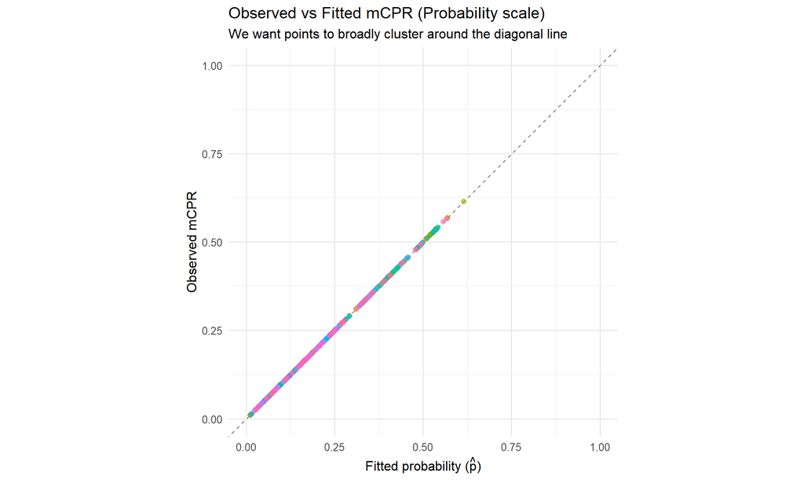

```r
# Visual diagnostics: observed-vs-fitted, residual patterns, and absolute error distribution.
ggplot(mcpr_logistic_data, aes(x = p_hat, y = mCPR, color = country)) +
  geom_abline(slope = 1, intercept = 0, linetype = "dashed", color = "grey50") +
  geom_point(alpha = 0.6, size = 2) +
  coord_equal(xlim = c(0, 1), ylim = c(0, 1)) +
  theme_minimal(base_size = 12) +
  theme(legend.position = "none") +
  labs(
    title = "Observed vs Fitted mCPR (Probability scale)",
    subtitle = "We want points to broadly cluster around the diagonal line",
    x = expression("Fitted probability (" * hat(p) * ")"),
    y = "Observed mCPR"
  )
```

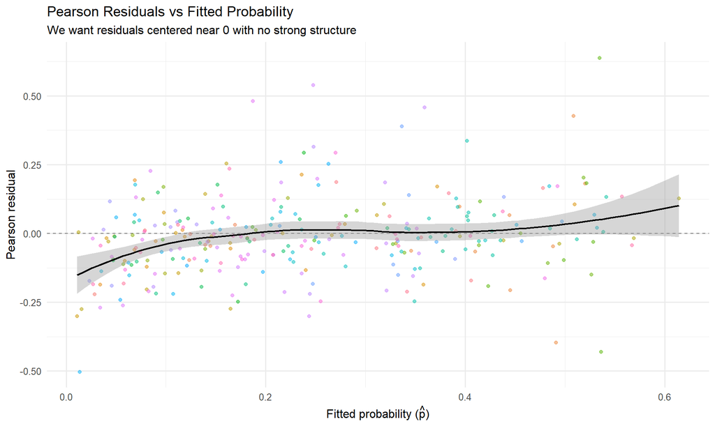

```r
ggplot(mcpr_logistic_data, aes(x = p_hat, y = pearson_resid, color = country)) +
  geom_hline(yintercept = 0, linetype = "dashed", color = "grey50") +
  geom_point(alpha = 0.5, size = 1.5) +
  geom_smooth(method = "loess", se = TRUE, color = "black", linewidth = 0.8) +
  theme_minimal(base_size = 12) +
  theme(legend.position = "none") +
  labs(
    title = "Pearson Residuals vs Fitted Probability",
    subtitle = "We want residuals centered near 0 with no strong structure",
    x = expression("Fitted probability (" * hat(p) * ")"),
    y = "Pearson residual"
  )
```

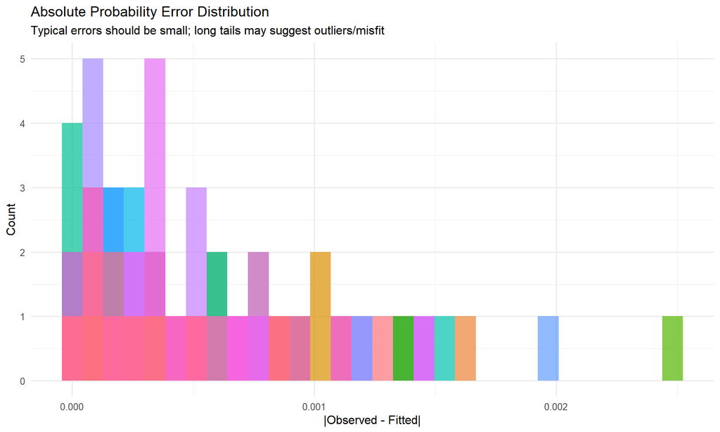

```r
ggplot(mcpr_logistic_data, aes(x = abs(prob_error), fill = country)) +
  geom_histogram(bins = 30, alpha = 0.7, position = "identity") +
  theme_minimal(base_size = 12) +
  theme(legend.position = "none") +
  labs(
    title = "Absolute Probability Error Distribution",
    subtitle = "Typical errors should be small; long tails may suggest outliers/misfit",
    x = "|Observed - Fitted|",
    y = "Count"
  )
```

# 15 Posterior predictive checks

Because the fitted model is binomial, a useful diagnostic is whether replicated datasets from the posterior look like the observed DHS data on the same probability scale.

Diagnostic criteria: a) observed summary statistics should sit inside the posterior predictive reference range; b) observed mCPR values should broadly fall inside pointwise posterior predictive intervals; c) the overall shape of the observed probability distribution should resemble replicated draws.

```r
# Draw replicated outcomes from the posterior predictive distribution and convert them
# back to the observed probability scale so they are directly comparable to DHS mCPR.
set.seed(20260307)
n_ppc_draws <- 200
yrep_obs <- posterior_predict(
  fit_logistic,
  newdata = mcpr_logistic_data,
  re_formula = NULL,
  ndraws = n_ppc_draws
)

if (is.null(dim(yrep_obs))) {
  yrep_obs <- matrix(yrep_obs, nrow = 1)
}

p_rep <- sweep(yrep_obs, 2, mcpr_logistic_data$n, "/")
obs_p <- mcpr_logistic_data$mCPR

ppc_stat_summary <- tibble(
  statistic = c("Mean mCPR", "SD mCPR", "Median mCPR", "Min mCPR", "Max mCPR"),
  observed = c(
    mean(obs_p, na.rm = TRUE),
    sd(obs_p, na.rm = TRUE),
    median(obs_p, na.rm = TRUE),
    min(obs_p, na.rm = TRUE),
    max(obs_p, na.rm = TRUE)
  ),
  pp_median = c(
    median(rowMeans(p_rep, na.rm = TRUE)),
    median(apply(p_rep, 1, sd, na.rm = TRUE)),
    median(apply(p_rep, 1, median, na.rm = TRUE)),
    median(apply(p_rep, 1, min, na.rm = TRUE)),
    median(apply(p_rep, 1, max, na.rm = TRUE))
  ),
  pp_p05 = c(
    quantile(rowMeans(p_rep, na.rm = TRUE), ci_lower, na.rm = TRUE),
    quantile(apply(p_rep, 1, sd, na.rm = TRUE), ci_lower, na.rm = TRUE),
    quantile(apply(p_rep, 1, median, na.rm = TRUE), ci_lower, na.rm = TRUE),
    quantile(apply(p_rep, 1, min, na.rm = TRUE), ci_lower, na.rm = TRUE),
    quantile(apply(p_rep, 1, max, na.rm = TRUE), ci_lower, na.rm = TRUE)
  ),
  pp_p95 = c(
    quantile(rowMeans(p_rep, na.rm = TRUE), ci_upper, na.rm = TRUE),
    quantile(apply(p_rep, 1, sd, na.rm = TRUE), ci_upper, na.rm = TRUE),
    quantile(apply(p_rep, 1, median, na.rm = TRUE), ci_upper, na.rm = TRUE),
    quantile(apply(p_rep, 1, min, na.rm = TRUE), ci_upper, na.rm = TRUE),
    quantile(apply(p_rep, 1, max, na.rm = TRUE), ci_upper, na.rm = TRUE)
  )
) %>%
  mutate(
    observed_inside_pp95 = observed >= pp_p05 & observed <= pp_p95
  )

knitr::kable(
  ppc_stat_summary %>%
    select(statistic, observed, pp_median, observed_inside_pp95) %>%
    mutate(across(where(is.numeric), ~ round(.x, 4))),
  caption = "Posterior predictive summary checks on the DHS probability scale"
)
```

Posterior predictive summary checks on the DHS probability scale

| statistic | observed | pp_median | observed_inside_pp95 |
| --- | --- | --- | --- |
| Mean mCPR | 0.2418 | 0.2418 | TRUE |
| SD mCPR | 0.1492 | 0.1492 | TRUE |
| Median mCPR | 0.2175 | 0.2194 | TRUE |
| Min mCPR | 0.0103 | 0.0101 | TRUE |
| Max mCPR | 0.6144 | 0.6141 | TRUE |

```r
ppc_interval_df <- mcpr_logistic_data %>%
  transmute(
    country,
    year,
    region,
    obs_p = mCPR,
    pp_mean = colMeans(p_rep, na.rm = TRUE),
    pp_lo = apply(p_rep, 2, quantile, probs = ci_lower, na.rm = TRUE),
    pp_hi = apply(p_rep, 2, quantile, probs = ci_upper, na.rm = TRUE)
  ) %>%
  mutate(inside_pp95 = obs_p >= pp_lo & obs_p <= pp_hi)

ppc_pointwise_coverage <- mean(ppc_interval_df$inside_pp95, na.rm = TRUE)
cat(
  "Pointwise 95% posterior predictive coverage on the observed probability scale:",
  round(100 * ppc_pointwise_coverage, 1), "%\n"
)
```

```
## Pointwise 95% posterior predictive coverage on the observed probability scale: 100 %
```

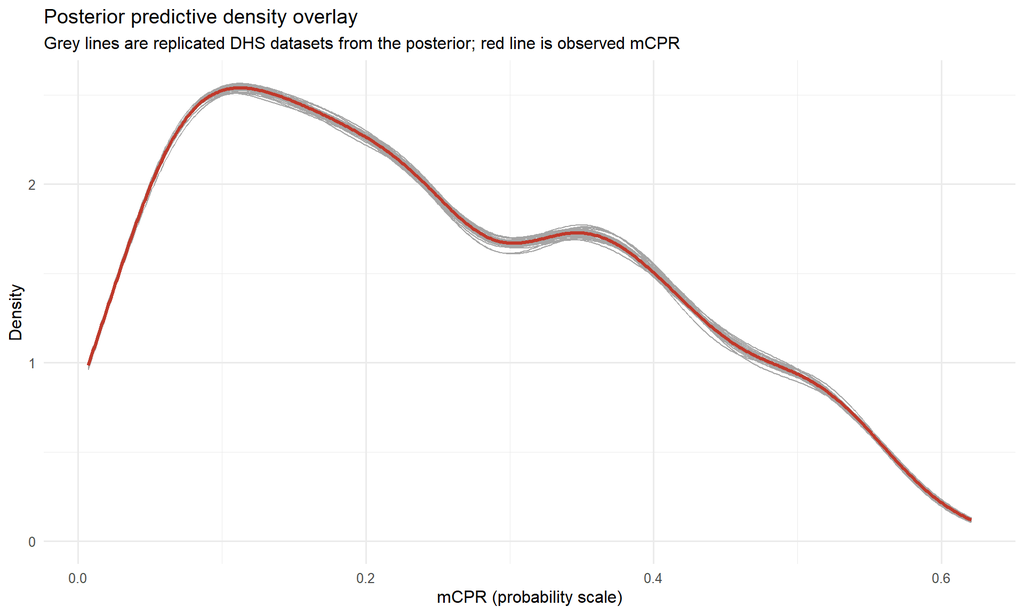

```r
# Visualize replicated probability distributions and pointwise predictive intervals.
ppc_draw_ids <- seq_len(min(30, nrow(p_rep)))

ppc_density_df <- bind_rows(
  tibble(
    source = "Observed",
    draw = "Observed",
    value = obs_p
  ),
  bind_rows(lapply(ppc_draw_ids, function(i) {
    tibble(
      source = "Replicated",
      draw = paste0("Draw ", i),
      value = p_rep[i, ]
    )
  }))
)

ggplot() +
  geom_density(
    data = ppc_density_df %>% filter(source == "Replicated"),
    aes(x = value, group = draw),
    color = "grey65",
    linewidth = 0.45,
    alpha = 0.35
  ) +
  geom_density(
    data = ppc_density_df %>% filter(source == "Observed"),
    aes(x = value),
    color = "#C0392B",
    linewidth = 1.1
  ) +
  theme_minimal(base_size = 12) +
  labs(
    title = "Posterior predictive density overlay",
    subtitle = "Grey lines are replicated DHS datasets from the posterior; red line is observed mCPR",
    x = "mCPR (probability scale)",
    y = "Density"
  )
```

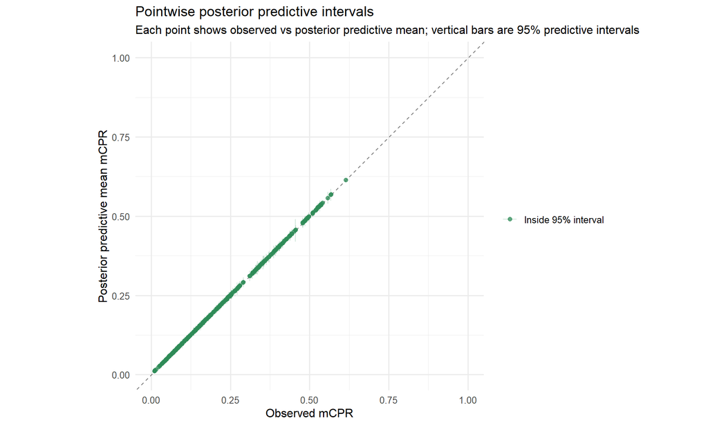

```r
ggplot(ppc_interval_df, aes(x = obs_p, y = pp_mean, color = inside_pp95)) +
  geom_abline(slope = 1, intercept = 0, linetype = "dashed", color = "grey50") +
  geom_errorbar(aes(ymin = pp_lo, ymax = pp_hi), alpha = 0.22, width = 0) +
  geom_point(alpha = 0.75, size = 1.8) +
  coord_equal(xlim = c(0, 1), ylim = c(0, 1)) +
  scale_color_manual(
    values = c("TRUE" = "#2E8B57", "FALSE" = "#C0392B"),
    labels = c("FALSE" = "Outside 95% interval", "TRUE" = "Inside 95% interval")
  ) +
  theme_minimal(base_size = 12) +
  labs(
    title = "Pointwise posterior predictive intervals",
    subtitle = "Each point shows observed vs posterior predictive mean; vertical bars are 95% predictive intervals",
    x = "Observed mCPR",
    y = "Posterior predictive mean mCPR",
    color = NULL
  )
```

# 16 Residual shape check

The binomial model does **not** assume Gaussian errors. This section therefore uses Pearson residual shape as a heuristic check only. Strong skew, heavy tails, or large QQ-plot departures would suggest remaining misfit in the mean structure.

```r
# Summarize Pearson residual shape and compare it to a normal reference only as
# a heuristic diagnostic, not as a formal model assumption.
resid_df <- mcpr_logistic_data %>%
  filter(is.finite(pearson_resid)) %>%
  transmute(pearson_resid)

resid_mean <- mean(resid_df$pearson_resid, na.rm = TRUE)
resid_sd <- sd(resid_df$pearson_resid, na.rm = TRUE)
resid_centered <- resid_df$pearson_resid - resid_mean

resid_shape_summary <- tibble(
  mean_resid = resid_mean,
  sd_resid = resid_sd,
  skewness = mean(resid_centered^3, na.rm = TRUE) / (resid_sd^3),
  excess_kurtosis = mean(resid_centered^4, na.rm = TRUE) / (resid_sd^4) - 3
)

knitr::kable(
  resid_shape_summary %>% mutate(across(where(is.numeric), ~ round(.x, 3))),
  caption = "Pearson residual shape summary"
)
```

Pearson residual shape summary

| mean_resid | sd_resid | skewness | excess_kurtosis |
| --- | --- | --- | --- |
| -0.012 | 0.146 | 0.657 | 2.546 |

```r
qq_probs <- ppoints(nrow(resid_df))
qq_theoretical <- qnorm(qq_probs)
qq_sample <- sort(resid_df$pearson_resid)
qq_slope <- IQR(qq_sample, na.rm = TRUE) / IQR(qq_theoretical, na.rm = TRUE)
qq_intercept <- median(qq_sample, na.rm = TRUE) - qq_slope * median(qq_theoretical, na.rm = TRUE)
qq_df <- tibble(theoretical = qq_theoretical, sample = qq_sample)
```

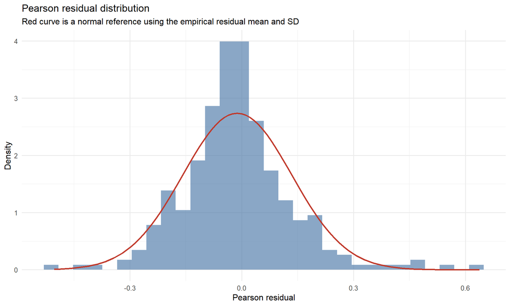

```r
ggplot(resid_df, aes(x = pearson_resid)) +
  geom_histogram(aes(y = after_stat(density)), bins = 30, fill = "#4C78A8", alpha = 0.65) +
  stat_function(
    fun = dnorm,
    args = list(mean = resid_mean, sd = resid_sd),
    color = "#C0392B",
    linewidth = 0.9
  ) +
  theme_minimal(base_size = 12) +
  labs(
    title = "Pearson residual distribution",
    subtitle = "Red curve is a normal reference using the empirical residual mean and SD",
    x = "Pearson residual",
    y = "Density"
  )
```

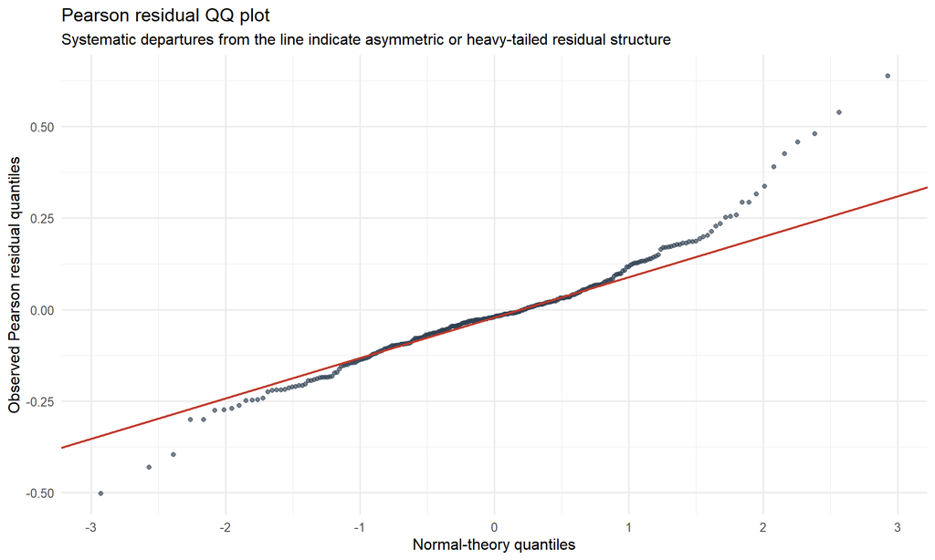

```r
ggplot(qq_df, aes(x = theoretical, y = sample)) +
  geom_point(alpha = 0.65, size = 1.4, color = "#2C3E50") +
  geom_abline(intercept = qq_intercept, slope = qq_slope, color = "#C0392B", linewidth = 0.8) +
  theme_minimal(base_size = 12) +
  labs(
    title = "Pearson residual QQ plot",
    subtitle = "Systematic departures from the line indicate asymmetric or heavy-tailed residual structure",
    x = "Normal-theory quantiles",
    y = "Observed Pearson residual quantiles"
  )
```

# 17 Residual serial-correlation check

If the logistic mean structure has captured most of the time dependence, within-country residuals should show limited lagged correlation after ordering observations by year.

Diagnostic criteria: a) lag-1 residual scatter should be centered near the origin without a strong linear trend; b) average lag correlation should be modest rather than persistently large across lags.

```r
# Check whether residuals are still serially correlated within country over time.
resid_serial_df <- mcpr_logistic_data %>%
  arrange(country, year) %>%
  group_by(country) %>%
  mutate(
    lag1_resid = lag(pearson_resid),
    lag_gap_years = year - lag(year)
  ) %>%
  ungroup()

lag_summary <- bind_rows(lapply(1:4, function(k) {
  lag_k <- mcpr_logistic_data %>%
    arrange(country, year) %>%
    group_by(country) %>%
    summarise(
      n_pairs = sum(is.finite(pearson_resid) & is.finite(dplyr::lag(pearson_resid, k))),
      lag_corr = if (n_pairs >= 2) {
        cor(pearson_resid, dplyr::lag(pearson_resid, k), use = "complete.obs")
      } else {
        NA_real_
      },
      .groups = "drop"
    ) %>%
    filter(is.finite(lag_corr), n_pairs > 0)

  tibble(
    lag = k,
    n_countries = nrow(lag_k),
    weighted_mean_corr = if (nrow(lag_k) > 0) weighted.mean(lag_k$lag_corr, lag_k$n_pairs) else NA_real_,
    median_country_corr = if (nrow(lag_k) > 0) median(lag_k$lag_corr, na.rm = TRUE) else NA_real_
  )
}))

lag1_country_corr <- mcpr_logistic_data %>%
  arrange(country, year) %>%
  group_by(country) %>%
  summarise(
    n_pairs = sum(is.finite(pearson_resid) & is.finite(lag(pearson_resid))),
    lag1_corr = if (n_pairs >= 2) cor(pearson_resid, lag(pearson_resid), use = "complete.obs") else NA_real_,
    .groups = "drop"
  ) %>%
  filter(is.finite(lag1_corr))

knitr::kable(
  lag_summary %>% mutate(across(where(is.numeric), ~ round(.x, 3))),
  caption = "Within-country residual lag correlation summary"
)
```

Within-country residual lag correlation summary

| lag | n_countries | weighted_mean_corr | median_country_corr |
| --- | --- | --- | --- |
| 1 | 48 | -0.473 | -0.589 |
| 2 | 40 | -0.041 | 0.180 |
| 3 | 30 | 0.222 | 0.295 |
| 4 | 20 | -0.108 | -0.354 |

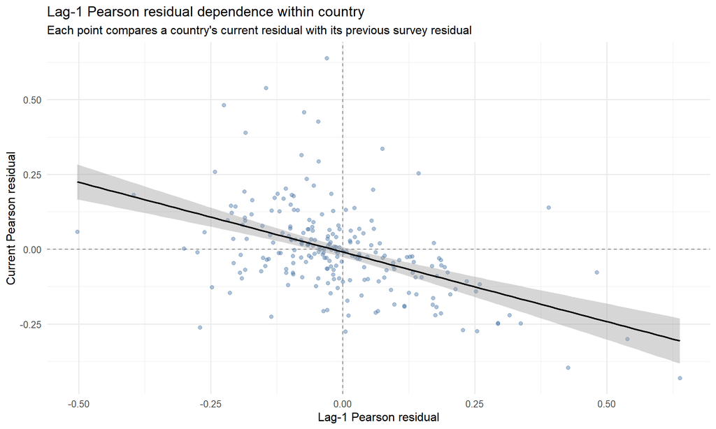

```r
ggplot(
  resid_serial_df %>% filter(is.finite(lag1_resid), is.finite(pearson_resid)),
  aes(x = lag1_resid, y = pearson_resid)
) +
  geom_hline(yintercept = 0, linetype = "dashed", color = "grey50") +
  geom_vline(xintercept = 0, linetype = "dashed", color = "grey50") +
  geom_point(alpha = 0.45, size = 1.6, color = "#4C78A8") +
  geom_smooth(method = "lm", se = TRUE, color = "black", linewidth = 0.8) +
  theme_minimal(base_size = 12) +
  labs(
    title = "Lag-1 Pearson residual dependence within country",
    subtitle = "Each point compares a country's current residual with its previous survey residual",
    x = "Lag-1 Pearson residual",
    y = "Current Pearson residual"
  )
```

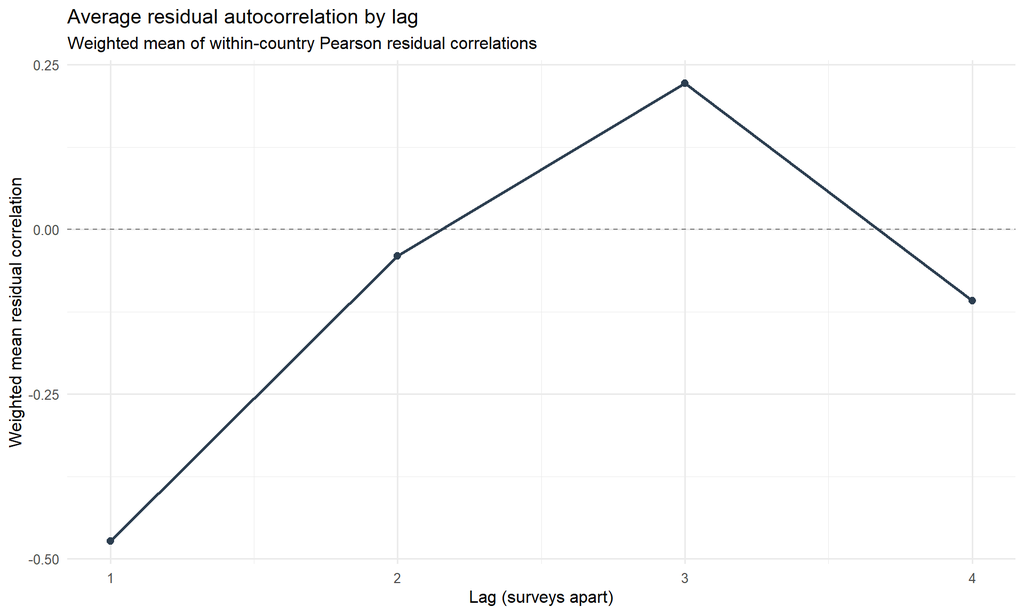

```r
ggplot(lag_summary, aes(x = lag, y = weighted_mean_corr)) +
  geom_hline(yintercept = 0, linetype = "dashed", color = "grey50") +
  geom_line(linewidth = 0.9, color = "#2C3E50") +
  geom_point(size = 2.2, color = "#2C3E50") +
  scale_x_continuous(breaks = lag_summary$lag) +
  theme_minimal(base_size = 12) +
  labs(
    title = "Average residual autocorrelation by lag",
    subtitle = "Weighted mean of within-country Pearson residual correlations",
    x = "Lag (surveys apart)",
    y = "Weighted mean residual correlation"
  )
```

# 18 Validation: 10-country holdout on last observation (2010-prioritized)

To test out-of-sample performance, we run a small holdout exercise:

```r
# Fix seed so selected holdout countries are reproducible.
set.seed(2026)

# Summarize each country's panel depth and whether it has data near 2010.
country_last_info <- mcpr_logistic_data %>%
  group_by(country) %>%
  summarise(
    n_obs = n(),
    last_year = max(year, na.rm = TRUE),
    has_obs_around_2010 = any(year >= 2008 & year <= 2012),
    .groups = "drop"
  ) %>%
  filter(n_obs >= 4) %>%
  arrange(desc(has_obs_around_2010), abs(last_year - 2010), desc(n_obs), country)

# Select 10 holdout countries, prioritizing those with observations around 2010.
holdout_countries <- country_last_info %>%
  slice_head(n = 10) %>%
  pull(country)

# For each selected country, hold out its last observed survey point.
holdout_rows <- mcpr_logistic_data %>%
  filter(country %in% holdout_countries) %>%
  group_by(country) %>%
  slice_max(order_by = year, n = 1, with_ties = FALSE) %>%
  ungroup() %>%
  left_join(country_last_info %>% select(country, n_obs, last_year, has_obs_around_2010),
            by = "country") %>%
  arrange(country)

# Training data are all rows except held-out row_ids.
train_holdout_data <- mcpr_logistic_data %>%
  anti_join(holdout_rows %>% select(row_id), by = "row_id")

# Print holdout design table for transparency.
holdout_rows %>%
  select(country, n_obs, has_obs_around_2010, year, mCPR, n_women) %>%
  arrange(desc(has_obs_around_2010), abs(year - 2010), country)
```

```
## # A tibble: 10 x 6
##    country   n_obs has_obs_around_2010  year  mCPR n_women
##    <chr>     <int> <lgl>               <int> <dbl>   <dbl>
##  1 Bolivia       5 TRUE                 2008 0.240  16939.
##  2 Niger         4 TRUE                 2012 0.110  11160.
##  3 Peru         10 TRUE                 2012 0.361  23888.
##  4 Egypt         8 TRUE                 2014 0.535  21762.
##  5 Colombia      7 TRUE                 2015 0.614  36300.
##  6 Zimbabwe      6 TRUE                 2015 0.479   9955.
##  7 Armenia       4 TRUE                 2016 0.181   6116.
##  8 Haiti         5 TRUE                 2016 0.223  14371.
##  9 Uganda        6 TRUE                 2016 0.273  18506.
## 10 Indonesia     8 TRUE                 2017 0.414  49627.
```

```r
# Cache the validation fit, but only invalidate it when the underlying inputs or
# the main fitted model change, unless a manual validation refit is requested.
validation_fit_path <- paste0(
  "joint_ks_fpet_style/fits/",
  fit_logistic$config_name,
  "_",
  fit_logistic$scope,
  "_holdout10_lastobs_",
  validation_run_profile_label,
  ".rds"
)
validation_dependencies <- c(input_data_path, wb_input_path, fit_path)

validation_cache_ok <- !force_validation_refit && cache_is_current(validation_fit_path, validation_dependencies)

if (validation_cache_ok) {
  fit_logistic_holdout <- readRDS(validation_fit_path)
  if (inherits(fit_logistic_holdout, "fpet_fit") &&
      inherits(fit_logistic_holdout$stanfit, "fpet_fit")) {
    fit_logistic_holdout$stanfit <- fit_logistic_holdout$stanfit$stanfit
  }
  holdout_draw_dims <- tryCatch(
    dim(rstan::extract(fit_logistic_holdout$stanfit, pars = "K_country", permuted = TRUE)$K_country),
    error = function(e) c(NA_integer_, NA_integer_)
  )
  if (!identical(as.integer(holdout_draw_dims[2]), as.integer(nrow(fit_logistic_holdout$meta$country_tbl)))) {
    warning("Cached holdout fit has mismatched country dimensions; skipping holdout validation in this high-ESS production render.")
    validation_cache_ok <- FALSE
  }
}

if (validation_cache_ok) {
  fit_logistic_holdout <- fit_logistic_holdout
} else {
  fit_logistic_holdout <- NULL
  cat("Holdout validation cache unavailable for this high-ESS production render; model-selection holdout results are reported in the model-ranking HTML.\n")
}
```

```
## Holdout validation cache unavailable for this high-ESS production render; model-selection holdout results are reported in the model-ranking HTML.
```

```r
# Display holdout-fit summary diagnostics.
invisible(fit_logistic_holdout)
```

```r
if (!is.null(fit_logistic_holdout)) {
  # Predict held-out rows on the count scale and convert to probability scale.
  ep_holdout <- posterior_epred(
    fit_logistic_holdout,
    newdata = holdout_rows,
    re_formula = NULL
  )

  p_holdout <- sweep(ep_holdout, 2, holdout_rows$n, FUN = "/")
  qcol <- function(x, p) apply(x, 2, quantile, probs = p)

  # Build per-country holdout comparison table: predicted mean/interval vs actual.
  holdout_eval <- holdout_rows %>%
    transmute(
      country,
      holdout_year = year,
      actual_mcpr = mCPR,
      pred_mean = colMeans(p_holdout),
      pred_p05 = qcol(p_holdout, ci_lower),
      pred_p95 = qcol(p_holdout, ci_upper)
    ) %>%
    mutate(
      error = pred_mean - actual_mcpr,
      abs_error = abs(error),
      covered_95 = actual_mcpr >= pred_p05 & actual_mcpr <= pred_p95
    ) %>%
    arrange(abs_error)

  # Aggregate holdout metrics to summarize forecast quality.
  validation_metrics <- holdout_eval %>%
    summarise(
      n_holdout = n(),
      MAE = mean(abs_error),
      RMSE = sqrt(mean(error^2)),
      mean_error = mean(error),
      coverage_95 = mean(covered_95)
    )
} else {
  holdout_eval <- holdout_rows %>%
    transmute(
      country,
      holdout_year = year,
      actual_mcpr = mCPR,
      pred_mean = NA_real_,
      pred_p05 = NA_real_,
      pred_p95 = NA_real_,
      error = NA_real_,
      abs_error = NA_real_,
      covered_95 = NA
    )

  validation_metrics <- tibble(
    n_holdout = nrow(holdout_rows),
    MAE = NA_real_,
    RMSE = NA_real_,
    mean_error = NA_real_,
    coverage_95 = NA_real_
  )
}

knitr::kable(
  validation_metrics %>%
    mutate(across(where(is.numeric), ~ round(.x, 4))),
  caption = "Summary metrics for the 10-country holdout validation"
)
```

Summary metrics for the 10-country holdout validation

| n_holdout | MAE | RMSE | mean_error | coverage_95 |
| --- | --- | --- | --- | --- |
| 10 | NA | NA | NA | NA |

```r
knitr::kable(
  holdout_eval %>%
    select(country, holdout_year, actual_mcpr, pred_mean, error, abs_error, covered_95) %>%
    mutate(across(where(is.numeric), ~ round(.x, 4))),
  caption = "Country-level holdout validation results"
)
```

Country-level holdout validation results

| country | holdout_year | actual_mcpr | pred_mean | error | abs_error | covered_95 |
| --- | --- | --- | --- | --- | --- | --- |
| Armenia | 2016 | 0.1813 | NA | NA | NA | NA |
| Bolivia | 2008 | 0.2397 | NA | NA | NA | NA |
| Colombia | 2015 | 0.6144 | NA | NA | NA | NA |
| Egypt | 2014 | 0.5348 | NA | NA | NA | NA |
| Haiti | 2016 | 0.2226 | NA | NA | NA | NA |
| Indonesia | 2017 | 0.4136 | NA | NA | NA | NA |
| Niger | 2012 | 0.1099 | NA | NA | NA | NA |
| Peru | 2012 | 0.3606 | NA | NA | NA | NA |
| Uganda | 2016 | 0.2729 | NA | NA | NA | NA |
| Zimbabwe | 2015 | 0.4788 | NA | NA | NA | NA |

[figure not shown]

```r
# Plot 1: predicted vs actual for held-out points with 95% intervals.
ggplot(holdout_eval, aes(x = pred_mean, y = actual_mcpr, label = country)) +
  geom_abline(slope = 1, intercept = 0, linetype = "dashed", color = "grey50") +
  geom_errorbarh(aes(xmin = pred_p05, xmax = pred_p95), height = 0, alpha = 0.7) +
  geom_point(size = 2.6, color = "#2b8cbe") +
  ggrepel::geom_text_repel(size = 3, max.overlaps = Inf) +
  coord_equal(xlim = c(0, 1), ylim = c(0, 1)) +
  theme_minimal(base_size = 12) +
  labs(
    title = "10-country holdout validation: projected vs actual last observation",
    subtitle = "Horizontal bars are 95% posterior intervals at the held-out year",
    x = "Projected mCPR at held-out year (posterior mean)",
    y = "Actual held-out mCPR"
  )
```

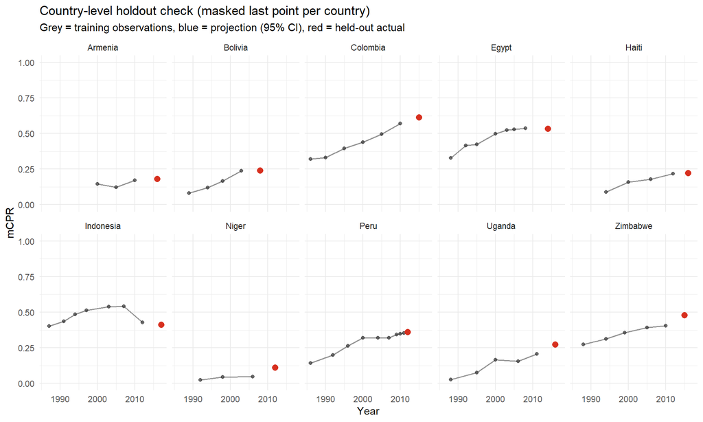

```r
# Build country-specific training trajectories for faceted holdout visualization.
train_plot <- train_holdout_data %>%
  filter(country %in% holdout_eval$country) %>%
  select(country, year, mCPR)

# Plot 2: each holdout country with train points + predicted held-out CI + actual held-out.
ggplot() +
  geom_line(
    data = train_plot,
    aes(x = year, y = mCPR, group = country),
    color = "grey40", alpha = 0.7, linewidth = 0.7
  ) +
  geom_point(
    data = train_plot,
    aes(x = year, y = mCPR),
    color = "grey20", alpha = 0.7, size = 1.4
  ) +
  geom_linerange(
    data = holdout_eval,
    aes(x = holdout_year, ymin = pred_p05, ymax = pred_p95),
    color = "#2b8cbe", linewidth = 0.9
  ) +
  geom_point(
    data = holdout_eval,
    aes(x = holdout_year, y = pred_mean),
    color = "#2b8cbe", size = 2.4
  ) +
  geom_point(
    data = holdout_eval,
    aes(x = holdout_year, y = actual_mcpr),
    color = "#d7301f", size = 2.6
  ) +
  facet_wrap(~ country, ncol = 5) +
  coord_cartesian(ylim = c(0, 1)) +
  theme_minimal(base_size = 11) +
  labs(
    title = "Country-level holdout check (masked last point per country)",
    subtitle = "Grey = training observations, blue = projection (95% CI), red = held-out actual",
    x = "Year",
    y = "mCPR"
  )
```

# 19 Posterior decision quantities (as-of 2026)

We evaluate each country at **year 2026** (even if the latest survey is earlier).  
For each country we compute posterior distributions for: a) $K_i$, b) $p_i(2026)$, c) headroom $K_i - p_i(2026)$, d) relative saturation $p_i(2026)/K_i$, e) growth rate $\left.\frac{dp_i(t)}{dt}\right|_{t=2026}$.

```r
# Draw posterior country-level K, s, and t0 directly from the FPET fit.
nd_country <- fit_logistic$meta$country_tbl %>%
  arrange(country) %>%
  mutate(country = as.character(country))

countries <- nd_country$country
country_idx <- match(countries, fit_logistic$meta$country_tbl$country)
fpet_country_draws <- get_fpet_draws(fit_logistic)

K_draws <- fpet_country_draws$K_country[, country_idx, drop = FALSE]
t0_draws <- fpet_country_draws$t0_country[, country_idx, drop = FALSE]
s_draws <- fpet_country_draws$s_country[, country_idx, drop = FALSE]

n_draws <- nrow(K_draws)
n_countries <- ncol(K_draws)
```

```r
# Evaluate posterior mCPR, growth, and headroom at decision year 2026.
t_dec_year <- 2026
t_dec <- t_dec_year - 2000

t_mat <- matrix(t_dec, nrow = n_draws, ncol = n_countries)
s_mat <- s_draws

z_mat <- exp(-(t_mat - t0_draws) / s_mat)
p_mat <- K_draws / (1 + z_mat)
dpdt_mat <- (K_draws / s_mat) * z_mat / (1 + z_mat)^2
d2pdt2_mat <- (K_draws / (s_mat^2)) * z_mat * (z_mat - 1) / (1 + z_mat)^3

t_goal_base_year <- 2025
t_goal_base <- t_goal_base_year - 2000
t_goal_base_mat <- matrix(t_goal_base, nrow = n_draws, ncol = n_countries)
z_goal_base_mat <- exp(-(t_goal_base_mat - t0_draws) / s_mat)
p_goal_base_mat <- K_draws / (1 + z_goal_base_mat)
dpdt_goal_base_mat <- (K_draws / s_mat) * z_goal_base_mat / (1 + z_goal_base_mat)^2

headroom_mat <- K_draws - p_mat
rellevel_mat <- p_mat / K_draws

qcol <- function(x, p) apply(x, 2, quantile, probs = p)

country_summary <- tibble(
  country = countries,
  decision_year = t_dec_year,
  K_mean = colMeans(K_draws),
  K_p05  = qcol(K_draws, ci_lower),
  K_p95  = qcol(K_draws, ci_upper),
  t0_mean = colMeans(t0_draws),
  t0_p05  = qcol(t0_draws, ci_lower),
  t0_p95  = qcol(t0_draws, ci_upper),
  s_mean = colMeans(s_draws),
  s_p05  = qcol(s_draws, ci_lower),
  s_p95  = qcol(s_draws, ci_upper),
  p_mean = colMeans(p_mat),
  p_p05  = qcol(p_mat, ci_lower),
  p_p95  = qcol(p_mat, ci_upper),
  head_mean = colMeans(headroom_mat),
  head_p05  = qcol(headroom_mat, ci_lower),
  head_p95  = qcol(headroom_mat, ci_upper),
  rel_mean = colMeans(rellevel_mat),
  rel_p05  = qcol(rellevel_mat, ci_lower),
  rel_p95  = qcol(rellevel_mat, ci_upper),
  dpdt_mean = colMeans(dpdt_mat),
  dpdt_p05  = qcol(dpdt_mat, ci_lower),
  dpdt_p95  = qcol(dpdt_mat, ci_upper),
  d2pdt2_mean = colMeans(d2pdt2_mat),
  d2pdt2_p05 = qcol(d2pdt2_mat, ci_lower),
  d2pdt2_p95 = qcol(d2pdt2_mat, ci_upper)
) %>%
  mutate(
    t0_year_mean = round(2000 + t0_mean),
    years_since_t0_2026 = decision_year - (2000 + t0_mean),
    accel_status_2026 = case_when(
      d2pdt2_p05 > 0 ~ "Accelerating",
      d2pdt2_p95 < 0 ~ "Decelerating",
      TRUE ~ "Near peak / uncertain"
    )
  )

summary(country_summary$K_mean)
```

```
##    Min. 1st Qu.  Median    Mean 3rd Qu.    Max.
##  0.1301  0.3530  0.4279  0.4803  0.5600  0.9833
```

```r
# Build region-level posterior intervals for key parameters under the final model.
nd_region_param <- fit_logistic$meta$region_tbl %>%
  mutate(region = factor(region, levels = region_label_lookup$region)) %>%
  arrange(region_prior)

if (nrow(nd_region_param) == 0) {
  stop("No observed regions found for region-level posterior interval plotting.")
}

K_region_draws <- plogis(fpet_par_draws$mu_logitK_region[, seq_len(nrow(nd_region_param)), drop = FALSE])
s_region_draws <- exp(fpet_par_draws$mu_logs_region[, seq_len(nrow(nd_region_param)), drop = FALSE])
t0_mat_region <- fpet_par_draws$mu_t0_region[, seq_len(nrow(nd_region_param)), drop = FALSE]
t_mat_region <- matrix(2026 - 2000, nrow = nrow(s_region_draws), ncol = ncol(s_region_draws))
p_region_draws <- K_region_draws / (1 + exp(-(t_mat_region - t0_mat_region) / s_region_draws))

qcol <- function(x, p) apply(x, 2, quantile, probs = p)

region_interval_summary <- tibble(
  region_prior = nd_region_param$region_prior,
  region = nd_region_param$region,
  K_p50 = apply(K_region_draws, 2, median),
  K_p05 = qcol(K_region_draws, ci_lower),
  K_p95 = qcol(K_region_draws, ci_upper),
  t0_year_p50 = 2000 + apply(t0_mat_region, 2, median),
  t0_year_p05 = 2000 + qcol(t0_mat_region, ci_lower),
  t0_year_p95 = 2000 + qcol(t0_mat_region, ci_upper),
  s_p50 = apply(s_region_draws, 2, median),
  s_p05 = qcol(s_region_draws, ci_lower),
  s_p95 = qcol(s_region_draws, ci_upper),
  p2026_p50 = apply(p_region_draws, 2, median),
  p2026_p05 = qcol(p_region_draws, ci_lower),
  p2026_p95 = qcol(p_region_draws, ci_upper)
)

knitr::kable(
  region_interval_summary %>%
    arrange(region) %>%
    transmute(
      region,
      region_prior,
      K = K_p50,
      t0_year = t0_year_p50,
      s_years = s_p50,
      p2026 = p2026_p50
    ) %>%
    mutate(across(where(is.numeric), ~ round(.x, 3))),
  caption = "Region-level posterior summaries (posterior medians)"
)
```

Region-level posterior summaries (posterior medians)

| region | region_prior | K | t0_year | s_years | p2026 |
| --- | --- | --- | --- | --- | --- |
| Central Africa | CAF | 0.206 | 2005.042 | 9.275 | 0.184 |
| East Asia and Pacific | EAP | 0.482 | 1981.288 | 24.487 | 0.410 |
| East/Southern Africa | ESA | 0.487 | 2006.045 | 9.163 | 0.436 |
| Europe and Central Asia | ECA | 0.989 | 1994.619 | 59.354 | 0.620 |
| Latin America and Carribbean | LAC | 0.514 | 1990.588 | 10.698 | 0.491 |
| Middle East and North Africa | MENA | 0.474 | 1988.888 | 9.794 | 0.461 |
| South Asia | SA | 0.465 | 1993.151 | 17.085 | 0.401 |
| West Africa | WAF | 0.363 | 2021.881 | 14.497 | 0.206 |

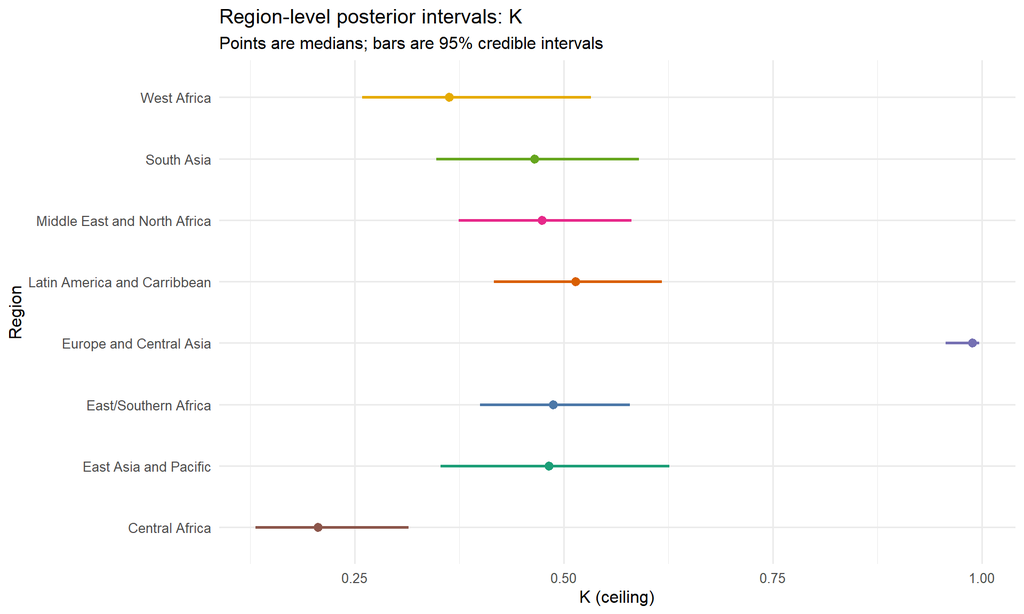

```r
region_interval_long <- bind_rows(
  region_interval_summary %>%
    transmute(region, region_prior, parameter = "K (ceiling)", p50 = K_p50, p05 = K_p05, p95 = K_p95),
  region_interval_summary %>%
    transmute(region, region_prior, parameter = "t0 (inflection year)", p50 = t0_year_p50, p05 = t0_year_p05, p95 = t0_year_p95),
  region_interval_summary %>%
    transmute(region, region_prior, parameter = "s (speed, years)", p50 = s_p50, p05 = s_p05, p95 = s_p95),
  region_interval_summary %>%
    transmute(region, region_prior, parameter = "p(2026)", p50 = p2026_p50, p05 = p2026_p05, p95 = p2026_p95)
)

plot_region_interval <- function(df_plot, plot_title, plot_subtitle, y_label) {
  ggplot(
    df_plot,
    aes(
      x = factor(region, levels = region_label_lookup$region),
      y = p50,
      ymin = p05,
      ymax = p95,
      color = region
    )
  ) +
    geom_pointrange(linewidth = 0.9) +
    coord_flip() +
    theme_minimal(base_size = 12) +
    theme(legend.position = "none") +
    scale_color_manual(values = region_palette) +
    labs(
      title = plot_title,
      subtitle = plot_subtitle,
      x = "Region",
      y = y_label
    )
}

plot_region_interval(
  region_interval_long %>% filter(parameter == "K (ceiling)"),
  "Region-level posterior intervals: K",
  "Points are medians; bars are 95% credible intervals",
  "K (ceiling)"
)
```

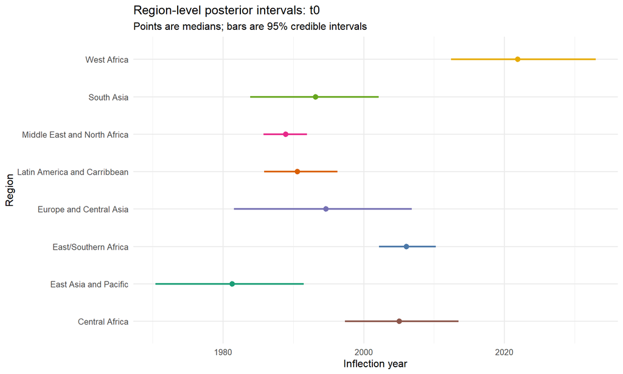

```r
plot_region_interval(
  region_interval_long %>% filter(parameter == "t0 (inflection year)"),
  "Region-level posterior intervals: t0",
  "Points are medians; bars are 95% credible intervals",
  "Inflection year"
)
```

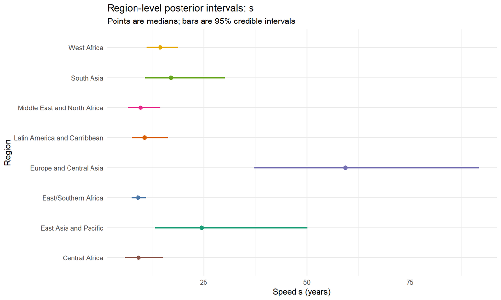

```r
plot_region_interval(
  region_interval_long %>% filter(parameter == "s (speed, years)"),
  "Region-level posterior intervals: s",
  "Points are medians; bars are 95% credible intervals",
  "Speed s (years)"
)
```

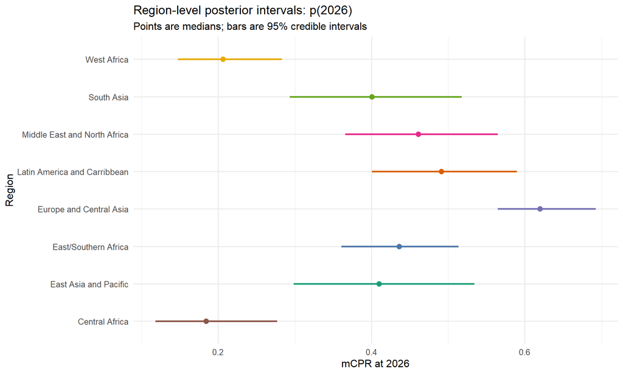

```r
plot_region_interval(
  region_interval_long %>% filter(parameter == "p(2026)"),
  "Region-level posterior intervals: p(2026)",
  "Points are medians; bars are 95% credible intervals",
  "mCPR at 2026"
)
```

# 20 Investment phase classification (rank-based leverage, as-of 2026)

Leverage is high when: a) growth at 2026 is high; and b) room-to-grow is high.

Classification steps:

1. Compute two room-to-grow signals: absolute headroom $K_i - p_i(2026)$ and relative room $1 - p_i(2026)/K_i$.
2. Convert growth and room quantities into percentile ranks from 0 to 1.
3. Build two leverage scores: `leverage_head` from growth rank x absolute-headroom rank, and `leverage_rel` from growth rank x relative-room rank.
4. Combine them into a final score: `leverage = 0.4 * leverage_head + 0.6 * leverage_rel`.
5. Assign phases from the top and bottom leverage groups.

```r
# Build rank-based leverage scores and assign countries into three investment phases.
pct_scaleup  <- 0.20
pct_maintain <- 0.20

df <- country_summary %>%
  mutate(
    room_abs = head_mean,
    room_rel = 1 - rel_mean,
    r_growth = dplyr::percent_rank(dpdt_mean),
    r_head   = dplyr::percent_rank(room_abs),
    r_room   = dplyr::percent_rank(room_rel),
    leverage_head = r_growth * r_head,
    leverage_rel  = r_growth * r_room,
    leverage = 0.4 * leverage_head + 0.6 * leverage_rel
  )

n_total <- nrow(df)
n_scaleup  <- max(5, round(pct_scaleup  * n_total))
n_maintain <- max(5, round(pct_maintain * n_total))

scaleup_set <- df %>% arrange(desc(leverage)) %>% slice_head(n = n_scaleup) %>% pull(country)
maintain_set <- df %>% arrange(leverage) %>% slice_head(n = n_maintain) %>% pull(country)

investment_table <- df %>%
  mutate(
    phase = case_when(
      country %in% scaleup_set  ~ "Scale-up",
      country %in% maintain_set ~ "Maintain / equity",
      TRUE                      ~ "Build / monitor"
    ),
    phase_priority = case_when(
      phase == "Scale-up"          ~ 1L,
      phase == "Build / monitor"   ~ 2L,
      phase == "Maintain / equity" ~ 3L,
      TRUE                         ~ 9L
    )
  ) %>%
  arrange(phase_priority, desc(leverage), desc(room_rel), desc(dpdt_mean))

investment_table %>% count(phase, phase_priority) %>% arrange(phase_priority)
```

```
## # A tibble: 3 x 3
##   phase             phase_priority     n
##   <chr>                      <int> <int>
## 1 Scale-up                       1    13
## 2 Build / monitor                2    37
## 3 Maintain / equity              3    13
```

```r
# Build a parallel investment table using headroom measured from each country's
# latest observed DHS mCPR instead of the posterior mean p(2026).
latest_country_obs_for_table <- mcpr_logistic_data %>%
  filter(!is.na(mCPR), !is.na(year)) %>%
  group_by(country) %>%
  slice_max(order_by = year, n = 1, with_ties = FALSE) %>%
  ungroup() %>%
  transmute(
    country,
    last_obs_year = year,
    last_obs_mcpr = mCPR
  )

df_lastobs_headroom <- country_summary %>%
  left_join(latest_country_obs_for_table, by = "country") %>%
  mutate(
    head_lastobs_mean = K_mean - last_obs_mcpr,
    rel_lastobs_mean = last_obs_mcpr / K_mean,
    room_rel_lastobs = 1 - rel_lastobs_mean,
    r_growth = dplyr::percent_rank(dpdt_mean),
    r_head_lastobs = dplyr::percent_rank(head_lastobs_mean),
    r_room_lastobs = dplyr::percent_rank(room_rel_lastobs),
    leverage_head_lastobs = r_growth * r_head_lastobs,
    leverage_rel_lastobs = r_growth * r_room_lastobs,
    leverage_lastobs = 0.4 * leverage_head_lastobs + 0.6 * leverage_rel_lastobs
  )

n_total_lastobs <- nrow(df_lastobs_headroom)
n_scaleup_lastobs <- max(5, round(pct_scaleup * n_total_lastobs))
n_maintain_lastobs <- max(5, round(pct_maintain * n_total_lastobs))

scaleup_lastobs_set <- df_lastobs_headroom %>%
  arrange(desc(leverage_lastobs)) %>%
  slice_head(n = n_scaleup_lastobs) %>%
  pull(country)

maintain_lastobs_set <- df_lastobs_headroom %>%
  arrange(leverage_lastobs) %>%
  slice_head(n = n_maintain_lastobs) %>%
  pull(country)

investment_table_lastobs <- df_lastobs_headroom %>%
  mutate(
    phase_lastobs = case_when(
      country %in% scaleup_lastobs_set ~ "Scale-up",
      country %in% maintain_lastobs_set ~ "Maintain / equity",
      TRUE ~ "Build / monitor"
    ),
    phase_priority_lastobs = case_when(
      phase_lastobs == "Scale-up" ~ 1L,
      phase_lastobs == "Build / monitor" ~ 2L,
      phase_lastobs == "Maintain / equity" ~ 3L,
      TRUE ~ 9L
    )
  ) %>%
  arrange(phase_priority_lastobs, desc(leverage_lastobs), desc(room_rel_lastobs), desc(dpdt_mean))

investment_table_lastobs %>%
  count(phase_lastobs, phase_priority_lastobs) %>%
  arrange(phase_priority_lastobs)
```

```
## # A tibble: 3 x 3
##   phase_lastobs     phase_priority_lastobs     n
##   <chr>                              <int> <int>
## 1 Scale-up                               1    13
## 2 Build / monitor                        2    37
## 3 Maintain / equity                      3    13
```

# 21 Results

## 21.1 Country investment table (as-of 2026)

How to interpret the columns: All quantities below are conditional on the final-model structure (country-level $K$, country-level $s$, country-level $t_0$, and an AR(1) historical deviation around the smooth transition path).

1. `country`: country name.
2. `decision_year`: decision horizon (fixed at 2026).
3. `phase`: investment phase label.
4. `leverage`: final composite leverage score used for ranking.
5. `leverage_head`: leverage from growth x absolute headroom rank.
6. `leverage_rel`: leverage from growth x relative room-to-grow rank.
7. `p_mean`: posterior mean $p_i(2026)$, expected mCPR at 2026.
8. `K_mean`: posterior mean ceiling $K_i$.
9. `s_mean`: posterior mean country speed $s_i$.
10. `head_mean`: absolute headroom $K_i - p_i(2026)$.
11. `rel_mean`: relative saturation $p_i(2026)/K_i$.
12. `room_rel`: relative room-to-grow $1 - p_i(2026)/K_i$.
13. `dpdt_mean`: growth rate at 2026.
14. `t0_year_mean`: posterior mean inflection year.

```r
# Print a compact table of phase assignments and key posterior summaries.
knitr::kable(
  investment_table %>%
    select(country, decision_year, phase, leverage, leverage_head, leverage_rel,
           p_mean, K_mean, s_mean, head_mean, rel_mean, room_rel, dpdt_mean, t0_year_mean) %>%
    mutate(across(where(is.numeric), ~ round(.x, 4))),
  caption = "Country Investment Phase Summary (as-of 2026; selected columns)",
  align   = "l"
)
```

Country Investment Phase Summary (as-of 2026; selected columns)

| country | decision_year | phase | leverage | leverage_head | leverage_rel | p_mean | K_mean | s_mean | head_mean | rel_mean | room_rel | dpdt_mean | t0_year_mean |
| --- | --- | --- | --- | --- | --- | --- | --- | --- | --- | --- | --- | --- | --- |
| Sierra Leone | 2026 | Scale-up | 0.8982 | 0.8887 | 0.9045 | 0.2427 | 0.4377 | 14.3533 | 0.1950 | 0.5643 | 0.4357 | 0.0072 | 2023 |
| Burkina Faso | 2026 | Scale-up | 0.8678 | 0.8585 | 0.8741 | 0.2405 | 0.4279 | 14.2560 | 0.1874 | 0.5714 | 0.4286 | 0.0070 | 2022 |
| Niger | 2026 | Scale-up | 0.8479 | 0.7867 | 0.8887 | 0.1852 | 0.3566 | 14.1723 | 0.1714 | 0.5374 | 0.4626 | 0.0060 | 2024 |
| Gambia | 2026 | Scale-up | 0.7440 | 0.6894 | 0.7804 | 0.1870 | 0.3538 | 14.5145 | 0.1668 | 0.5436 | 0.4564 | 0.0058 | 2024 |
| Togo | 2026 | Scale-up | 0.7138 | 0.6899 | 0.7297 | 0.2114 | 0.3709 | 14.9059 | 0.1595 | 0.5892 | 0.4108 | 0.0058 | 2021 |
| Mozambique | 2026 | Scale-up | 0.6839 | 0.6935 | 0.6774 | 0.4226 | 0.5271 | 9.4792 | 0.1045 | 0.8069 | 0.1931 | 0.0083 | 2012 |
| Mali | 2026 | Scale-up | 0.6649 | 0.5736 | 0.7258 | 0.1511 | 0.3004 | 13.4086 | 0.1493 | 0.5209 | 0.4791 | 0.0053 | 2026 |
| Liberia | 2026 | Scale-up | 0.6331 | 0.6899 | 0.5952 | 0.2989 | 0.4559 | 16.6080 | 0.1570 | 0.6693 | 0.3307 | 0.0059 | 2015 |
| Guinea | 2026 | Scale-up | 0.6273 | 0.5723 | 0.6639 | 0.1815 | 0.3344 | 14.9608 | 0.1529 | 0.5631 | 0.4369 | 0.0053 | 2023 |
| Burundi | 2026 | Scale-up | 0.6247 | 0.5884 | 0.6488 | 0.2605 | 0.3431 | 8.5221 | 0.0827 | 0.7818 | 0.2182 | 0.0067 | 2015 |
| Cote d’Ivoire | 2026 | Scale-up | 0.6175 | 0.5744 | 0.6462 | 0.2039 | 0.3522 | 15.1889 | 0.1483 | 0.5974 | 0.4026 | 0.0054 | 2020 |
| Benin | 2026 | Scale-up | 0.6018 | 0.5146 | 0.6600 | 0.1677 | 0.3116 | 14.6599 | 0.1439 | 0.5613 | 0.4387 | 0.0051 | 2023 |
| Ghana | 2026 | Scale-up | 0.5820 | 0.5747 | 0.5869 | 0.2248 | 0.3692 | 15.3983 | 0.1444 | 0.6239 | 0.3761 | 0.0054 | 2019 |
| Senegal | 2026 | Build / monitor | 0.5312 | 0.4800 | 0.5653 | 0.1723 | 0.2925 | 15.0865 | 0.1202 | 0.6013 | 0.3987 | 0.0045 | 2020 |
| Armenia | 2026 | Build / monitor | 0.5236 | 0.5871 | 0.4813 | 0.6096 | 0.9828 | 61.8220 | 0.3732 | 0.6203 | 0.3797 | 0.0040 | 1997 |
| Nigeria | 2026 | Build / monitor | 0.4951 | 0.4464 | 0.5276 | 0.1606 | 0.2798 | 15.6008 | 0.1192 | 0.6034 | 0.3966 | 0.0042 | 2020 |
| Ethiopia | 2026 | Build / monitor | 0.4748 | 0.4495 | 0.4917 | 0.3334 | 0.4026 | 8.7381 | 0.0692 | 0.8359 | 0.1641 | 0.0060 | 2011 |
| Rwanda | 2026 | Build / monitor | 0.4656 | 0.5635 | 0.4004 | 0.4679 | 0.5441 | 9.6403 | 0.0762 | 0.8637 | 0.1363 | 0.0063 | 2008 |
| Uganda | 2026 | Build / monitor | 0.4607 | 0.4435 | 0.4722 | 0.3577 | 0.4263 | 8.8235 | 0.0687 | 0.8461 | 0.1539 | 0.0060 | 2010 |
| Tajikistan | 2026 | Build / monitor | 0.4584 | 0.5151 | 0.4207 | 0.6123 | 0.9829 | 62.6702 | 0.3706 | 0.6229 | 0.3771 | 0.0039 | 1996 |
| Turkey | 2026 | Build / monitor | 0.4582 | 0.5219 | 0.4157 | 0.6132 | 0.9827 | 62.2345 | 0.3695 | 0.6240 | 0.3760 | 0.0039 | 1996 |
| Kazakhstan | 2026 | Build / monitor | 0.4534 | 0.5190 | 0.4097 | 0.6152 | 0.9829 | 61.9872 | 0.3677 | 0.6259 | 0.3741 | 0.0040 | 1996 |
| Malawi | 2026 | Build / monitor | 0.4482 | 0.5679 | 0.3684 | 0.5122 | 0.5878 | 8.7392 | 0.0756 | 0.8732 | 0.1268 | 0.0069 | 2008 |
| Albania | 2026 | Build / monitor | 0.4468 | 0.5000 | 0.4113 | 0.6056 | 0.9833 | 63.7097 | 0.3777 | 0.6159 | 0.3841 | 0.0039 | 1997 |
| Comoros | 2026 | Build / monitor | 0.4436 | 0.4589 | 0.4334 | 0.3502 | 0.4218 | 10.0337 | 0.0716 | 0.8394 | 0.1606 | 0.0056 | 2009 |
| Kyrgyz Republic | 2026 | Build / monitor | 0.4229 | 0.4828 | 0.3829 | 0.6145 | 0.9833 | 62.5096 | 0.3688 | 0.6249 | 0.3751 | 0.0039 | 1996 |
| Madagascar | 2026 | Build / monitor | 0.4219 | 0.4136 | 0.4274 | 0.3676 | 0.4343 | 8.6823 | 0.0667 | 0.8532 | 0.1468 | 0.0059 | 2010 |
| Angola | 2026 | Build / monitor | 0.3824 | 0.3169 | 0.4261 | 0.2524 | 0.3162 | 9.7212 | 0.0638 | 0.8251 | 0.1749 | 0.0048 | 2010 |
| Maldives | 2026 | Build / monitor | 0.3078 | 0.3169 | 0.3018 | 0.4240 | 0.5180 | 19.7682 | 0.0940 | 0.8206 | 0.1794 | 0.0038 | 1996 |
| Lesotho | 2026 | Build / monitor | 0.2747 | 0.3496 | 0.2248 | 0.5251 | 0.5868 | 9.1020 | 0.0617 | 0.8966 | 0.1034 | 0.0056 | 2005 |
| Gabon | 2026 | Build / monitor | 0.2585 | 0.2248 | 0.2810 | 0.3096 | 0.3630 | 10.6745 | 0.0534 | 0.8564 | 0.1436 | 0.0040 | 2006 |
| Tanzania | 2026 | Build / monitor | 0.2452 | 0.2274 | 0.2570 | 0.3146 | 0.3647 | 9.6623 | 0.0501 | 0.8689 | 0.1311 | 0.0041 | 2007 |
| Zambia | 2026 | Build / monitor | 0.2102 | 0.2289 | 0.1977 | 0.3825 | 0.4317 | 9.1884 | 0.0492 | 0.8881 | 0.1119 | 0.0044 | 2006 |
| Indonesia | 2026 | Build / monitor | 0.2022 | 0.2453 | 0.1735 | 0.5568 | 0.6477 | 27.2739 | 0.0909 | 0.8611 | 0.1389 | 0.0027 | 1978 |
| Bangladesh | 2026 | Build / monitor | 0.1813 | 0.2300 | 0.1488 | 0.4922 | 0.5620 | 17.8816 | 0.0699 | 0.8766 | 0.1234 | 0.0032 | 1991 |
| India | 2026 | Build / monitor | 0.1761 | 0.2060 | 0.1561 | 0.4644 | 0.5341 | 18.6048 | 0.0697 | 0.8723 | 0.1277 | 0.0030 | 1990 |
| Pakistan | 2026 | Build / monitor | 0.1726 | 0.1366 | 0.1967 | 0.2710 | 0.3269 | 17.6385 | 0.0558 | 0.8349 | 0.1651 | 0.0025 | 1998 |
| Vietnam | 2026 | Build / monitor | 0.1706 | 0.2289 | 0.1316 | 0.5750 | 0.6604 | 25.7254 | 0.0854 | 0.8733 | 0.1267 | 0.0026 | 1978 |
| Chad | 2026 | Build / monitor | 0.1452 | 0.0749 | 0.1920 | 0.1177 | 0.1494 | 9.4414 | 0.0317 | 0.8092 | 0.1908 | 0.0024 | 2012 |
| Cambodia | 2026 | Build / monitor | 0.1436 | 0.1366 | 0.1483 | 0.3338 | 0.4043 | 26.9865 | 0.0705 | 0.8297 | 0.1703 | 0.0021 | 1985 |
| Nepal | 2026 | Build / monitor | 0.1436 | 0.1405 | 0.1457 | 0.3516 | 0.4091 | 18.5953 | 0.0575 | 0.8621 | 0.1379 | 0.0025 | 1992 |
| Congo | 2026 | Build / monitor | 0.1377 | 0.1335 | 0.1405 | 0.2813 | 0.3201 | 9.4862 | 0.0389 | 0.8839 | 0.1161 | 0.0032 | 2006 |
| South Africa | 2026 | Build / monitor | 0.1311 | 0.1639 | 0.1093 | 0.5939 | 0.6429 | 10.4726 | 0.0490 | 0.9258 | 0.0742 | 0.0039 | 1998 |
| Kenya | 2026 | Build / monitor | 0.1054 | 0.1171 | 0.0976 | 0.4427 | 0.4806 | 10.0508 | 0.0380 | 0.9240 | 0.0760 | 0.0031 | 2000 |
| Namibia | 2026 | Build / monitor | 0.0976 | 0.1238 | 0.0801 | 0.5208 | 0.5579 | 9.3692 | 0.0371 | 0.9351 | 0.0649 | 0.0033 | 2000 |
| Timor-Leste | 2026 | Build / monitor | 0.0848 | 0.0676 | 0.0963 | 0.2544 | 0.3105 | 27.6768 | 0.0561 | 0.8328 | 0.1672 | 0.0016 | 1983 |
| Yemen | 2026 | Build / monitor | 0.0643 | 0.0643 | 0.0643 | 0.3485 | 0.3774 | 9.5266 | 0.0289 | 0.9285 | 0.0715 | 0.0025 | 2000 |
| Bolivia | 2026 | Build / monitor | 0.0633 | 0.0583 | 0.0666 | 0.3289 | 0.3583 | 10.6989 | 0.0294 | 0.9239 | 0.0761 | 0.0022 | 1998 |
| Zimbabwe | 2026 | Build / monitor | 0.0478 | 0.0663 | 0.0354 | 0.5384 | 0.5681 | 10.4896 | 0.0297 | 0.9496 | 0.0504 | 0.0023 | 1993 |
| Honduras | 2026 | Build / monitor | 0.0371 | 0.0437 | 0.0328 | 0.4851 | 0.5121 | 11.2017 | 0.0270 | 0.9493 | 0.0507 | 0.0020 | 1991 |
| Cameroon | 2026 | Maintain / equity | 0.0286 | 0.0117 | 0.0398 | 0.1705 | 0.1894 | 9.4721 | 0.0189 | 0.9066 | 0.0934 | 0.0015 | 2003 |
| Guatemala | 2026 | Maintain / equity | 0.0275 | 0.0258 | 0.0286 | 0.3664 | 0.3907 | 11.2468 | 0.0243 | 0.9413 | 0.0587 | 0.0018 | 1993 |
| Nicaragua | 2026 | Maintain / equity | 0.0271 | 0.0372 | 0.0203 | 0.5394 | 0.5649 | 11.0857 | 0.0255 | 0.9564 | 0.0436 | 0.0019 | 1990 |
| Haiti | 2026 | Maintain / equity | 0.0208 | 0.0146 | 0.0250 | 0.2569 | 0.2769 | 10.9604 | 0.0200 | 0.9340 | 0.0660 | 0.0015 | 1996 |
| Colombia | 2026 | Maintain / equity | 0.0200 | 0.0312 | 0.0125 | 0.6389 | 0.6638 | 11.4442 | 0.0249 | 0.9632 | 0.0368 | 0.0018 | 1987 |
| Philippines | 2026 | Maintain / equity | 0.0142 | 0.0104 | 0.0166 | 0.2356 | 0.2786 | 26.5722 | 0.0430 | 0.8484 | 0.1516 | 0.0013 | 1982 |
| Congo Democratic Republic | 2026 | Maintain / equity | 0.0105 | 0.0016 | 0.0164 | 0.1123 | 0.1301 | 9.8334 | 0.0178 | 0.8794 | 0.1206 | 0.0013 | 2005 |
| Jordan | 2026 | Maintain / equity | 0.0084 | 0.0094 | 0.0078 | 0.4375 | 0.4568 | 11.5842 | 0.0194 | 0.9581 | 0.0419 | 0.0014 | 1989 |
| Brazil | 2026 | Maintain / equity | 0.0080 | 0.0146 | 0.0036 | 0.6560 | 0.6763 | 11.3469 | 0.0203 | 0.9710 | 0.0290 | 0.0015 | 1984 |
| Peru | 2026 | Maintain / equity | 0.0075 | 0.0052 | 0.0091 | 0.3689 | 0.3870 | 10.8458 | 0.0181 | 0.9539 | 0.0461 | 0.0014 | 1992 |
| Morocco | 2026 | Maintain / equity | 0.0031 | 0.0031 | 0.0031 | 0.4921 | 0.5102 | 11.1212 | 0.0181 | 0.9667 | 0.0333 | 0.0014 | 1986 |
| Dominican Republic | 2026 | Maintain / equity | 0.0003 | 0.0003 | 0.0003 | 0.5363 | 0.5519 | 10.9573 | 0.0156 | 0.9723 | 0.0277 | 0.0012 | 1985 |
| Egypt | 2026 | Maintain / equity | 0.0000 | 0.0000 | 0.0000 | 0.5395 | 0.5498 | 9.6934 | 0.0102 | 0.9816 | 0.0184 | 0.0009 | 1985 |

## 21.2 Alternative country investment table using latest observed mCPR headroom

This companion table keeps the same ranking logic, but redefines absolute and relative room-to-grow using the latest observed DHS mCPR instead of the model-implied $p_i(2026)$.

How to interpret the additional columns:

1. `last_obs_year`: year of the latest observed mCPR point for that country.
2. `last_obs_mcpr`: latest observed mCPR for that country.
3. `head_lastobs_mean`: absolute headroom $K_i - \text{last observed mCPR}$.
4. `rel_lastobs_mean`: observed saturation relative to the ceiling, $\text{last observed mCPR} / K_i$.
5. `room_rel_lastobs`: relative room-to-grow, $1 - \text{last observed mCPR} / K_i$.
6. `leverage_lastobs`: composite leverage score under this alternate headroom definition.
7. `phase_lastobs`: phase assignment under this alternate headroom definition.

```r
# Print an alternate investment table using the latest observed mCPR as the
# headroom reference instead of p(2026).
knitr::kable(
  investment_table_lastobs %>%
    select(
      country, decision_year, last_obs_year, last_obs_mcpr,
      phase_lastobs, leverage_lastobs, leverage_head_lastobs, leverage_rel_lastobs,
      K_mean, head_lastobs_mean, rel_lastobs_mean, room_rel_lastobs,
      dpdt_mean, t0_year_mean
    ) %>%
    mutate(across(where(is.numeric), ~ round(.x, 4))),
  caption = "Alternative Country Investment Phase Summary using K - last observed mCPR",
  align = "l"
)
```

Alternative Country Investment Phase Summary using K - last observed mCPR

| country | decision_year | last_obs_year | last_obs_mcpr | phase_lastobs | leverage_lastobs | leverage_head_lastobs | leverage_rel_lastobs | K_mean | head_lastobs_mean | rel_lastobs_mean | room_rel_lastobs | dpdt_mean | t0_year_mean |
| --- | --- | --- | --- | --- | --- | --- | --- | --- | --- | --- | --- | --- | --- |
| Niger | 2026 | 2012 | 0.1099 | Scale-up | 0.7983 | 0.7721 | 0.8158 | 0.3566 | 0.2467 | 0.3083 | 0.6917 | 0.0060 | 2024 |
| Mozambique | 2026 | 2022 | 0.2503 | Scale-up | 0.7742 | 0.8710 | 0.7097 | 0.5271 | 0.2768 | 0.4749 | 0.5251 | 0.0083 | 2012 |
| Comoros | 2026 | 2012 | 0.0985 | Scale-up | 0.7164 | 0.7011 | 0.7266 | 0.4218 | 0.3233 | 0.2336 | 0.7664 | 0.0056 | 2009 |
| Burundi | 2026 | 2016 | 0.1457 | Scale-up | 0.7152 | 0.6790 | 0.7393 | 0.3431 | 0.1974 | 0.4248 | 0.5752 | 0.0067 | 2015 |
| Sierra Leone | 2026 | 2019 | 0.2393 | Scale-up | 0.6824 | 0.7300 | 0.6506 | 0.4377 | 0.1984 | 0.5467 | 0.4533 | 0.0072 | 2023 |
| Gambia | 2026 | 2019 | 0.1223 | Scale-up | 0.6712 | 0.6634 | 0.6764 | 0.3538 | 0.2315 | 0.3457 | 0.6543 | 0.0058 | 2024 |
| Togo | 2026 | 2013 | 0.1674 | Scale-up | 0.6289 | 0.6368 | 0.6236 | 0.3709 | 0.2035 | 0.4513 | 0.5487 | 0.0058 | 2021 |
| Guinea | 2026 | 2018 | 0.1143 | Scale-up | 0.5883 | 0.5609 | 0.6067 | 0.3344 | 0.2201 | 0.3418 | 0.6582 | 0.0053 | 2023 |
| Armenia | 2026 | 2016 | 0.1813 | Scale-up | 0.5871 | 0.5871 | 0.5871 | 0.9828 | 0.8014 | 0.1845 | 0.8155 | 0.0040 | 1997 |
| Liberia | 2026 | 2019 | 0.2530 | Scale-up | 0.5790 | 0.6358 | 0.5411 | 0.4559 | 0.2028 | 0.5551 | 0.4449 | 0.0059 | 2015 |
| Rwanda | 2026 | 2019 | 0.3513 | Scale-up | 0.5486 | 0.6376 | 0.4893 | 0.5441 | 0.1928 | 0.6456 | 0.3544 | 0.0063 | 2008 |
| Benin | 2026 | 2017 | 0.1167 | Scale-up | 0.5392 | 0.4922 | 0.5705 | 0.3116 | 0.1949 | 0.3746 | 0.6254 | 0.0051 | 2023 |
| Burkina Faso | 2026 | 2021 | 0.2794 | Scale-up | 0.5120 | 0.5307 | 0.4995 | 0.4279 | 0.1485 | 0.6529 | 0.3471 | 0.0070 | 2022 |
| Tajikistan | 2026 | 2023 | 0.2120 | Build / monitor | 0.5099 | 0.5151 | 0.5065 | 0.9829 | 0.7709 | 0.2157 | 0.7843 | 0.0039 | 1996 |
| Albania | 2026 | 2017 | 0.0281 | Build / monitor | 0.5000 | 0.5000 | 0.5000 | 0.9833 | 0.9552 | 0.0286 | 0.9714 | 0.0039 | 1997 |
| Uganda | 2026 | 2016 | 0.2729 | Build / monitor | 0.4979 | 0.5151 | 0.4865 | 0.4263 | 0.1534 | 0.6401 | 0.3599 | 0.0060 | 2010 |
| Angola | 2026 | 2023 | 0.1391 | Build / monitor | 0.4939 | 0.4480 | 0.5245 | 0.3162 | 0.1771 | 0.4399 | 0.5601 | 0.0048 | 2010 |
| Turkey | 2026 | 2018 | 0.3302 | Build / monitor | 0.4918 | 0.5130 | 0.4776 | 0.9827 | 0.6525 | 0.3360 | 0.6640 | 0.0039 | 1996 |
| Kyrgyz Republic | 2026 | 2012 | 0.2266 | Build / monitor | 0.4862 | 0.4912 | 0.4828 | 0.9833 | 0.7567 | 0.2304 | 0.7696 | 0.0039 | 1996 |
| Kazakhstan | 2026 | 1999 | 0.3867 | Build / monitor | 0.4807 | 0.5190 | 0.4553 | 0.9829 | 0.5962 | 0.3934 | 0.6066 | 0.0040 | 1996 |
| Cote d’Ivoire | 2026 | 2021 | 0.1902 | Build / monitor | 0.4787 | 0.4428 | 0.5026 | 0.3522 | 0.1620 | 0.5399 | 0.4601 | 0.0054 | 2020 |
| Maldives | 2026 | 2016 | 0.1064 | Build / monitor | 0.4406 | 0.4225 | 0.4527 | 0.5180 | 0.4115 | 0.2055 | 0.7945 | 0.0038 | 1996 |
| Ghana | 2026 | 2022 | 0.2344 | Build / monitor | 0.4255 | 0.4035 | 0.4402 | 0.3692 | 0.1348 | 0.6348 | 0.3652 | 0.0054 | 2019 |
| Nigeria | 2026 | 2024 | 0.1310 | Build / monitor | 0.4221 | 0.3551 | 0.4667 | 0.2798 | 0.1488 | 0.4683 | 0.5317 | 0.0042 | 2020 |
| Gabon | 2026 | 2019 | 0.1713 | Build / monitor | 0.4102 | 0.3933 | 0.4214 | 0.3630 | 0.1917 | 0.4719 | 0.5281 | 0.0040 | 2006 |
| Ethiopia | 2026 | 2019 | 0.2808 | Build / monitor | 0.4102 | 0.4355 | 0.3933 | 0.4026 | 0.1218 | 0.6974 | 0.3026 | 0.0060 | 2011 |
| Mali | 2026 | 2023 | 0.1806 | Build / monitor | 0.4004 | 0.3512 | 0.4331 | 0.3004 | 0.1198 | 0.6011 | 0.3989 | 0.0053 | 2026 |
| Senegal | 2026 | 2023 | 0.1745 | Build / monitor | 0.3626 | 0.2986 | 0.4053 | 0.2925 | 0.1180 | 0.5967 | 0.4033 | 0.0045 | 2020 |
| Tanzania | 2026 | 2022 | 0.2543 | Build / monitor | 0.2788 | 0.2669 | 0.2867 | 0.3647 | 0.1105 | 0.6971 | 0.3029 | 0.0041 | 2007 |
| Madagascar | 2026 | 2021 | 0.3409 | Build / monitor | 0.2675 | 0.2758 | 0.2620 | 0.4343 | 0.0933 | 0.7851 | 0.2149 | 0.0059 | 2010 |
| Indonesia | 2026 | 2017 | 0.4136 | Build / monitor | 0.2501 | 0.3111 | 0.2094 | 0.6477 | 0.2341 | 0.6386 | 0.3614 | 0.0027 | 1978 |
| South Africa | 2026 | 2016 | 0.4788 | Build / monitor | 0.2435 | 0.3044 | 0.2029 | 0.6429 | 0.1641 | 0.7447 | 0.2553 | 0.0039 | 1998 |
| Chad | 2026 | 2014 | 0.0484 | Build / monitor | 0.1976 | 0.1077 | 0.2575 | 0.1494 | 0.1010 | 0.3242 | 0.6758 | 0.0024 | 2012 |
| Congo | 2026 | 2011 | 0.2229 | Build / monitor | 0.1882 | 0.1545 | 0.2107 | 0.3201 | 0.0972 | 0.6963 | 0.3037 | 0.0032 | 2006 |
| India | 2026 | 2019 | 0.4267 | Build / monitor | 0.1324 | 0.1623 | 0.1124 | 0.5341 | 0.1073 | 0.7990 | 0.2010 | 0.0030 | 1990 |
| Yemen | 2026 | 2013 | 0.2741 | Build / monitor | 0.1295 | 0.1236 | 0.1335 | 0.3774 | 0.1033 | 0.7262 | 0.2738 | 0.0025 | 2000 |
| Bolivia | 2026 | 2008 | 0.2397 | Build / monitor | 0.1257 | 0.1207 | 0.1290 | 0.3583 | 0.1187 | 0.6689 | 0.3311 | 0.0022 | 1998 |
| Malawi | 2026 | 2024 | 0.5297 | Build / monitor | 0.1228 | 0.1688 | 0.0921 | 0.5878 | 0.0581 | 0.9011 | 0.0989 | 0.0069 | 2008 |
| Pakistan | 2026 | 2017 | 0.2435 | Build / monitor | 0.1191 | 0.0929 | 0.1366 | 0.3269 | 0.0834 | 0.7450 | 0.2550 | 0.0025 | 1998 |
| Timor-Leste | 2026 | 2016 | 0.1481 | Build / monitor | 0.1067 | 0.0989 | 0.1119 | 0.3105 | 0.1624 | 0.4769 | 0.5231 | 0.0016 | 1983 |
| Vietnam | 2026 | 2002 | 0.5668 | Build / monitor | 0.0893 | 0.1202 | 0.0687 | 0.6604 | 0.0936 | 0.8583 | 0.1417 | 0.0026 | 1978 |
| Lesotho | 2026 | 2023 | 0.5322 | Build / monitor | 0.0874 | 0.1249 | 0.0624 | 0.5868 | 0.0547 | 0.9068 | 0.0932 | 0.0056 | 2005 |
| Nepal | 2026 | 2022 | 0.3275 | Build / monitor | 0.0843 | 0.0780 | 0.0884 | 0.4091 | 0.0816 | 0.8005 | 0.1995 | 0.0025 | 1992 |
| Nicaragua | 2026 | 2001 | 0.4394 | Build / monitor | 0.0839 | 0.1082 | 0.0676 | 0.5649 | 0.1255 | 0.7779 | 0.2221 | 0.0019 | 1990 |
| Cambodia | 2026 | 2021 | 0.3119 | Build / monitor | 0.0812 | 0.0741 | 0.0858 | 0.4043 | 0.0925 | 0.7713 | 0.2287 | 0.0021 | 1985 |
| Zambia | 2026 | 2024 | 0.3843 | Build / monitor | 0.0791 | 0.0728 | 0.0832 | 0.4317 | 0.0475 | 0.8901 | 0.1099 | 0.0044 | 2006 |
| Kenya | 2026 | 2022 | 0.4199 | Build / monitor | 0.0689 | 0.0845 | 0.0585 | 0.4806 | 0.0608 | 0.8736 | 0.1264 | 0.0031 | 2000 |
| Zimbabwe | 2026 | 2015 | 0.4788 | Build / monitor | 0.0663 | 0.0796 | 0.0575 | 0.5681 | 0.0893 | 0.8428 | 0.1572 | 0.0023 | 1993 |
| Namibia | 2026 | 2013 | 0.4972 | Build / monitor | 0.0656 | 0.0874 | 0.0510 | 0.5579 | 0.0607 | 0.8911 | 0.1089 | 0.0033 | 2000 |
| Brazil | 2026 | 1996 | 0.5101 | Build / monitor | 0.0554 | 0.0728 | 0.0437 | 0.6763 | 0.1661 | 0.7543 | 0.2457 | 0.0015 | 1984 |
| Honduras | 2026 | 2011 | 0.4292 | Maintain / equity | 0.0539 | 0.0583 | 0.0510 | 0.5121 | 0.0829 | 0.8381 | 0.1619 | 0.0020 | 1991 |
| Morocco | 2026 | 2003 | 0.2900 | Maintain / equity | 0.0452 | 0.0520 | 0.0406 | 0.5102 | 0.2202 | 0.5683 | 0.4317 | 0.0014 | 1986 |
| Guatemala | 2026 | 2015 | 0.3221 | Maintain / equity | 0.0418 | 0.0401 | 0.0429 | 0.3907 | 0.0686 | 0.8245 | 0.1755 | 0.0018 | 1993 |
| Jordan | 2026 | 2023 | 0.3542 | Maintain / equity | 0.0347 | 0.0375 | 0.0328 | 0.4568 | 0.1027 | 0.7752 | 0.2248 | 0.0014 | 1989 |
| Bangladesh | 2026 | 2022 | 0.5207 | Maintain / equity | 0.0284 | 0.0406 | 0.0203 | 0.5620 | 0.0413 | 0.9265 | 0.0735 | 0.0032 | 1991 |
| Haiti | 2026 | 2016 | 0.2226 | Maintain / equity | 0.0275 | 0.0187 | 0.0333 | 0.2769 | 0.0543 | 0.8039 | 0.1961 | 0.0015 | 1996 |
| Colombia | 2026 | 2015 | 0.6144 | Maintain / equity | 0.0175 | 0.0250 | 0.0125 | 0.6638 | 0.0493 | 0.9257 | 0.0743 | 0.0018 | 1987 |
| Cameroon | 2026 | 2018 | 0.1638 | Maintain / equity | 0.0164 | 0.0023 | 0.0258 | 0.1894 | 0.0255 | 0.8652 | 0.1348 | 0.0015 | 2003 |
| Congo Democratic Republic | 2026 | 2023 | 0.0989 | Maintain / equity | 0.0120 | 0.0031 | 0.0180 | 0.1301 | 0.0312 | 0.7605 | 0.2395 | 0.0013 | 2005 |
| Philippines | 2026 | 2022 | 0.2426 | Maintain / equity | 0.0042 | 0.0026 | 0.0052 | 0.2786 | 0.0359 | 0.8710 | 0.1290 | 0.0013 | 1982 |
| Peru | 2026 | 2012 | 0.3606 | Maintain / equity | 0.0031 | 0.0039 | 0.0026 | 0.3870 | 0.0264 | 0.9317 | 0.0683 | 0.0014 | 1992 |
| Dominican Republic | 2026 | 2013 | 0.5258 | Maintain / equity | 0.0004 | 0.0005 | 0.0003 | 0.5519 | 0.0262 | 0.9526 | 0.0474 | 0.0012 | 1985 |
| Egypt | 2026 | 2014 | 0.5348 | Maintain / equity | 0.0000 | 0.0000 | 0.0000 | 0.5498 | 0.0150 | 0.9728 | 0.0272 | 0.0009 | 1985 |

## 21.3 S-curve stage classification from the latest observed mCPR

This table classifies each country into one of three logistic S-curve stages using its standardized position on the fitted logistic curve at the latest observed mCPR point.

We define the standardized stage position as:
$$x_i(t) = \frac{t - t_{0,i}}{s_i}.$$

This is a cleaner classification quantity than a hybrid rule because it combines: a) timing relative to the inflection point; b) country-specific transition speed; c) implied relative saturation on the logistic curve.

Stage rule used within each posterior draw:

1. `Stage 1: initial` if $x_i(t) < -1.5$.
2. `Stage 2: diffusion` if $-1.5 \le x_i(t) \le 1.5$.
3. `Stage 3: plateau` if $x_i(t) > 1.5$.

These cutoffs correspond roughly to: a) below 18% of the fitted ceiling; b) the main middle diffusion window from about 18% to 82% of the fitted ceiling; c) above about 82% of the fitted ceiling.

The final table reports the modal stage and the posterior probability assigned to each stage.

```r
# Classify each country into logistic S-curve stages using standardized
# logistic position x = (t - t0) / s at the latest observed mCPR point.
latest_country_obs_stage <- mcpr_logistic_data %>%
  filter(!is.na(mCPR), !is.na(year)) %>%
  group_by(country) %>%
  slice_max(order_by = year, n = 1, with_ties = FALSE) %>%
  ungroup() %>%
  transmute(
    country,
    region,
    latest_obs_year = year,
    latest_obs_mcpr = mCPR
  )

latest_obs_year_vec <- latest_country_obs_stage$latest_obs_year[match(countries, latest_country_obs_stage$country)]
latest_obs_mcpr_vec <- latest_country_obs_stage$latest_obs_mcpr[match(countries, latest_country_obs_stage$country)]
latest_obs_region_vec <- latest_country_obs_stage$region[match(countries, latest_country_obs_stage$country)]

latest_obs_year_mat <- matrix(
  rep(latest_obs_year_vec, each = n_draws),
  nrow = n_draws,
  ncol = n_countries
)
latest_obs_mcpr_mat <- matrix(
  rep(latest_obs_mcpr_vec, each = n_draws),
  nrow = n_draws,
  ncol = n_countries
)

latest_t_mat <- latest_obs_year_mat - 2000
latest_z_mat <- exp(-(latest_t_mat - t0_draws) / s_draws)
dpdt_lastobs_mat <- (K_draws / s_draws) * latest_z_mat / (1 + latest_z_mat)^2
peak_growth_mat <- K_draws / (4 * s_draws)
growth_ratio_lastobs_mat <- dpdt_lastobs_mat / peak_growth_mat
rel_sat_lastobs_mat <- latest_obs_mcpr_mat / K_draws
years_since_t0_lastobs_mat <- latest_obs_year_mat - (2000 + t0_draws)
stage_position_lastobs_mat <- years_since_t0_lastobs_mat / s_draws

stage1_mat <- stage_position_lastobs_mat < -1.5
stage3_mat <- stage_position_lastobs_mat > 1.5
stage2_mat <- !(stage1_mat | stage3_mat)

s_curve_stage_table <- tibble(
  country = countries,
  region = latest_obs_region_vec,
  latest_obs_year = latest_obs_year_vec,
  latest_obs_mcpr = latest_obs_mcpr_vec,
  stage_position_lastobs_mean = colMeans(stage_position_lastobs_mat),
  last_obs_rel_sat_mean = colMeans(rel_sat_lastobs_mat),
  last_obs_rel_sat_p05 = apply(rel_sat_lastobs_mat, 2, quantile, ci_lower),
  last_obs_rel_sat_p95 = apply(rel_sat_lastobs_mat, 2, quantile, ci_upper),
  years_since_t0_lastobs_mean = colMeans(years_since_t0_lastobs_mat),
  years_since_t0_lastobs_p05 = apply(years_since_t0_lastobs_mat, 2, quantile, ci_lower),
  years_since_t0_lastobs_p95 = apply(years_since_t0_lastobs_mat, 2, quantile, ci_upper),
  growth_ratio_to_peak_mean = colMeans(growth_ratio_lastobs_mat),
  growth_ratio_to_peak_p05 = apply(growth_ratio_lastobs_mat, 2, quantile, ci_lower),
  growth_ratio_to_peak_p95 = apply(growth_ratio_lastobs_mat, 2, quantile, ci_upper),
  prob_stage1_initial = colMeans(stage1_mat),
  prob_stage2_diffusion = colMeans(stage2_mat),
  prob_stage3_plateau = colMeans(stage3_mat)
) %>%
  mutate(
    s_curve_stage = case_when(
      prob_stage1_initial >= prob_stage2_diffusion & prob_stage1_initial >= prob_stage3_plateau ~ "Stage 1: initial",
      prob_stage3_plateau >= prob_stage1_initial & prob_stage3_plateau >= prob_stage2_diffusion ~ "Stage 3: plateau",
      TRUE ~ "Stage 2: diffusion"
    )
  ) %>%
  arrange(
    factor(s_curve_stage, levels = c("Stage 1: initial", "Stage 2: diffusion", "Stage 3: plateau")),
    desc(pmax(prob_stage1_initial, prob_stage2_diffusion, prob_stage3_plateau)),
    country
  )

knitr::kable(
  s_curve_stage_table %>%
    select(
      country, region, latest_obs_year, latest_obs_mcpr,
      stage_position_lastobs_mean, last_obs_rel_sat_mean,
      years_since_t0_lastobs_mean, growth_ratio_to_peak_mean,
      prob_stage1_initial, prob_stage2_diffusion, prob_stage3_plateau, s_curve_stage
    ) %>%
    mutate(across(where(is.numeric), ~ round(.x, 4))),
  caption = "Country S-curve stage classification from the latest observed mCPR"
)
```

Country S-curve stage classification from the latest observed mCPR

| country | region | latest_obs_year | latest_obs_mcpr | stage_position_lastobs_mean | last_obs_rel_sat_mean | years_since_t0_lastobs_mean | growth_ratio_to_peak_mean | prob_stage1_initial | prob_stage2_diffusion | prob_stage3_plateau | s_curve_stage |
| --- | --- | --- | --- | --- | --- | --- | --- | --- | --- | --- | --- |
| Albania | Europe and Central Asia | 2017 | 0.0281 | 0.3229 | 0.0286 | 19.6829 | 0.9683 | 0.0000 | 1.0000 | 0.0000 | Stage 2: diffusion |
| Armenia | Europe and Central Asia | 2016 | 0.1813 | 0.3202 | 0.1846 | 18.9888 | 0.9684 | 0.0000 | 1.0000 | 0.0000 | Stage 2: diffusion |
| Kazakhstan | Europe and Central Asia | 1999 | 0.3867 | 0.0474 | 0.3936 | 3.3622 | 0.9928 | 0.0000 | 1.0000 | 0.0000 | Stage 2: diffusion |
| Kyrgyz Republic | Europe and Central Asia | 2012 | 0.2266 | 0.2732 | 0.2305 | 16.3682 | 0.9754 | 0.0000 | 1.0000 | 0.0000 | Stage 2: diffusion |
| Turkey | Europe and Central Asia | 2018 | 0.3302 | 0.3723 | 0.3361 | 22.0082 | 0.9598 | 0.0000 | 1.0000 | 0.0000 | Stage 2: diffusion |
| Tajikistan | Europe and Central Asia | 2023 | 0.2120 | 0.4551 | 0.2157 | 26.9598 | 0.9433 | 0.0000 | 0.9995 | 0.0005 | Stage 2: diffusion |
| Burkina Faso | West Africa | 2021 | 0.2794 | -0.0516 | 0.6788 | -1.4296 | 0.9395 | 0.0022 | 0.9942 | 0.0035 | Stage 2: diffusion |
| Sierra Leone | West Africa | 2019 | 0.2393 | -0.2301 | 0.5791 | -3.7150 | 0.9296 | 0.0073 | 0.9920 | 0.0008 | Stage 2: diffusion |
| Togo | West Africa | 2013 | 0.1674 | -0.5077 | 0.4961 | -8.0924 | 0.8993 | 0.0073 | 0.9918 | 0.0010 | Stage 2: diffusion |
| Mali | West Africa | 2023 | 0.1806 | -0.1347 | 0.6482 | -2.7050 | 0.9296 | 0.0025 | 0.9908 | 0.0068 | Stage 2: diffusion |
| Cote d’Ivoire | West Africa | 2021 | 0.1902 | 0.0880 | 0.5910 | 0.6232 | 0.9355 | 0.0008 | 0.9898 | 0.0095 | Stage 2: diffusion |
| Guinea | West Africa | 2018 | 0.1143 | -0.2797 | 0.3939 | -4.6571 | 0.9224 | 0.0080 | 0.9892 | 0.0027 | Stage 2: diffusion |
| Senegal | West Africa | 2023 | 0.1745 | 0.2341 | 0.6254 | 2.6001 | 0.9394 | 0.0000 | 0.9890 | 0.0110 | Stage 2: diffusion |
| Benin | West Africa | 2017 | 0.1167 | -0.3682 | 0.4358 | -5.7928 | 0.9142 | 0.0130 | 0.9858 | 0.0013 | Stage 2: diffusion |
| Ghana | West Africa | 2022 | 0.2344 | 0.2762 | 0.6741 | 3.3440 | 0.9295 | 0.0000 | 0.9845 | 0.0155 | Stage 2: diffusion |
| Gambia | West Africa | 2019 | 0.1223 | -0.3134 | 0.3921 | -4.7518 | 0.9156 | 0.0158 | 0.9830 | 0.0013 | Stage 2: diffusion |
| Liberia | West Africa | 2019 | 0.2530 | 0.3229 | 0.5863 | 4.0992 | 0.9253 | 0.0000 | 0.9822 | 0.0177 | Stage 2: diffusion |
| Nigeria | West Africa | 2024 | 0.1310 | 0.3254 | 0.5483 | 4.1378 | 0.9123 | 0.0003 | 0.9692 | 0.0305 | Stage 2: diffusion |
| Burundi | East/Southern Africa | 2016 | 0.1457 | 0.2340 | 0.4887 | 1.4963 | 0.9054 | 0.0008 | 0.9675 | 0.0318 | Stage 2: diffusion |
| Comoros | East/Southern Africa | 2012 | 0.0985 | 0.3641 | 0.2698 | 3.3797 | 0.9031 | 0.0008 | 0.9650 | 0.0343 | Stage 2: diffusion |
| Chad | Central Africa | 2014 | 0.0484 | 0.3130 | 0.3956 | 2.3664 | 0.8827 | 0.0035 | 0.9478 | 0.0488 | Stage 2: diffusion |
| Uganda | East/Southern Africa | 2016 | 0.2729 | 0.6960 | 0.6714 | 5.6832 | 0.8486 | 0.0000 | 0.9228 | 0.0772 | Stage 2: diffusion |
| Niger | West Africa | 2012 | 0.1099 | -0.8575 | 0.3458 | -12.4221 | 0.8113 | 0.0902 | 0.9097 | 0.0000 | Stage 2: diffusion |
| Congo | Central Africa | 2011 | 0.2229 | 0.6335 | 0.7179 | 5.3862 | 0.8398 | 0.0008 | 0.8880 | 0.1113 | Stage 2: diffusion |
| Brazil | Latin America and Carribbean | 1996 | 0.5101 | 1.1187 | 0.7616 | 11.8800 | 0.7357 | 0.0000 | 0.8408 | 0.1592 | Stage 2: diffusion |
| Maldives | South Asia | 2016 | 0.1064 | 1.0690 | 0.2133 | 19.7931 | 0.7493 | 0.0000 | 0.8185 | 0.1815 | Stage 2: diffusion |
| Vietnam | East Asia and Pacific | 2002 | 0.5668 | 1.1026 | 0.8642 | 24.4763 | 0.7420 | 0.0000 | 0.8052 | 0.1948 | Stage 2: diffusion |
| Bolivia | Latin America and Carribbean | 2008 | 0.2397 | 1.0276 | 0.7057 | 10.0860 | 0.7553 | 0.0000 | 0.7932 | 0.2067 | Stage 2: diffusion |
| Ethiopia | East/Southern Africa | 2019 | 0.2808 | 0.9843 | 0.7267 | 8.1215 | 0.7573 | 0.0000 | 0.7790 | 0.2210 | Stage 2: diffusion |
| Nicaragua | Latin America and Carribbean | 2001 | 0.4394 | 1.0747 | 0.7895 | 11.2344 | 0.7410 | 0.0000 | 0.7740 | 0.2260 | Stage 2: diffusion |
| Mozambique | East/Southern Africa | 2022 | 0.2503 | 1.1130 | 0.4947 | 10.1795 | 0.7270 | 0.0000 | 0.7502 | 0.2498 | Stage 2: diffusion |
| Pakistan | South Asia | 2017 | 0.2435 | 1.1965 | 0.7714 | 19.2595 | 0.7078 | 0.0000 | 0.7368 | 0.2632 | Stage 2: diffusion |
| Rwanda | East/Southern Africa | 2019 | 0.3513 | 1.2458 | 0.6647 | 11.4686 | 0.6873 | 0.0000 | 0.6842 | 0.3157 | Stage 2: diffusion |
| Timor-Leste | East Asia and Pacific | 2016 | 0.1481 | 1.3142 | 0.5625 | 32.5659 | 0.6690 | 0.0000 | 0.6708 | 0.3292 | Stage 2: diffusion |
| Gabon | Central Africa | 2019 | 0.1713 | 1.2899 | 0.4862 | 12.8557 | 0.6703 | 0.0000 | 0.6382 | 0.3618 | Stage 2: diffusion |
| Madagascar | East/Southern Africa | 2021 | 0.3409 | 1.3476 | 0.8073 | 11.0745 | 0.6539 | 0.0000 | 0.6110 | 0.3890 | Stage 2: diffusion |
| Cambodia | East Asia and Pacific | 2021 | 0.3119 | 1.4771 | 0.7907 | 35.7688 | 0.6130 | 0.0000 | 0.5640 | 0.4360 | Stage 2: diffusion |
| Yemen | Middle East and North Africa | 2013 | 0.2741 | 1.4826 | 0.7571 | 12.9952 | 0.6159 | 0.0000 | 0.5540 | 0.4460 | Stage 2: diffusion |
| Angola | East/Southern Africa | 2023 | 0.1391 | 1.4391 | 0.5510 | 13.4442 | 0.6215 | 0.0000 | 0.5465 | 0.4535 | Stage 2: diffusion |
| Namibia | East/Southern Africa | 2013 | 0.4972 | 1.4939 | 0.8976 | 13.2690 | 0.6065 | 0.0000 | 0.5268 | 0.4732 | Stage 2: diffusion |
| Jordan | Middle East and North Africa | 2023 | 0.3542 | 3.1101 | 0.7789 | 34.4773 | 0.1938 | 0.0000 | 0.0063 | 0.9938 | Stage 3: plateau |
| Egypt | Middle East and North Africa | 2014 | 0.5348 | 3.1788 | 0.9733 | 28.9517 | 0.1925 | 0.0000 | 0.0075 | 0.9925 | Stage 3: plateau |
| Dominican Republic | Latin America and Carribbean | 2013 | 0.5258 | 2.7058 | 0.9544 | 27.8144 | 0.2680 | 0.0000 | 0.0325 | 0.9675 | Stage 3: plateau |
| Colombia | Latin America and Carribbean | 2015 | 0.6144 | 2.5807 | 0.9280 | 27.8012 | 0.2931 | 0.0000 | 0.0432 | 0.9568 | Stage 3: plateau |
| Kenya | East/Southern Africa | 2022 | 0.4199 | 2.3259 | 0.8844 | 22.2109 | 0.3603 | 0.0000 | 0.1245 | 0.8755 | Stage 3: plateau |
| Zimbabwe | East/Southern Africa | 2015 | 0.4788 | 2.1962 | 0.8517 | 21.6107 | 0.3937 | 0.0000 | 0.1715 | 0.8285 | Stage 3: plateau |
| Peru | Latin America and Carribbean | 2012 | 0.3606 | 1.9993 | 0.9340 | 20.2193 | 0.4450 | 0.0000 | 0.2035 | 0.7965 | Stage 3: plateau |
| Zambia | East/Southern Africa | 2024 | 0.3843 | 2.0145 | 0.8975 | 17.8087 | 0.4431 | 0.0000 | 0.2168 | 0.7832 | Stage 3: plateau |
| Guatemala | Latin America and Carribbean | 2015 | 0.3221 | 2.0689 | 0.8444 | 21.6500 | 0.4312 | 0.0000 | 0.2182 | 0.7817 | Stage 3: plateau |
| Lesotho | East/Southern Africa | 2023 | 0.5322 | 2.0406 | 0.9118 | 17.8130 | 0.4421 | 0.0000 | 0.2420 | 0.7580 | Stage 3: plateau |
| Haiti | Latin America and Carribbean | 2016 | 0.2226 | 1.9958 | 0.8391 | 20.4861 | 0.4532 | 0.0000 | 0.2505 | 0.7495 | Stage 3: plateau |
| Bangladesh | South Asia | 2022 | 0.5207 | 1.8927 | 0.9284 | 31.0934 | 0.4812 | 0.0000 | 0.2898 | 0.7102 | Stage 3: plateau |
| Malawi | East/Southern Africa | 2024 | 0.5297 | 1.8741 | 0.9059 | 15.6736 | 0.4896 | 0.0000 | 0.3038 | 0.6962 | Stage 3: plateau |
| Honduras | Latin America and Carribbean | 2011 | 0.4292 | 1.8557 | 0.8501 | 19.6171 | 0.4945 | 0.0000 | 0.3218 | 0.6782 | Stage 3: plateau |
| Congo Democratic Republic | Central Africa | 2023 | 0.0989 | 1.9733 | 0.8155 | 17.7925 | 0.4740 | 0.0000 | 0.3262 | 0.6738 | Stage 3: plateau |
| South Africa | East/Southern Africa | 2016 | 0.4788 | 1.8092 | 0.7539 | 17.9214 | 0.5106 | 0.0000 | 0.3582 | 0.6418 | Stage 3: plateau |
| Nepal | South Asia | 2022 | 0.3275 | 1.7523 | 0.8106 | 30.0019 | 0.5248 | 0.0000 | 0.3730 | 0.6270 | Stage 3: plateau |
| Cameroon | Central Africa | 2018 | 0.1638 | 1.7971 | 0.8830 | 15.0624 | 0.5281 | 0.0000 | 0.4122 | 0.5878 | Stage 3: plateau |
| Philippines | East Asia and Pacific | 2022 | 0.2426 | 1.6925 | 0.8796 | 39.7420 | 0.5440 | 0.0000 | 0.4135 | 0.5865 | Stage 3: plateau |
| India | South Asia | 2019 | 0.4267 | 1.6852 | 0.8090 | 28.7792 | 0.5457 | 0.0000 | 0.4145 | 0.5855 | Stage 3: plateau |
| Tanzania | East/Southern Africa | 2022 | 0.2543 | 1.6244 | 0.7247 | 15.0724 | 0.5627 | 0.0000 | 0.4268 | 0.5732 | Stage 3: plateau |
| Indonesia | East Asia and Pacific | 2017 | 0.4136 | 1.5918 | 0.6415 | 38.9518 | 0.5733 | 0.0000 | 0.4628 | 0.5372 | Stage 3: plateau |
| Morocco | Middle East and North Africa | 2003 | 0.2900 | 1.5815 | 0.5891 | 16.5845 | 0.5785 | 0.0000 | 0.4742 | 0.5258 | Stage 3: plateau |

### 21.3.1 S-curve stage classification using p(2026)

This companion table applies the same standardized-position rule, but it evaluates each country at the model-implied `p(2026)` rather than at the latest observed mCPR.

Stage rule used within each posterior draw:

1. `Stage 1: initial` if $x_i(2026) < -1.5$.
2. `Stage 2: diffusion` if $-1.5 \le x_i(2026) \le 1.5$.
3. `Stage 3: plateau` if $x_i(2026) > 1.5$.

The final table reports the modal stage and the posterior probability assigned to each stage at the 2026 decision horizon.

```r
# Apply the same standardized-position S-curve rules at p(2026) instead of
# the latest observed mCPR point.
years_since_t0_2026_mat <- t_dec_year - (2000 + t0_draws)
growth_ratio_2026_mat <- dpdt_mat / peak_growth_mat
rel_sat_2026_mat <- p_mat / K_draws
stage_position_2026_mat <- years_since_t0_2026_mat / s_draws

stage1_2026_mat <- stage_position_2026_mat < -1.5
stage3_2026_mat <- stage_position_2026_mat > 1.5
stage2_2026_mat <- !(stage1_2026_mat | stage3_2026_mat)

s_curve_stage_2026_table <- tibble(
  country = countries,
  region = latest_obs_region_vec,
  decision_year = t_dec_year,
  p_2026_mean = colMeans(p_mat),
  stage_position_2026_mean = colMeans(stage_position_2026_mat),
  rel_sat_2026_mean = colMeans(rel_sat_2026_mat),
  years_since_t0_2026_mean = colMeans(years_since_t0_2026_mat),
  growth_ratio_to_peak_2026_mean = colMeans(growth_ratio_2026_mat),
  prob_stage1_initial_2026 = colMeans(stage1_2026_mat),
  prob_stage2_diffusion_2026 = colMeans(stage2_2026_mat),
  prob_stage3_plateau_2026 = colMeans(stage3_2026_mat)
) %>%
  mutate(
    s_curve_stage_2026 = case_when(
      prob_stage1_initial_2026 >= prob_stage2_diffusion_2026 &
        prob_stage1_initial_2026 >= prob_stage3_plateau_2026 ~ "Stage 1: initial",
      prob_stage3_plateau_2026 >= prob_stage1_initial_2026 &
        prob_stage3_plateau_2026 >= prob_stage2_diffusion_2026 ~ "Stage 3: plateau",
      TRUE ~ "Stage 2: diffusion"
    )
  ) %>%
  arrange(
    factor(s_curve_stage_2026, levels = c("Stage 1: initial", "Stage 2: diffusion", "Stage 3: plateau")),
    desc(pmax(prob_stage1_initial_2026, prob_stage2_diffusion_2026, prob_stage3_plateau_2026)),
    country
  )

knitr::kable(
  s_curve_stage_2026_table %>%
    select(
      country, region, decision_year, p_2026_mean,
      stage_position_2026_mean, rel_sat_2026_mean,
      years_since_t0_2026_mean, growth_ratio_to_peak_2026_mean,
      prob_stage1_initial_2026, prob_stage2_diffusion_2026, prob_stage3_plateau_2026,
      s_curve_stage_2026
    ) %>%
    mutate(across(where(is.numeric), ~ round(.x, 4))),
  caption = "Country S-curve stage classification using p(2026)"
)
```

Country S-curve stage classification using p(2026)

| country | region | decision_year | p_2026_mean | stage_position_2026_mean | rel_sat_2026_mean | years_since_t0_2026_mean | growth_ratio_to_peak_2026_mean | prob_stage1_initial_2026 | prob_stage2_diffusion_2026 | prob_stage3_plateau_2026 | s_curve_stage_2026 |
| --- | --- | --- | --- | --- | --- | --- | --- | --- | --- | --- | --- |
| Armenia | Europe and Central Asia | 2026 | 0.6096 | 0.4954 | 0.6203 | 28.9888 | 0.9344 | 0.0000 | 1.0000 | 0.0000 | Stage 2: diffusion |
| Albania | Europe and Central Asia | 2026 | 0.6056 | 0.4762 | 0.6159 | 28.6829 | 0.9390 | 0.0000 | 0.9998 | 0.0003 | Stage 2: diffusion |
| Kyrgyz Republic | Europe and Central Asia | 2026 | 0.6145 | 0.5154 | 0.6249 | 30.3682 | 0.9298 | 0.0000 | 0.9998 | 0.0003 | Stage 2: diffusion |
| Turkey | Europe and Central Asia | 2026 | 0.6132 | 0.5114 | 0.6240 | 30.0082 | 0.9307 | 0.0000 | 0.9995 | 0.0005 | Stage 2: diffusion |
| Tajikistan | Europe and Central Asia | 2026 | 0.6123 | 0.5071 | 0.6229 | 29.9598 | 0.9316 | 0.0000 | 0.9992 | 0.0008 | Stage 2: diffusion |
| Kazakhstan | Europe and Central Asia | 2026 | 0.6152 | 0.5199 | 0.6259 | 30.3622 | 0.9287 | 0.0000 | 0.9990 | 0.0010 | Stage 2: diffusion |
| Niger | West Africa | 2026 | 0.1852 | 0.1653 | 0.5374 | 1.5779 | 0.9284 | 0.0008 | 0.9820 | 0.0173 | Stage 2: diffusion |
| Gambia | West Africa | 2026 | 0.1870 | 0.1913 | 0.5436 | 2.2482 | 0.9233 | 0.0013 | 0.9815 | 0.0173 | Stage 2: diffusion |
| Mali | West Africa | 2026 | 0.1511 | 0.0962 | 0.5209 | 0.2950 | 0.9265 | 0.0008 | 0.9812 | 0.0180 | Stage 2: diffusion |
| Guinea | West Africa | 2026 | 0.1815 | 0.2781 | 0.5631 | 3.3429 | 0.9164 | 0.0003 | 0.9770 | 0.0227 | Stage 2: diffusion |
| Benin | West Africa | 2026 | 0.1677 | 0.2686 | 0.5613 | 3.2072 | 0.9194 | 0.0000 | 0.9765 | 0.0235 | Stage 2: diffusion |
| Sierra Leone | West Africa | 2026 | 0.2427 | 0.2813 | 0.5643 | 3.2850 | 0.9181 | 0.0003 | 0.9762 | 0.0235 | Stage 2: diffusion |
| Burkina Faso | West Africa | 2026 | 0.2405 | 0.3122 | 0.5714 | 3.5704 | 0.9153 | 0.0008 | 0.9742 | 0.0250 | Stage 2: diffusion |
| Senegal | West Africa | 2026 | 0.1723 | 0.4384 | 0.6013 | 5.6001 | 0.9087 | 0.0000 | 0.9700 | 0.0300 | Stage 2: diffusion |
| Togo | West Africa | 2026 | 0.2114 | 0.3915 | 0.5892 | 4.9076 | 0.9094 | 0.0000 | 0.9618 | 0.0382 | Stage 2: diffusion |
| Cote d’Ivoire | West Africa | 2026 | 0.2039 | 0.4294 | 0.5974 | 5.6232 | 0.8982 | 0.0000 | 0.9610 | 0.0390 | Stage 2: diffusion |
| Ghana | West Africa | 2026 | 0.2248 | 0.5444 | 0.6239 | 7.3440 | 0.8842 | 0.0000 | 0.9492 | 0.0508 | Stage 2: diffusion |
| Nigeria | West Africa | 2026 | 0.1606 | 0.4581 | 0.6034 | 6.1378 | 0.8919 | 0.0000 | 0.9485 | 0.0515 | Stage 2: diffusion |
| Liberia | West Africa | 2026 | 0.2989 | 0.7614 | 0.6693 | 11.0992 | 0.8325 | 0.0000 | 0.8942 | 0.1057 | Stage 2: diffusion |
| Burundi | East/Southern Africa | 2026 | 0.2605 | 1.4304 | 0.7818 | 11.4963 | 0.6292 | 0.0000 | 0.5705 | 0.4295 | Stage 2: diffusion |
| Egypt | Middle East and North Africa | 2026 | 0.5395 | 4.4999 | 0.9816 | 40.9517 | 0.0710 | 0.0000 | 0.0005 | 0.9995 | Stage 3: plateau |
| Dominican Republic | Latin America and Carribbean | 2026 | 0.5363 | 3.9685 | 0.9723 | 40.8144 | 0.1050 | 0.0000 | 0.0030 | 0.9970 | Stage 3: plateau |
| Jordan | Middle East and North Africa | 2026 | 0.4375 | 3.3814 | 0.9581 | 37.4773 | 0.1568 | 0.0000 | 0.0035 | 0.9965 | Stage 3: plateau |
| Morocco | Middle East and North Africa | 2026 | 0.4921 | 3.7597 | 0.9667 | 39.5845 | 0.1251 | 0.0000 | 0.0037 | 0.9962 | Stage 3: plateau |
| Brazil | Latin America and Carribbean | 2026 | 0.6560 | 3.9278 | 0.9710 | 41.8800 | 0.1091 | 0.0000 | 0.0043 | 0.9958 | Stage 3: plateau |
| Colombia | Latin America and Carribbean | 2026 | 0.6389 | 3.5966 | 0.9632 | 38.8012 | 0.1379 | 0.0000 | 0.0043 | 0.9958 | Stage 3: plateau |
| Peru | Latin America and Carribbean | 2026 | 0.3689 | 3.3624 | 0.9539 | 34.2193 | 0.1703 | 0.0000 | 0.0100 | 0.9900 | Stage 3: plateau |
| Nicaragua | Latin America and Carribbean | 2026 | 0.5394 | 3.4785 | 0.9564 | 36.2344 | 0.1608 | 0.0000 | 0.0105 | 0.9895 | Stage 3: plateau |
| Honduras | Latin America and Carribbean | 2026 | 0.4851 | 3.2805 | 0.9493 | 34.6171 | 0.1854 | 0.0000 | 0.0165 | 0.9835 | Stage 3: plateau |
| Guatemala | Latin America and Carribbean | 2026 | 0.3664 | 3.1028 | 0.9413 | 32.6500 | 0.2122 | 0.0000 | 0.0248 | 0.9752 | Stage 3: plateau |
| Zimbabwe | East/Southern Africa | 2026 | 0.5384 | 3.2933 | 0.9496 | 32.6107 | 0.1823 | 0.0000 | 0.0295 | 0.9705 | Stage 3: plateau |
| Namibia | East/Southern Africa | 2026 | 0.5208 | 2.9311 | 0.9351 | 26.2690 | 0.2335 | 0.0000 | 0.0302 | 0.9698 | Stage 3: plateau |
| Haiti | Latin America and Carribbean | 2026 | 0.2569 | 2.9657 | 0.9340 | 30.4861 | 0.2358 | 0.0000 | 0.0382 | 0.9618 | Stage 3: plateau |
| Yemen | Middle East and North Africa | 2026 | 0.3485 | 2.9345 | 0.9285 | 25.9952 | 0.2533 | 0.0000 | 0.0515 | 0.9485 | Stage 3: plateau |
| South Africa | East/Southern Africa | 2026 | 0.5939 | 2.8058 | 0.9258 | 27.9214 | 0.2621 | 0.0000 | 0.0562 | 0.9438 | Stage 3: plateau |
| Kenya | East/Southern Africa | 2026 | 0.4427 | 2.7380 | 0.9240 | 26.2109 | 0.2690 | 0.0000 | 0.0575 | 0.9425 | Stage 3: plateau |
| Bolivia | Latin America and Carribbean | 2026 | 0.3289 | 2.8022 | 0.9239 | 28.0860 | 0.2681 | 0.0000 | 0.0580 | 0.9420 | Stage 3: plateau |
| Lesotho | East/Southern Africa | 2026 | 0.5251 | 2.3818 | 0.8966 | 20.8130 | 0.3528 | 0.0000 | 0.1210 | 0.8790 | Stage 3: plateau |
| Zambia | East/Southern Africa | 2026 | 0.3825 | 2.2380 | 0.8881 | 19.8087 | 0.3812 | 0.0000 | 0.1342 | 0.8658 | Stage 3: plateau |
| Cameroon | Central Africa | 2026 | 0.1705 | 2.7073 | 0.9066 | 23.0624 | 0.3142 | 0.0000 | 0.1385 | 0.8615 | Stage 3: plateau |
| Malawi | East/Southern Africa | 2026 | 0.5122 | 2.1088 | 0.8732 | 17.6736 | 0.4219 | 0.0000 | 0.1908 | 0.8092 | Stage 3: plateau |
| Bangladesh | South Asia | 2026 | 0.4922 | 2.1361 | 0.8766 | 35.0934 | 0.4131 | 0.0000 | 0.1915 | 0.8085 | Stage 3: plateau |
| Congo | Central Africa | 2026 | 0.2813 | 2.3526 | 0.8839 | 20.3862 | 0.3807 | 0.0000 | 0.1960 | 0.8040 | Stage 3: plateau |
| Tanzania | East/Southern Africa | 2026 | 0.3146 | 2.0488 | 0.8689 | 19.0724 | 0.4336 | 0.0000 | 0.2070 | 0.7930 | Stage 3: plateau |
| India | South Asia | 2026 | 0.4644 | 2.0934 | 0.8723 | 35.7792 | 0.4254 | 0.0000 | 0.2100 | 0.7900 | Stage 3: plateau |
| Congo Democratic Republic | Central Africa | 2026 | 0.1123 | 2.3029 | 0.8794 | 20.7925 | 0.3913 | 0.0000 | 0.2115 | 0.7885 | Stage 3: plateau |
| Rwanda | East/Southern Africa | 2026 | 0.4679 | 1.9914 | 0.8637 | 18.4686 | 0.4495 | 0.0000 | 0.2295 | 0.7705 | Stage 3: plateau |
| Vietnam | East Asia and Pacific | 2026 | 0.5750 | 2.1894 | 0.8733 | 48.4763 | 0.4180 | 0.0000 | 0.2365 | 0.7635 | Stage 3: plateau |
| Indonesia | East Asia and Pacific | 2026 | 0.5568 | 1.9642 | 0.8611 | 47.9518 | 0.4590 | 0.0000 | 0.2505 | 0.7495 | Stage 3: plateau |
| Nepal | South Asia | 2026 | 0.3516 | 1.9861 | 0.8621 | 34.0019 | 0.4551 | 0.0000 | 0.2542 | 0.7458 | Stage 3: plateau |
| Gabon | Central Africa | 2026 | 0.3096 | 1.9953 | 0.8564 | 19.8557 | 0.4599 | 0.0000 | 0.2850 | 0.7150 | Stage 3: plateau |
| Madagascar | East/Southern Africa | 2026 | 0.3676 | 1.9386 | 0.8532 | 16.0745 | 0.4724 | 0.0000 | 0.2865 | 0.7135 | Stage 3: plateau |
| Uganda | East/Southern Africa | 2026 | 0.3577 | 1.8513 | 0.8461 | 15.6832 | 0.4950 | 0.0000 | 0.3172 | 0.6828 | Stage 3: plateau |
| Philippines | East Asia and Pacific | 2026 | 0.2356 | 1.8658 | 0.8484 | 43.7420 | 0.4917 | 0.0000 | 0.3270 | 0.6730 | Stage 3: plateau |
| Comoros | East/Southern Africa | 2026 | 0.3502 | 1.8071 | 0.8394 | 17.3797 | 0.5092 | 0.0000 | 0.3458 | 0.6542 | Stage 3: plateau |
| Ethiopia | East/Southern Africa | 2026 | 0.3334 | 1.8121 | 0.8359 | 15.1215 | 0.5106 | 0.0000 | 0.3555 | 0.6445 | Stage 3: plateau |
| Pakistan | South Asia | 2026 | 0.2710 | 1.7556 | 0.8349 | 28.2595 | 0.5263 | 0.0000 | 0.3812 | 0.6188 | Stage 3: plateau |
| Timor-Leste | East Asia and Pacific | 2026 | 0.2544 | 1.7292 | 0.8328 | 42.5659 | 0.5331 | 0.0000 | 0.3975 | 0.6025 | Stage 3: plateau |
| Angola | East/Southern Africa | 2026 | 0.2524 | 1.7586 | 0.8251 | 16.4442 | 0.5291 | 0.0000 | 0.4000 | 0.6000 | Stage 3: plateau |
| Cambodia | East Asia and Pacific | 2026 | 0.3338 | 1.6906 | 0.8297 | 40.7688 | 0.5432 | 0.0000 | 0.4165 | 0.5835 | Stage 3: plateau |
| Maldives | South Asia | 2026 | 0.4240 | 1.6194 | 0.8206 | 29.7931 | 0.5650 | 0.0000 | 0.4468 | 0.5532 | Stage 3: plateau |
| Chad | Central Africa | 2026 | 0.1177 | 1.6668 | 0.8092 | 14.3664 | 0.5600 | 0.0000 | 0.4535 | 0.5465 | Stage 3: plateau |
| Mozambique | East/Southern Africa | 2026 | 0.4226 | 1.5459 | 0.8069 | 14.1795 | 0.5886 | 0.0000 | 0.4812 | 0.5188 | Stage 3: plateau |

## 21.4 Latest observed mCPR relative to posterior projection

This table compares each country’s latest observed mCPR with the model’s posterior projection for that same year.

Interpretation:

1. `projection_gap` is `observed - projected`.
2. `status_latest_projection` is based on the 95% posterior projection interval for the year of the latest observed mCPR.
3. Countries above the upper bound are overperforming relative to the fitted trajectory; countries below the lower bound are underperforming.

```r
# Compare the latest observed DHS value for each country against the model's
# posterior projection at that same survey year.
latest_country_rows <- mcpr_logistic_data %>%
  filter(!is.na(mCPR), !is.na(year)) %>%
  group_by(country) %>%
  slice_max(order_by = year, n = 1, with_ties = FALSE) %>%
  ungroup()

ep_latest <- posterior_epred(
  fit_logistic,
  newdata = latest_country_rows,
  re_formula = NULL
)

p_latest_draws <- sweep(ep_latest, 2, latest_country_rows$n, "/")

latest_projection_table <- tibble(
  country = latest_country_rows$country,
  region = latest_country_rows$region,
  latest_obs_year = latest_country_rows$year,
  latest_obs_mcpr = latest_country_rows$mCPR,
  projected_latest_mean = colMeans(p_latest_draws),
  projected_latest_p05 = apply(p_latest_draws, 2, quantile, ci_lower),
  projected_latest_p95 = apply(p_latest_draws, 2, quantile, ci_upper)
) %>%
  mutate(
    projection_gap = latest_obs_mcpr - projected_latest_mean,
    abs_projection_gap = abs(projection_gap),
    status_latest_projection = case_when(
      latest_obs_mcpr > projected_latest_p95 ~ "Overperforming",
      latest_obs_mcpr < projected_latest_p05 ~ "Underperforming",
      TRUE ~ "Within 95% projection interval"
    )
  ) %>%
  arrange(
    desc(status_latest_projection == "Overperforming"),
    desc(status_latest_projection == "Underperforming"),
    desc(abs_projection_gap)
  )

knitr::kable(
  latest_projection_table %>%
    filter(status_latest_projection != "Within 95% projection interval") %>%
    select(
      country, region, latest_obs_year, latest_obs_mcpr,
      projected_latest_mean,
      projection_gap, status_latest_projection
    ) %>%
    mutate(across(where(is.numeric), ~ round(.x, 4))),
  caption = "Countries over- and underperforming their posterior projection at the latest observed mCPR"
)
```

Countries over- and underperforming their posterior projection at the latest observed mCPR

| country | region | latest_obs_year | latest_obs_mcpr | projected_latest_mean | projection_gap | status_latest_projection |
| --- | --- | --- | --- | --- | --- | --- |

## 21.5 Years to reach 99% of the projected ceiling

The logistic curve approaches $K_i$ asymptotically, so it never reaches the ceiling exactly in finite time. For planning purposes, this table therefore reports the year and waiting time to reach 99% of the projected ceiling.

Interpretation:

1. `target_99pct_K_mean` is the posterior mean of $0.99 \times K_i$.
2. `year_reach_99pctK_mean` is the posterior mean calendar year when the country reaches 99% of its ceiling.
3. `years_from_latest_to_99pctK_mean` is the expected number of years from the latest observed mCPR to that 99%-of-$K$ point.
4. Countries already at or beyond that threshold are shown with zero remaining years.

```r
# Summarize when each country reaches 99% of its projected ceiling.
target_rel_sat <- 0.99
target_logit <- qlogis(target_rel_sat)

t99_year_draws <- 2000 + t0_draws + s_draws * target_logit
K99_draws <- target_rel_sat * K_draws

latest_year_lookup <- latest_country_rows %>%
  transmute(country, latest_obs_year = year)

latest_year_vec <- latest_year_lookup$latest_obs_year[match(countries, latest_year_lookup$country)]
latest_year_mat <- matrix(
  rep(latest_year_vec, each = nrow(t99_year_draws)),
  nrow = nrow(t99_year_draws),
  ncol = ncol(t99_year_draws)
)

years_to_99_draws <- pmax(t99_year_draws - latest_year_mat, 0)

time_to_k_table <- tibble(
  country = countries,
  target_rel_sat = target_rel_sat,
  target_99pct_K_mean = colMeans(K99_draws),
  target_99pct_K_p05 = apply(K99_draws, 2, quantile, ci_lower),
  target_99pct_K_p95 = apply(K99_draws, 2, quantile, ci_upper),
  year_reach_99pctK_mean = colMeans(t99_year_draws),
  year_reach_99pctK_p05 = apply(t99_year_draws, 2, quantile, ci_lower),
  year_reach_99pctK_p95 = apply(t99_year_draws, 2, quantile, ci_upper),
  years_from_latest_to_99pctK_mean = colMeans(years_to_99_draws),
  years_from_latest_to_99pctK_p05 = apply(years_to_99_draws, 2, quantile, ci_lower),
  years_from_latest_to_99pctK_p95 = apply(years_to_99_draws, 2, quantile, ci_upper)
) %>%
  left_join(latest_country_rows %>% transmute(country, region, latest_obs_year = year, latest_obs_mcpr = mCPR), by = "country") %>%
  mutate(
    status_99pctK = case_when(
      years_from_latest_to_99pctK_mean <= 0.25 ~ "Already near 99% of K",
      TRUE ~ "Below 99% of K"
    )
  ) %>%
  arrange(years_from_latest_to_99pctK_mean, country)

knitr::kable(
  time_to_k_table %>%
    select(
      country, region, latest_obs_year, latest_obs_mcpr,
      target_99pct_K_mean,
      year_reach_99pctK_mean,
      years_from_latest_to_99pctK_mean,
      status_99pctK
    ) %>%
    mutate(across(where(is.numeric), ~ round(.x, 3))),
  caption = "Years from latest observed mCPR to 99% of the projected ceiling"
)
```

Years from latest observed mCPR to 99% of the projected ceiling

| country | region | latest_obs_year | latest_obs_mcpr | target_99pct_K_mean | year_reach_99pctK_mean | years_from_latest_to_99pctK_mean | status_99pctK |
| --- | --- | --- | --- | --- | --- | --- | --- |
| Egypt | Middle East and North Africa | 2014 | 0.535 | 0.544 | 2029.591 | 15.802 | Below 99% of K |
| Jordan | Middle East and North Africa | 2023 | 0.354 | 0.452 | 2041.753 | 18.810 | Below 99% of K |
| Dominican Republic | Latin America and Carribbean | 2013 | 0.526 | 0.546 | 2035.535 | 22.563 | Below 99% of K |
| Kenya | East/Southern Africa | 2022 | 0.420 | 0.476 | 2045.974 | 23.978 | Below 99% of K |
| Lesotho | East/Southern Africa | 2023 | 0.532 | 0.581 | 2047.012 | 24.015 | Below 99% of K |
| Zambia | East/Southern Africa | 2024 | 0.384 | 0.427 | 2048.413 | 24.413 | Below 99% of K |
| Malawi | East/Southern Africa | 2024 | 0.530 | 0.582 | 2048.484 | 24.488 | Below 99% of K |
| Colombia | Latin America and Carribbean | 2015 | 0.614 | 0.657 | 2039.786 | 24.791 | Below 99% of K |
| Zimbabwe | East/Southern Africa | 2015 | 0.479 | 0.562 | 2041.590 | 26.590 | Below 99% of K |
| Congo Democratic Republic | Central Africa | 2023 | 0.099 | 0.129 | 2050.393 | 27.407 | Below 99% of K |
| Cameroon | Central Africa | 2018 | 0.164 | 0.187 | 2046.463 | 28.483 | Below 99% of K |
| Madagascar | East/Southern Africa | 2021 | 0.341 | 0.430 | 2049.822 | 28.823 | Below 99% of K |
| Tanzania | East/Southern Africa | 2022 | 0.254 | 0.361 | 2051.327 | 29.327 | Below 99% of K |
| Peru | Latin America and Carribbean | 2012 | 0.361 | 0.383 | 2041.618 | 29.619 | Below 99% of K |
| Namibia | East/Southern Africa | 2013 | 0.497 | 0.552 | 2042.783 | 29.783 | Below 99% of K |
| Haiti | Latin America and Carribbean | 2016 | 0.223 | 0.274 | 2045.878 | 29.881 | Below 99% of K |
| Guatemala | Latin America and Carribbean | 2015 | 0.322 | 0.387 | 2045.030 | 30.033 | Below 99% of K |
| South Africa | East/Southern Africa | 2016 | 0.479 | 0.636 | 2046.202 | 30.204 | Below 99% of K |
| Yemen | Middle East and North Africa | 2013 | 0.274 | 0.374 | 2043.781 | 30.789 | Below 99% of K |
| Angola | East/Southern Africa | 2023 | 0.139 | 0.313 | 2054.226 | 31.226 | Below 99% of K |
| Honduras | Latin America and Carribbean | 2011 | 0.429 | 0.507 | 2042.856 | 31.856 | Below 99% of K |
| Ethiopia | East/Southern Africa | 2019 | 0.281 | 0.399 | 2051.031 | 32.031 | Below 99% of K |
| Rwanda | East/Southern Africa | 2019 | 0.351 | 0.539 | 2051.830 | 32.830 | Below 99% of K |
| Mozambique | East/Southern Africa | 2022 | 0.250 | 0.522 | 2055.378 | 33.378 | Below 99% of K |
| Morocco | Middle East and North Africa | 2003 | 0.290 | 0.505 | 2037.519 | 34.519 | Below 99% of K |
| Uganda | East/Southern Africa | 2016 | 0.273 | 0.422 | 2050.862 | 34.862 | Below 99% of K |
| Gabon | Central Africa | 2019 | 0.171 | 0.359 | 2055.195 | 36.195 | Below 99% of K |
| Burundi | East/Southern Africa | 2016 | 0.146 | 0.340 | 2053.664 | 37.664 | Below 99% of K |
| Congo | Central Africa | 2011 | 0.223 | 0.317 | 2049.204 | 38.204 | Below 99% of K |
| Bolivia | Latin America and Carribbean | 2008 | 0.240 | 0.355 | 2047.076 | 39.076 | Below 99% of K |
| Nicaragua | Latin America and Carribbean | 2001 | 0.439 | 0.559 | 2040.706 | 39.706 | Below 99% of K |
| Brazil | Latin America and Carribbean | 1996 | 0.510 | 0.670 | 2036.260 | 40.260 | Below 99% of K |
| Chad | Central Africa | 2014 | 0.048 | 0.148 | 2055.018 | 41.018 | Below 99% of K |
| Comoros | East/Southern Africa | 2012 | 0.099 | 0.418 | 2054.726 | 42.726 | Below 99% of K |
| Bangladesh | South Asia | 2022 | 0.521 | 0.556 | 2073.074 | 51.075 | Below 99% of K |
| Nepal | South Asia | 2022 | 0.327 | 0.405 | 2077.446 | 55.446 | Below 99% of K |
| India | South Asia | 2019 | 0.427 | 0.529 | 2075.712 | 56.712 | Below 99% of K |
| Pakistan | South Asia | 2017 | 0.243 | 0.324 | 2078.792 | 61.792 | Below 99% of K |
| Mali | West Africa | 2023 | 0.181 | 0.297 | 2087.319 | 64.319 | Below 99% of K |
| Senegal | West Africa | 2023 | 0.175 | 0.290 | 2089.724 | 66.724 | Below 99% of K |
| Burkina Faso | West Africa | 2021 | 0.279 | 0.424 | 2087.938 | 66.938 | Below 99% of K |
| Ghana | West Africa | 2022 | 0.234 | 0.366 | 2089.413 | 67.413 | Below 99% of K |
| Nigeria | West Africa | 2024 | 0.131 | 0.277 | 2091.550 | 67.550 | Below 99% of K |
| Cote d’Ivoire | West Africa | 2021 | 0.190 | 0.349 | 2090.172 | 69.172 | Below 99% of K |
| Sierra Leone | West Africa | 2019 | 0.239 | 0.433 | 2088.670 | 69.670 | Below 99% of K |
| Maldives | South Asia | 2016 | 0.106 | 0.513 | 2087.044 | 71.044 | Below 99% of K |
| Gambia | West Africa | 2019 | 0.122 | 0.350 | 2090.448 | 71.448 | Below 99% of K |
| Liberia | West Africa | 2019 | 0.253 | 0.451 | 2091.217 | 72.217 | Below 99% of K |
| Benin | West Africa | 2017 | 0.117 | 0.308 | 2090.157 | 73.157 | Below 99% of K |
| Guinea | West Africa | 2018 | 0.114 | 0.331 | 2091.404 | 73.404 | Below 99% of K |
| Togo | West Africa | 2013 | 0.167 | 0.367 | 2089.587 | 76.587 | Below 99% of K |
| Niger | West Africa | 2012 | 0.110 | 0.353 | 2089.546 | 77.546 | Below 99% of K |
| Philippines | East Asia and Pacific | 2022 | 0.243 | 0.276 | 2104.360 | 82.360 | Below 99% of K |
| Indonesia | East Asia and Pacific | 2017 | 0.414 | 0.641 | 2103.375 | 86.375 | Below 99% of K |
| Cambodia | East Asia and Pacific | 2021 | 0.312 | 0.400 | 2109.237 | 88.237 | Below 99% of K |
| Vietnam | East Asia and Pacific | 2002 | 0.567 | 0.654 | 2095.735 | 93.735 | Below 99% of K |
| Timor-Leste | East Asia and Pacific | 2016 | 0.148 | 0.307 | 2110.612 | 94.612 | Below 99% of K |
| Tajikistan | Europe and Central Asia | 2023 | 0.212 | 0.973 | 2284.017 | 261.017 | Below 99% of K |
| Turkey | Europe and Central Asia | 2018 | 0.330 | 0.973 | 2281.967 | 263.967 | Below 99% of K |
| Armenia | Europe and Central Asia | 2016 | 0.181 | 0.973 | 2281.091 | 265.091 | Below 99% of K |
| Kyrgyz Republic | Europe and Central Asia | 2012 | 0.227 | 0.973 | 2282.871 | 270.871 | Below 99% of K |
| Albania | Europe and Central Asia | 2017 | 0.028 | 0.973 | 2290.071 | 273.071 | Below 99% of K |
| Kazakhstan | Europe and Central Asia | 1999 | 0.387 | 0.973 | 2280.477 | 281.477 | Below 99% of K |

## 21.6 Acceleration versus deceleration at 2026

For the logistic S-curve, acceleration is captured by the second derivative $\frac{d^2p_i(t)}{dt^2}$.

Interpretation:

1. `d2pdt2_mean > 0` means the country is still accelerating.
2. `d2pdt2_mean < 0` means the country is decelerating.
3. If the 95% credible interval crosses zero, the country is near peak growth or the sign is uncertain.
4. `years_since_t0_2026` provides the same intuition on the time scale: negative values are pre-inflection and positive values are post-inflection.

```r
# Summarize which countries are accelerating or decelerating at the 2026 decision point.
acceleration_plot_data <- investment_table %>%
  select(
    country, phase, t0_year_mean, years_since_t0_2026,
    dpdt_mean, d2pdt2_mean, d2pdt2_p05, d2pdt2_p95, accel_status_2026
  ) %>%
  arrange(
    factor(accel_status_2026, levels = c("Accelerating", "Near peak / uncertain", "Decelerating")),
    desc(abs(d2pdt2_mean)),
    country
  )

acceleration_table <- acceleration_plot_data %>%
  select(
    country, phase, t0_year_mean, years_since_t0_2026,
    dpdt_mean, d2pdt2_mean, accel_status_2026
  )

knitr::kable(
  acceleration_table %>%
    mutate(across(where(is.numeric), ~ round(.x, 5))),
  caption = "Country acceleration status at 2026 based on the second derivative of the fitted S-curve"
)
```

Country acceleration status at 2026 based on the second derivative of the fitted S-curve

| country | phase | t0_year_mean | years_since_t0_2026 | dpdt_mean | d2pdt2_mean | accel_status_2026 |
| --- | --- | --- | --- | --- | --- | --- |
| Liberia | Scale-up | 2015 | 11.09916 | 0.00589 | -0.00012 | Near peak / uncertain |
| Ghana | Scale-up | 2019 | 7.34404 | 0.00544 | -0.00009 | Near peak / uncertain |
| Burkina Faso | Scale-up | 2022 | 3.57045 | 0.00705 | -0.00008 | Near peak / uncertain |
| Sierra Leone | Scale-up | 2023 | 3.28503 | 0.00725 | -0.00007 | Near peak / uncertain |
| Togo | Scale-up | 2021 | 4.90760 | 0.00584 | -0.00007 | Near peak / uncertain |
| Cote d’Ivoire | Scale-up | 2020 | 5.62321 | 0.00537 | -0.00007 | Near peak / uncertain |
| Senegal | Build / monitor | 2020 | 5.60011 | 0.00450 | -0.00006 | Near peak / uncertain |
| Nigeria | Build / monitor | 2020 | 6.13779 | 0.00418 | -0.00005 | Near peak / uncertain |
| Guinea | Scale-up | 2023 | 3.34291 | 0.00532 | -0.00004 | Near peak / uncertain |
| Benin | Scale-up | 2023 | 3.20719 | 0.00506 | -0.00004 | Near peak / uncertain |
| Niger | Scale-up | 2024 | 1.57786 | 0.00604 | -0.00003 | Near peak / uncertain |
| Gambia | Scale-up | 2024 | 2.24823 | 0.00584 | -0.00003 | Near peak / uncertain |
| Mali | Scale-up | 2026 | 0.29495 | 0.00532 | -0.00003 | Near peak / uncertain |
| Malawi | Build / monitor | 2008 | 17.67358 | 0.00694 | -0.00055 | Decelerating |
| Mozambique | Scale-up | 2012 | 14.17947 | 0.00831 | -0.00050 | Decelerating |
| Rwanda | Build / monitor | 2008 | 18.46858 | 0.00634 | -0.00045 | Decelerating |
| Lesotho | Build / monitor | 2005 | 20.81299 | 0.00557 | -0.00045 | Decelerating |
| Madagascar | Build / monitor | 2010 | 16.07453 | 0.00591 | -0.00044 | Decelerating |
| Uganda | Build / monitor | 2010 | 15.68315 | 0.00603 | -0.00043 | Decelerating |
| Ethiopia | Build / monitor | 2011 | 15.12155 | 0.00595 | -0.00041 | Decelerating |
| Burundi | Scale-up | 2015 | 11.49632 | 0.00666 | -0.00037 | Decelerating |
| Comoros | Build / monitor | 2009 | 17.37969 | 0.00558 | -0.00035 | Decelerating |
| Zambia | Build / monitor | 2006 | 19.80868 | 0.00440 | -0.00035 | Decelerating |
| South Africa | Build / monitor | 1998 | 27.92137 | 0.00389 | -0.00030 | Decelerating |
| Tanzania | Build / monitor | 2007 | 19.07237 | 0.00413 | -0.00029 | Decelerating |
| Namibia | Build / monitor | 2000 | 26.26898 | 0.00333 | -0.00029 | Decelerating |
| Gabon | Build / monitor | 2006 | 19.85568 | 0.00397 | -0.00026 | Decelerating |
| Angola | Build / monitor | 2010 | 16.44421 | 0.00477 | -0.00026 | Decelerating |
| Kenya | Build / monitor | 2000 | 26.21088 | 0.00310 | -0.00024 | Decelerating |
| Congo | Build / monitor | 2006 | 20.38617 | 0.00317 | -0.00024 | Decelerating |
| Yemen | Build / monitor | 2000 | 25.99518 | 0.00246 | -0.00020 | Decelerating |
| Zimbabwe | Build / monitor | 1993 | 32.61071 | 0.00229 | -0.00018 | Decelerating |
| Bolivia | Build / monitor | 1998 | 28.08604 | 0.00223 | -0.00016 | Decelerating |
| Honduras | Build / monitor | 1991 | 34.61707 | 0.00201 | -0.00015 | Decelerating |
| Nicaragua | Maintain / equity | 1990 | 36.23441 | 0.00191 | -0.00015 | Decelerating |
| Chad | Build / monitor | 2012 | 14.36644 | 0.00239 | -0.00014 | Decelerating |
| Bangladesh | Build / monitor | 1991 | 35.09341 | 0.00315 | -0.00014 | Decelerating |
| Maldives | Build / monitor | 1996 | 29.79313 | 0.00381 | -0.00013 | Decelerating |
| Colombia | Maintain / equity | 1987 | 38.80120 | 0.00180 | -0.00013 | Decelerating |
| Guatemala | Maintain / equity | 1993 | 32.65001 | 0.00176 | -0.00013 | Decelerating |
| India | Build / monitor | 1990 | 35.77917 | 0.00300 | -0.00012 | Decelerating |
| Cameroon | Maintain / equity | 2003 | 23.06235 | 0.00148 | -0.00011 | Decelerating |
| Brazil | Maintain / equity | 1984 | 41.87996 | 0.00146 | -0.00011 | Decelerating |
| Jordan | Maintain / equity | 1989 | 37.47733 | 0.00145 | -0.00011 | Decelerating |
| Haiti | Maintain / equity | 1996 | 30.48608 | 0.00148 | -0.00011 | Decelerating |
| Peru | Maintain / equity | 1992 | 34.21932 | 0.00137 | -0.00011 | Decelerating |
| Morocco | Maintain / equity | 1986 | 39.58454 | 0.00136 | -0.00010 | Decelerating |
| Nepal | Build / monitor | 1992 | 34.00194 | 0.00248 | -0.00010 | Decelerating |
| Pakistan | Build / monitor | 1998 | 28.25950 | 0.00249 | -0.00010 | Decelerating |
| Congo Democratic Republic | Maintain / equity | 2005 | 20.79251 | 0.00134 | -0.00009 | Decelerating |
| Dominican Republic | Maintain / equity | 1985 | 40.81441 | 0.00117 | -0.00009 | Decelerating |
| Vietnam | Build / monitor | 1978 | 48.47634 | 0.00259 | -0.00008 | Decelerating |
| Indonesia | Build / monitor | 1978 | 47.95178 | 0.00270 | -0.00008 | Decelerating |
| Egypt | Maintain / equity | 1985 | 40.95174 | 0.00087 | -0.00008 | Decelerating |
| Cambodia | Build / monitor | 1985 | 40.76883 | 0.00212 | -0.00006 | Decelerating |
| Timor-Leste | Build / monitor | 1983 | 42.56585 | 0.00157 | -0.00004 | Decelerating |
| Philippines | Maintain / equity | 1982 | 43.74204 | 0.00130 | -0.00004 | Decelerating |
| Kazakhstan | Build / monitor | 1996 | 30.36218 | 0.00396 | -0.00002 | Decelerating |
| Turkey | Build / monitor | 1996 | 30.00820 | 0.00394 | -0.00002 | Decelerating |
| Kyrgyz Republic | Build / monitor | 1996 | 30.36823 | 0.00392 | -0.00002 | Decelerating |
| Armenia | Build / monitor | 1997 | 28.98875 | 0.00399 | -0.00002 | Decelerating |
| Tajikistan | Build / monitor | 1996 | 29.95984 | 0.00393 | -0.00002 | Decelerating |
| Albania | Build / monitor | 1997 | 28.68287 | 0.00390 | -0.00002 | Decelerating |

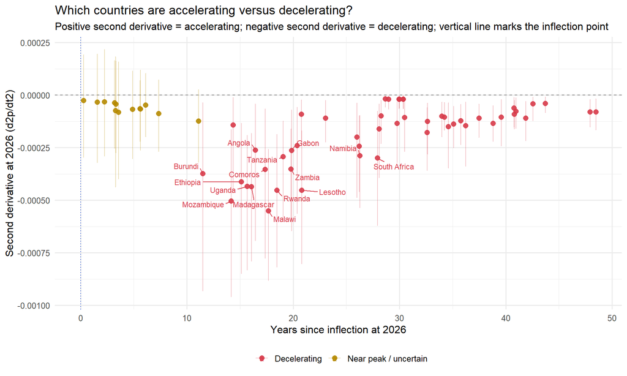

```r
# Visualize acceleration status using years since inflection and the posterior
# mean second derivative at the 2026 decision point.
accel_cols <- c(
  "Accelerating" = "#2DA44E",
  "Near peak / uncertain" = "#B58900",
  "Decelerating" = "#D73A49"
)

acceleration_labels <- acceleration_table %>%
  arrange(desc(abs(d2pdt2_mean))) %>%
  slice_head(n = 15)

ggplot(
  acceleration_plot_data,
  aes(x = years_since_t0_2026, y = d2pdt2_mean, color = accel_status_2026)
) +
  geom_hline(yintercept = 0, linetype = "dashed", color = "grey55", linewidth = 0.5) +
  geom_vline(xintercept = 0, linetype = "dotted", color = "#1D4ED8", linewidth = 0.5) +
  geom_errorbar(aes(ymin = d2pdt2_p05, ymax = d2pdt2_p95), alpha = 0.30, linewidth = 0.45) +
  geom_point(size = 2.4, alpha = 0.90) +
  ggrepel::geom_text_repel(
    data = acceleration_labels,
    aes(label = country),
    size = 3,
    max.overlaps = Inf,
    box.padding = 0.35,
    min.segment.length = 0
  ) +
  scale_color_manual(values = accel_cols) +
  theme_minimal(base_size = 12) +
  theme(legend.position = "bottom", legend.title = element_blank()) +
  labs(
    title = "Which countries are accelerating versus decelerating?",
    subtitle = "Positive second derivative = accelerating; negative second derivative = decelerating; vertical line marks the inflection point",
    x = "Years since inflection at 2026",
    y = "Second derivative at 2026 (d2p/dt2)"
  )
```